# 每个程序员都应该了解的内存知识

##### 多线程访问

##### Multi Threaded Access

为了确保人们理解在不同处理器上并发使用相同缓存行所引入问题的严重性，我们在这里再看一些我们之前用过的同一程序的性能图。不过这一次，同时运行着不止一个线程。所测量的是所有线程中最快的运行时间。这意味着所有线程都完成时一次完整运行的时间还要更长。所使用的机器有四个处理器；测试最多使用四个线程。所有处理器共享一条通往内存控制器的总线，并且通往内存模块的总线也只有一条。

To ensure that the gravity of the problems introduced by concurrently using the same cache lines on different processors is understood, we will look here at some more performance graphs for the same program we used before. This time, though, more than one thread is running at the same time. What is measured is the fastest runtime of any of the threads. This means the time for a complete run when all threads are done is even higher. The machine used has four processors; the tests use up to four threads. All processors share one bus to the memory controller and there is only one bus to the memory modules.

图3.19显示了128字节条目（在64位机器上NPAD=15）顺序只读访问的性能。对于单线程的曲线，我们可以预期得到一条与图3.11相似的曲线。测量是在另一台机器上进行的，因此实际数字有所不同。

Figure 3.19 shows the performance for sequential read-only access for 128 bytes entries (NPAD=15 on 64-bit machines). For the curve for one thread we can expect a curve similar to Figure 3.11. The measurements are for a different machine so the actual numbers vary.

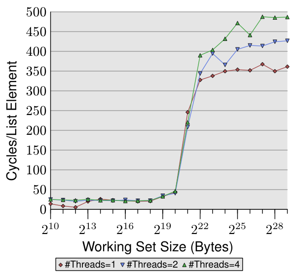

图3.19：顺序读访问，多线程  
Figure 3.19: Sequential Read Access, Multiple Threads

这张图中重要的部分当然是运行多个线程时的行为。注意，在遍历链表时没有修改任何内存，也没有尝试让线程保持同步。尽管不需要RFO消息，并且所有缓存行都可以共享，我们仍然看到，使用两个线程时最快线程的性能下降多达18%，使用四个线程时下降多达34%。由于不需要在处理器之间传输缓存行，这种变慢完全是由两个瓶颈中的一个或两个造成的：从处理器到内存控制器的共享总线，以及从内存控制器到内存模块的总线。一旦工作集大小超过这台机器的L3缓存，所有三个线程都将预取新的链表元素。即使只有两个线程，可用带宽也不足以线性扩展（即运行多个线程时没有损失）。

The important part in this figure is of course the behavior when running multiple threads. Note that no memory is modified and no attempts are made to keep the threads in sync when walking the linked list. Even though no RFO messages are necessary and all the cache lines can be shared, we see up to an 18% performance decrease for the fastest thread when two threads are used and up to 34% when four threads are used. Since no cache lines have to be transported between the processors this slowdown is solely caused by the one or both of the two bottlenecks: the shared bus from the processor to the memory controller and bus from the memory controller to the memory modules. Once the working set size is larger than the L3 cache in this machine all three threads will be prefetching new list elements. Even with two threads the available bandwidth is not sufficient to scale linearly (i.e., have no penalty from running multiple threads).

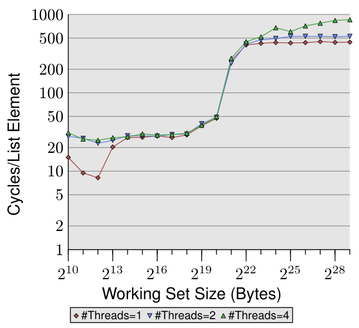

图3.20：顺序加一，多线程  
Figure 3.20: Sequential Increment, Multiple Threads

当我们修改内存时，情况变得更加糟糕。图3.20显示了顺序Increment测试的结果。这张图对Y轴使用了对数刻度。所以，不要被看似很小的差异所迷惑。运行两个线程我们仍有大约18%的损失，而现在运行四个线程的损失竟高达93%。这意味着当使用四个线程时，预取流量加上回写流量几乎使总线饱和了。

When we modify memory things get even uglier. Figure 3.20 shows the results for the sequential Increment test. This graph is using a logarithmic scale for the Y axis. So, do not be fooled by the apparently small differences. We still have about a 18% penalty for running two threads and now an amazing 93% penalty for running four threads. This means the prefetch traffic together with the write-back traffic is pretty much saturating the bus when four threads are used.

我们使用对数刻度来展示L1d范围的结果。可以看到，一旦运行不止一个线程，L1d基本上就失效了。只有当L1d不足以容纳工作集时，单线程的访问时间才会超过20个周期。而在运行多个线程时，即使是最小的工作集大小，也会立即达到这样的访问时间。

We use the logarithmic scale to show the results for the L1d range. What can be seen is that, as soon as more than one thread is running, the L1d is basically ineffective. The single-thread access times exceed 20 cycles only when the L1d is not sufficient to hold the working set. When multiple threads are running, those access times are hit immediately, even with the smallest working set sizes.

问题的一个方面在这里没有显示出来。用这个特定的测试程序很难测量它。即使测试修改了内存，因而我们必然会预期有RFO消息，我们在使用不止一个线程时也没有看到L2范围的代价更高。程序将不得不使用大量内存，并且所有线程必须并行访问同一内存。如果没有大量同步，这很难实现，而同步本身又会主导执行时间。

One aspect of the problem is not shown here. It is hard to measure with this specific test program. Even though the test modifies memory and we therefore must expect RFO messages we do not see higher costs for the L2 range when more than one thread is used. The program would have to use a large amount of memory and all threads must access the same memory in parallel. This is hard to achieve without a lot of synchronization which would then dominate the execution time.

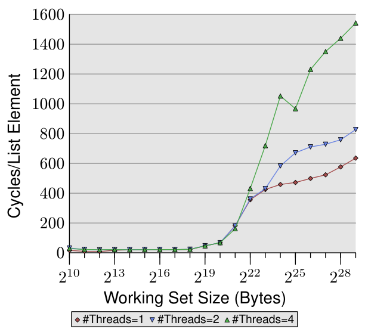

图3.21：随机Addnextlast，多线程  
Figure 3.21: Random Addnextlast, Multiple Threads

最后，在图3.21中我们给出了随机访问内存的Addnextlast测试的数字。提供这张图主要是为了展示那些高得骇人的数字。在极端情况下，现在处理单个链表元素需要大约1,500个周期。使用更多的线程就更成问题了。我们可以用一张表来总结多线程使用的效率。

Finally in Figure 3.21 we have the numbers for the Addnextlast test with random access of memory. This figure is provided mainly to show the appallingly high numbers. It now takes around 1,500 cycles to process a single list element in the extreme case. The use of more threads is even more questionable. We can summarize the efficiency of multiple thread use in a table.

| #线程数 #Threads | 顺序读 Seq Read | 顺序加一 Seq Inc | 随机加 Rand Add |
| --- | --- | --- | --- |
| 2 | 1.69 | 1.69 | 1.54 |
| 4 | 2.98 | 2.07 | 1.65 |

表3.3：多线程的效率  
Table 3.3: Efficiency for Multiple Threads

该表显示了在第28页三张图中最大工作集大小下多线程运行的效率。这个数字表示测试程序在最大工作集大小下使用两个或四个线程所能获得的最佳加速比。对于两个线程，加速比的理论极限是2；对于四个线程是4。两个线程的数字还不算太差。但对于四个线程，最后一项测试的数字表明，扩展到两个线程以上几乎是不值得的。额外的收益微乎其微。如果我们稍微换一种方式表示图3.21中的数据，就能更容易地看出这一点。

The table shows the efficiency for the multi-thread run with the largest working set size in the three figures on page 28. The number shows the best possible speed-up the test program incurs for the largest working set size by using two or four threads. For two threads the theoretical limits for the speed-up are 2 and, for four threads, 4. The numbers for two threads are not that bad. But for four threads the numbers for the last test show that it is almost not worth it to scale beyond two threads. The additional benefit is minuscule. We can see this more easily if we represent the data in Figure 3.21 a bit differently.

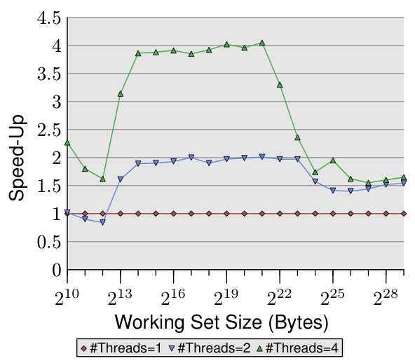

图3.22：并行带来的加速  
Figure 3.22: Speed-Up Through Parallelism

图3.22中的曲线显示了加速比，即与单线程执行代码相比的相对性能。我们必须忽略最小的那些大小，那些测量不够准确。对于L2和L3缓存的范围，我们可以看到我们确实实现了几乎线性的加速。我们几乎分别达到了2和4的倍数。但一旦L3缓存不足以容纳工作集，数字就崩溃了。它们崩溃到两个线程和四个线程的加速比相同的程度（见表3.3的第四列）。这就是为什么人们几乎找不到带有四个以上CPU插槽、且全都使用同一内存控制器的主板的原因之一。拥有更多处理器的机器必须以不同的方式构建（见第5节）。

The curves in Figure 3.22 show the speed-up factors, i.e., relative performance compared to the code executed by a single thread. We have to ignore the smallest sizes, the measurements are not accurate enough. For the range of the L2 and L3 cache we can see that we indeed achieve almost linear acceleration. We almost reach factors of 2 and 4 respectively. But as soon as the L3 cache is not sufficient to hold the working set the numbers crash. They crash to the point that the speed-up of two and four threads is identical (see the fourth column in Table 3.3). This is one of the reasons why one can hardly find motherboard with sockets for more than four CPUs all using the same memory controller. Machines with more processors have to be built differently (see section 5).

这些数字并不是普遍适用的。在某些情况下，即使是能放进最后一级缓存的工作集也无法实现线性加速。事实上，这才是常态，因为线程通常不像这个测试程序中那样彼此解耦。另一方面，处理大型工作集并仍然利用两个以上线程是可能的。不过，这需要深思熟虑。我们将在第6节中讨论一些方法。

These numbers are not universal. In some cases even working sets which fit into the last level cache will not allow linear speed-ups. In fact, this is the norm since threads are usually not as decoupled as is the case in this test program. On the other hand it is possible to work with large working sets and still take advantage of more than two threads. Doing this requires thought, though. We will talk about some approaches in section 6.

##### 特殊情况：超线程

##### Special Case: Hyper-Threads

超线程（有时称为对称多线程，SMT）由CPU实现，是一种特殊情况，因为各个线程不能真正地并发运行。它们共享除寄存器组之外几乎所有的处理资源。各个内核和CPU仍然并行工作，但在每个内核上实现的线程受到这一限制。理论上每个内核可以有许多线程，但到目前为止，Intel的CPU每个内核最多有两个线程。CPU负责对线程进行时分复用。不过，仅此一点意义不大。真正的优势在于，当当前运行的超线程被延迟时，CPU可以调度另一个超线程，并利用算术逻辑单元（ALU）等可用资源。在大多数情况下，这种延迟是由内存访问引起的。

Hyper-Threads (sometimes called Symmetric Multi-Threading, SMT) are implemented by the CPU and are a special case since the individual threads cannot really run concurrently. They all share almost all the processing resources except for the register set. Individual cores and CPUs still work in parallel but the threads implemented on each core are limited by this restriction. In theory there can be many threads per core but, so far, Intel’s CPUs at most have two threads per core. The CPU is responsible for time-multiplexing the threads. This alone would not make much sense, though. The real advantage is that the CPU can schedule another hyper-thread and take advantage of available resources such as arithmetic logic units (ALUs) when the currently running hyper-thread is delayed. In most cases this is a delay caused by memory accesses.

如果两个线程在一个超线程内核上运行，那么只有当两个线程的总运行时间低于单线程代码的运行时间时，程序才比单线程代码更高效。通过重叠不同内存访问的等待时间（这些访问通常会顺序发生），这是可能的。一个简单的计算可以显示要达到一定的加速比对缓存命中率的最低要求。

If two threads are running on one hyper-threaded core the program is only more efficient than the single-threaded code if the combined runtime of both threads is lower than the runtime of the single-threaded code. This is possible by overlapping the wait times for different memory accesses which usually would happen sequentially. A simple calculation shows the minimum requirement on the cache hit rate to achieve a certain speed-up.

程序的执行时间可以用一个只有一级缓存的简单模型来近似，如下所示（见[16]）：

The execution time for a program can be approximated with a simple model with only one level of cache as follows (see [16]):

$$Texe=N[(1−Fmem)Tproc+Fmem(GhitTcache+(1−Ghit)Tmiss)]$$

各变量的含义如下：

The meaning of the variables is as follows:

| *N* | = | 指令数。 Number of instructions. |
| --- | --- | --- |
| *F*<sub>mem</sub> | = | *N*中访问内存的比例。 Fraction of *N* that access memory. |
| *G*<sub>hit</sub> | = | 命中缓存的加载所占比例。 Fraction of loads that hit the cache. |
| *T*<sub>proc</sub> | = | 每条指令的周期数。 Number of cycles per instruction. |
| *T*<sub>cache</sub> | = | 缓存命中的周期数。 Number of cycles for cache hit. |
| *T*<sub>miss</sub> | = | 缓存未命中的周期数。 Number of cycles for cache miss. |
| *T*<sub>exe</sub> | = | 程序的执行时间。 Execution time for program. |

要使使用两个线程有意义，两个线程中每一个的执行时间都必须至多是单线程代码的一半。等式两边唯一的变量是缓存命中次数。如果我们求解该方程，得到为了不使线程执行慢50%或更多所需的最低缓存命中率，就得到了图3.23中的图。

For it to make any sense to use two threads the execution time of each of the two threads must be at most half of that of the single-threaded code. The only variable on either side is the number of cache hits. If we solve the equation for the minimum cache hit rate required to not slow down the thread execution by 50% or more we get the graph in Figure 3.23.

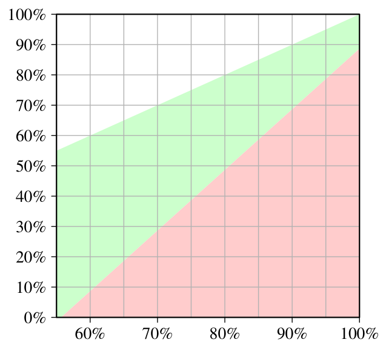

图3.23：获得加速所需的最低缓存命中率  
Figure 3.23: Minimum Cache Hit Rate For Speed-Up  
X轴：单线程命中率；Y轴：多线程所需命中率。绿色区域为目标区域。

在X轴上测量的输入是单线程代码的缓存命中率*G*<sub>hit</sub>。Y轴显示多线程代码的缓存命中率。这个值永远不可能高于单线程的命中率，否则单线程代码也会使用那种改进后的代码。对于单线程命中率——在这个特定情况下——低于55%的情况，程序在所有情况下都可以从使用线程中获益。由于缓存未命中，CPU或多或少足够空闲，可以运行第二个超线程。

The input, measured on the X–axis, is the cache hit rate *G*<sub>hit</sub> of the single-thread code. The Y–axis shows the cache hit rate for the multi-threaded code. This value can never be higher than the single-threaded hit rate since, otherwise, the single-threaded code would use that improved code, too. For single-threaded hit rates–in this specific case–below 55% the program can in all cases benefit from using threads. The CPU is more or less idle enough due to cache misses to enable running a second hyper-thread.

绿色区域是目标。如果线程的变慢小于50%，并且每个线程的工作量减半，那么总运行时间可能少于单线程的运行时间。对于所建模的处理器（使用的是带超线程的P4的数字），单线程代码命中率为60%的程序，要求双线程程序的命中率至少为10%。这通常是可以做到的。但如果单线程代码的命中率为95%，那么多线程代码需要至少80%的命中率。这就比较难了。尤其是——这正是超线程的问题所在——因为现在每个超线程可用的有效缓存大小（这里是L1d，在实践中也包括L2等）被减半了。两个超线程使用同一个缓存来加载它们的数据。如果两个线程的工作集不重叠，原来95%的命中率也可能被减半，因而远低于所要求的80%。

The green area is the target. If the slowdown for the thread is less than 50% and the workload of each thread is halved the combined runtime might be less than the single-thread runtime. For the modeled processor (numbers for a P4 with hyper-threads were used) a program with a hit rate of 60% for the single-threaded code requires a hit rate of at least 10% for the dual-threaded program. That is usually doable. But if the single-threaded code has a hit rate of 95% then the multi-threaded code needs a hit rate of at least 80%. That is harder. Especially, and this is the problem with hyper-threads, because now the effective cache size (L1d here, in practice also L2 and so on) available to each hyper-thread is cut in half. Both hyper-threads use the same cache to load their data. If the working set of the two threads is non-overlapping the original 95% hit rate could also be cut in half and is therefore much lower than the required 80%.

因此，超线程只在有限的情况下才有用。单线程代码的缓存命中率必须足够低，以便在给定上述方程以及缩小的缓存大小时，新的命中率仍能达到目标。只有在那时，使用超线程才可能有意义。结果在实践中是否更快，取决于处理器能否充分地把一个线程中的等待时间与其他线程中的执行时间重叠起来。并行化代码的开销必须加到新的总运行时间中，而这一额外代价往往不可忽略。

Hyper-threads are therefore only useful in a limited range of situations. The cache hit rate of the single-threaded code must be low enough that given the equations above and reduced cache size the new hit rate still meets the goal. Then and only then can it make any sense at all to use hyper-threads. Whether the result is faster in practice depends on whether the processor is sufficiently able to overlap the wait times in one thread with execution times in the other threads. The overhead of parallelizing the code must be added to the new total runtime and this additional cost often cannot be neglected.

在6.3.4节中我们将看到一种技术，其中线程紧密协作，通过共同缓存实现的紧密耦合实际上是一种优势。只要程序员愿意投入时间和精力来扩展他们的代码，这种技术就可以适用于许多情况。

In section 6.3.4 we will see a technique where threads collaborate closely and the tight coupling through the common cache is actually an advantage. This technique can be applicable to many situations if only the programmers are willing to put in the time and energy to extend their code.

应当清楚的是，如果两个超线程执行完全不同的代码（即这两个线程被操作系统当作独立的处理器来执行独立的进程），缓存大小确实会减半，这意味着缓存未命中显著增加。除非缓存足够大，否则这种操作系统调度做法是有问题的。除非机器的工作负载由那些从设计上确实能从超线程中获益的进程组成，否则最好在计算机的BIOS中关闭超线程。<sup>23</sup>

What should be clear is that if the two hyper-threads execute completely different code (i.e., the two threads are treated like separate processors by the OS to execute separate processes) the cache size is indeed cut in half which means a significant increase in cache misses. Such OS scheduling practices are questionable unless the caches are sufficiently large. Unless the workload for the machine consists of processes which, through their design, can indeed benefit from hyper-threads it might be best to turn off hyper-threads in the computer’s BIOS.<sup>23</sup>

#### 3.3.5 其他细节

#### 3.3.5 Other Details

到目前为止，我们一直把地址说成由三部分组成：标记、组索引和缓存行偏移。但实际使用的是什么地址呢？如今所有相关的处理器都为进程提供虚拟地址空间，这意味着有两种不同的地址：虚拟地址和物理地址。

So far we talked about the address as consisting of three parts, tag, set index, and cache line offset. But what address is actually used? All relevant processors today provide virtual address spaces to processes, which means that there are two different kinds of addresses: virtual and physical.

虚拟地址的问题在于它们不是唯一的。一个虚拟地址可以随着时间推移指向不同的物理内存地址。不同进程中的同一地址很可能也指向不同的物理地址。所以使用物理内存地址总是更好的，对吧？

The problem with virtual addresses is that they are not unique. A virtual address can, over time, refer to different physical memory addresses. The same address in different processes also likely refers to different physical addresses. So it is always better to use the physical memory address, right?

这里的问题在于执行期间使用的虚拟地址，它们必须借助内存管理单元（MMU）转换为物理地址。这是一个不简单的操作。在执行一条指令的流水线中，物理地址可能只有在较晚的阶段才可用。这意味着缓存逻辑必须非常迅速地确定该内存位置是否已被缓存。如果可以使用虚拟地址，缓存查找就可以在流水线中早得多的阶段进行，并且在缓存命中的情况下就可以提供内存内容。结果是更多的内存访问代价可以被流水线隐藏。

The problem here are the virtual addresses used during execution which must to be translated with the help of the Memory Management Unit (MMU) into physical addresses. This is a non-trivial operation. In the pipeline to execute an instruction the physical address might only be available at a later stage. This means that the cache logic has to be very quick in determining whether the memory location is cached. If virtual addresses could be used the cache lookup can happen much earlier in the pipeline and in case of a cache hit the memory content can be made available. The result is that more of the memory access costs could be hidden by the pipeline.

处理器设计者目前对第一级缓存使用虚拟地址标记。这些缓存相当小，清除它们不会带来太多痛苦。如果一个进程的页表树发生变化，至少需要部分清除缓存。如果处理器有一条能够指定已变化的虚拟地址范围的指令，也许可以避免完全刷新。鉴于L1i和L1d缓存的延迟很低（约3个周期），使用虚拟地址几乎是必须的。

Processor designers are currently using virtual address tagging for the first level caches. These caches are rather small and can be cleared without too much pain. At least partial clearing the cache is necessary if the page table tree of a process changes. It might be possible to avoid a complete flush if the processor has an instruction which allows to specify the virtual address range which has changed. Given the low latency of L1i and L1d caches (~3 cycles) using virtual addresses is almost mandatory.

对于包括L2、L3……在内的更大的缓存，需要使用物理地址标记。这些缓存的延迟更高，虚拟→物理地址转换可以及时完成。由于这些缓存更大（即刷新时会丢失大量信息），并且由于主存访问延迟，重新填充它们需要很长时间，频繁刷新它们的代价将很高。

For larger caches including L2, L3, . . . caches physical address tagging is needed. These caches have a higher latency and the virtual→physical address translation can finish in time. Because these caches are larger (i.e., a lot of information is lost when they are flushed) and refilling them takes a long time due to the main memory access latency, flushing them often would be costly.

一般来说，没有必要了解这些缓存中地址处理的细节。它们是不能改变的，而所有会影响性能的因素通常要么是应当避免的，要么是与高昂代价相关联的。溢出缓存容量是不好的，而且如果所使用的大多数缓存行都落入同一个组，所有缓存都会很早就遇到问题。后者对于虚拟寻址的缓存是可以避免的，但对于使用物理地址寻址的缓存，用户级进程是不可能避免的。人们或许应该记住的唯一细节是：如果可能的话，不要在同一个进程中把同一个物理内存位置映射到两个或更多的虚拟地址。

It should, in general, not be necessary to know about the details of the address handling in those caches. They cannot be changed and all the factors which would influence the performance are normally something which should be avoided or is associated with high cost. Overflowing the cache capacity is bad and all caches run into problems early if the majority of the used cache lines fall into the same set. The latter can be avoided with virtually addressed caches but is impossible for user-level processes to avoid for caches addressed using physical addresses. The only detail one might want to keep in mind is to not map the same physical memory location to two or more virtual addresses in the same process, if at all possible.

缓存的另一个对程序员来说相当无趣的细节是缓存替换策略。大多数缓存首先逐出最近最少使用（LRU）的元素。这总是一个很好的默认策略。随着相联度增大（而且由于更多内核的加入，相联度在未来几年确实可能进一步增长），维护LRU列表变得越来越昂贵，我们可能会看到采用不同的策略。

Another detail of the caches which is rather uninteresting to programmers is the cache replacement strategy. Most caches evict the Least Recently Used (LRU) element first. This is always a good default strategy. With larger associativity (and associativity might indeed grow further in the coming years due to the addition of more cores) maintaining the LRU list becomes more and more expensive and we might see different strategies adopted.

至于缓存替换，程序员能做的不多。如果缓存使用物理地址标记，就无法找出虚拟地址与缓存组之间的对应关系。可能所有逻辑页中的缓存行都映射到相同的缓存组，使得大部分缓存未被使用。如果说有什么的话，确保这种情况不要太频繁发生是操作系统的工作。

As for the cache replacement there is not much a programmer can do. If the cache is using physical address tags there is no way to find out how the virtual addresses correlate with the cache sets. It might be that cache lines in all logical pages are mapped to the same cache sets, leaving much of the cache unused. If anything, it is the job of the OS to arrange that this does not happen too often.

随着虚拟化的出现，情况变得更加复杂。现在甚至操作系统也无法控制物理内存的分配。虚拟机监视器（VMM，又称Hypervisor）负责物理内存的分配。

With the advent of virtualization things get even more complicated. Now not even the OS has control over the assignment of physical memory. The Virtual Machine Monitor (VMM, aka Hypervisor) is responsible for the physical memory assignment.

程序员所能做的最好的事情是：a）完整地使用逻辑内存页；b）使用尽可能大的有意义的页大小，以尽可能地分散物理地址。更大的页大小还有其他好处，但那是另一个话题（见第4节）。

The best a programmer can do is to a) use logical memory pages completely and b) use page sizes as large as meaningful to diversify the physical addresses as much as possible. Larger page sizes have other benefits, too, but this is another topic (see section 4).

### 3.4 指令缓存

### 3.4 Instruction Cache

被缓存的不仅仅是处理器使用的数据；处理器执行的指令也会被缓存。不过，这种缓存比数据缓存的问题少得多。原因有以下几个：

Not just the data used by the processor is cached; the instructions executed by the processor are also cached. However, this cache is much less problematic than the data cache. There are several reasons:

- 被执行的代码量取决于所需代码的大小。代码的大小一般取决于问题的复杂度。问题的复杂度是固定的。

  The quantity of code which is executed depends on the size of the code that is needed. The size of the code in general depends on the complexity of the problem. The complexity of the problem is fixed.
- 程序的数据处理是由程序员设计的，而程序的指令通常是由编译器生成的。编译器的编写者了解良好代码生成的规则。

  While the program’s data handling is designed by the programmer the program’s instructions are usually generated by a compiler. The compiler writers know about the rules for good code generation.
- 程序流程比数据访问模式可预测得多。如今的CPU非常擅长检测模式。这有助于预取。

  Program flow is much more predictable than data access patterns. Today’s CPUs are very good at detecting patterns. This helps with prefetching.
- 代码总是具有相当好的空间局部性和时间局部性。

  Code always has quite good spatial and temporal locality.

程序员应该遵循一些规则，但这些规则主要是关于如何使用工具的。我们将在第6节中讨论它们。这里我们只讨论指令缓存的技术细节。

There are a few rules programmers should follow but these mainly consist of rules on how to use the tools. We will discuss them in section 6. Here we talk only about the technical details of the instruction cache.

自从CPU的内核时钟大幅提高、缓存（即使是第一级缓存）与内核之间的速度差距扩大以来，CPU就采用流水线设计。这意味着一条指令的执行是分阶段进行的。首先对指令解码，然后准备参数，最后执行它。这样的流水线可能相当长（对于Intel的Netburst架构，超过20级）。长流水线意味着如果流水线停顿（即流经其中的指令流被中断），需要一段时间才能重新恢复速度。例如，如果无法正确预测下一条指令的位置，或者加载下一条指令花费的时间太长（例如必须从内存中读取时），就会发生流水线停顿。

Ever since the core clock of CPUs increased dramatically and the difference in speed between cache (even first level cache) and core grew, CPUs have been designed with pipelines. That means the execution of an instruction happens in stages. First an instruction is decoded, then the parameters are prepared, and finally it is executed. Such a pipeline can be quite long (> 20 stages for Intel’s Netburst architecture). A long pipeline means that if the pipeline stalls (i.e., the instruction flow through it is interrupted) it takes a while to get up to speed again. Pipeline stalls happen, for instance, if the location of the next instruction cannot be correctly predicted or if it takes too long to load the next instruction (e.g., when it has to be read from memory).

因此，CPU设计者在分支预测上花费了大量的时间和芯片面积，以使流水线停顿尽可能少地发生。

As a result CPU designers spend a lot of time and chip real estate on branch prediction so that pipeline stalls happen as infrequently as possible.

在CISC处理器上，解码阶段也可能需要一些时间。x86和x86-64处理器尤其受到影响。因此近年来，这些处理器不在L1i中缓存指令的原始字节序列，而是缓存解码后的指令。在这种情况下，L1i被称为“踪迹缓存”（trace cache）。在缓存命中的情况下，踪迹缓存使处理器能够跳过流水线的最初几个步骤，这在流水线停顿时尤其有益。

On CISC processors the decoding stage can also take some time. The x86 and x86-64 processors are especially affected. In recent years these processors therefore do not cache the raw byte sequence of the instructions in L1i but instead they cache the decoded instructions. L1i in this case is called the “trace cache”. Trace caching allows the processor to skip over the first steps of the pipeline in case of a cache hit which is especially good if the pipeline stalled.

如前所述，从L2开始的缓存是同时包含代码和数据的统一缓存。显然，在这里代码以字节序列的形式缓存，而不是以解码后的形式。

As said before, the caches from L2 on are unified caches which contain both code and data. Obviously here the code is cached in the byte sequence form and not decoded.

为了获得最佳性能，与指令缓存相关的规则只有几条：

To achieve the best performance there are only a few rules related to the instruction cache:

1. 生成尽可能小的代码。也有例外情况：为了利用流水线而进行软件流水线时需要生成更多代码，或者使用小代码的开销太高。

   Generate code which is as small as possible. There are exceptions when software pipelining for the sake of using pipelines requires creating more code or where the overhead of using small code is too high.
2. 帮助处理器作出良好的预取决策。这可以通过代码布局或显式预取来实现。

   Help the processor making good prefetching decisions. This can be done through code layout or with explicit prefetching.

这些规则通常由编译器的代码生成来执行。程序员可以做的事情有一些，我们将在第6节中讨论。

These rules are usually enforced by the code generation of a compiler. There are a few things the programmer can do and we will talk about them in section 6.

#### 3.4.1 自修改代码

#### 3.4.1 Self Modifying Code

在计算机的早期，内存非常珍贵。人们想尽办法减小程序的大小，以便为程序数据腾出更多空间。一个常用的技巧是让程序随时间修改自身。这种自修改代码（SMC）偶尔仍能见到，如今大多是出于性能原因，或出现在安全漏洞利用中。

In early computer days memory was a premium. People went to great lengths to reduce the size of the program to make more room for program data. One trick frequently deployed was to change the program itself over time. Such Self Modifying Code (SMC) is occasionally still found, these days mostly for performance reasons or in security exploits.

一般来说应当避免SMC。尽管它通常能被正确执行，但存在不能正确执行的边界情况，而且如果做得不正确会造成性能问题。显然，被修改的代码不能保存在包含解码后指令的踪迹缓存中。但即使因为代码根本还没被执行过（或已有一段时间没被执行）而没有使用踪迹缓存，处理器也可能遇到问题。如果一条即将执行的指令在已经进入流水线后被修改，处理器就不得不丢弃大量工作并从头开始。甚至在某些情况下，处理器的大部分状态都必须被丢弃。

SMC should in general be avoided. Though it is generally correctly executed there are boundary cases which are not and it creates performance problems if not done correctly. Obviously, code which is changed cannot be kept in the trace cache which contains the decoded instructions. But even if the trace cache is not used because the code has not been executed at all (or for some time) the processor might have problems. If an upcoming instruction is changed while it already entered the pipeline the processor has to throw away a lot of work and start all over again. There are even situations where most of the state of the processor has to be tossed away.

最后，由于处理器假定——出于简化的原因，也因为在99.9999999%的情况下都是如此——代码页是不可变的，L1i的实现不使用MESI协议，而是使用一种简化的SI协议。这意味着如果检测到修改，就必须作出大量悲观的假设。

Finally, since the processor assumes–for simplicity reasons and because it is true in 99.9999999% of all cases–that the code pages are immutable, the L1i implementation does not use the MESI protocol but instead a simplified SI protocol. This means if modifications are detected a lot of pessimistic assumptions have to be made.

强烈建议尽可能避免SMC。内存已不再是那么稀缺的资源了。编写独立的函数，比根据特定需要修改一个函数要好。也许有一天，对SMC的支持可以成为可选的，我们就能检测出试图以这种方式修改代码的漏洞利用代码。如果绝对必须使用SMC，写操作应当绕过缓存，以免L1i中需要的数据在L1d中造成问题。关于这些指令的更多信息，见6.1节。

It is highly advised to avoid SMC whenever possible. Memory is not such a scarce resource anymore. It is better to write separate functions instead of modifying one function according to specific needs. Maybe one day SMC support can be made optional and we can detect exploit code trying to modify code this way. If SMC absolutely has to be used, the write operations should bypass the cache as to not create problems with data in L1d needed in L1i. See section 6.1 for more information on these instructions.

在Linux上，识别包含SMC的程序通常相当容易。用常规工具链构建时，所有程序代码都是写保护的。程序员必须在链接时施展相当的魔法，才能创建代码页可写的可执行文件。当这种情况发生时，现代Intel x86和x86-64处理器有专门的性能计数器来统计自修改代码的使用次数。借助这些计数器，即使程序由于权限放宽而能够成功运行，也很容易识别出带有SMC的程序。

On Linux it is normally quite easy to recognize programs which contain SMC. All program code is write-protected when built with the regular toolchain. The programmer has to perform significant magic at link time to create an executable where the code pages are writable. When this happens, modern Intel x86 and x86-64 processors have dedicated performance counters which count uses of self-modifying code. With the help of these counters it is quite easily possible to recognize programs with SMC even if the program will succeed due to relaxed permissions.

### 3.5 缓存未命中因素

### 3.5 Cache Miss Factors

我们已经看到，当内存访问未命中缓存时，代价会急剧上升。有时这是无法避免的，重要的是了解实际的代价以及可以做些什么来缓解这个问题。

We have already seen that when memory accesses miss the caches the costs skyrocket. Sometimes this is not avoidable and it is important to understand the actual costs and what can be done to mitigate the problem.

#### 3.5.1 缓存与内存带宽

#### 3.5.1 Cache and Memory Bandwidth

为了更好地了解处理器的能力，我们测量在最佳情况下的可用带宽。这一测量特别有意思，因为不同处理器版本之间差异很大。这就是为什么本节充满了几台不同机器的数据。测量性能的程序使用x86和x86-64处理器的SSE指令一次加载或存储16字节。与我们的其他测试一样，工作集从1kB增加到512MB，并测量每个周期能加载或存储多少字节。

To get a better understanding of the capabilities of the processors we measure the bandwidth available in optimal circumstances. This measurement is especially interesting since different processor versions vary widely. This is why this section is filled with the data of several different machines. The program to measure performance uses the SSE instructions of the x86 and x86-64 processors to load or store 16 bytes at once. The working set is increased from 1kB to 512MB just as in our other tests and it is measured how many bytes per cycle can be loaded or stored.

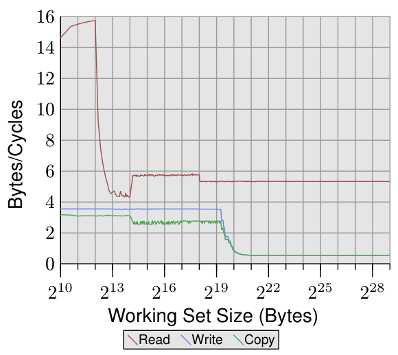

图3.24：Pentium 4带宽  
Figure 3.24: Pentium 4 Bandwidth  
Read=读，Write=写，Copy=复制。

图3.24显示了64位Intel Netburst处理器上的性能。对于能放进L1d的工作集大小，处理器能够每个周期读取完整的16字节，即每个周期执行一条加载指令（`movaps`指令一次移动16字节）。测试对读取的数据不做任何处理，我们只测试读指令本身。一旦L1d不够用了，性能就急剧下降到每周期不到6字节。2<sup>18</sup>字节处的台阶是由于DTLB缓存耗尽，这意味着每个新页面都需要额外的工作。由于读取是顺序的，预取可以完美地预测访问，并且对于所有大小的工作集，FSB都能以每周期约5.3字节的速度流式传输内存内容。不过，预取的数据不会被传播到L1d中。当然，在真实程序中这些数字是永远无法达到的。可以把它们看作实际的极限。

Figure 3.24 shows the performance on a 64-bit Intel Netburst processor. For working set sizes which fit into L1d the processor is able to read the full 16 bytes per cycle, i.e., one load instruction is performed per cycle (the `movaps` instruction moves 16 bytes at once). The test does not do anything with the read data, we test only the read instructions themselves. As soon as the L1d is not sufficient anymore the performance goes down dramatically to less than 6 bytes per cycle. The step at 2<sup>18</sup> bytes is due to the exhaustion of the DTLB cache which means additional work for each new page. Since the reading is sequential prefetching can predict the accesses perfectly and the FSB can stream the memory content at about 5.3 bytes per cycle for all sizes of the working set. The prefetched data is not propagated into L1d, though. These are of course numbers which will never be achievable in a real program. Think of them as practical limits.

比读性能更令人吃惊的是写和复制的性能。写性能即使在很小的工作集大小下也从未超过每周期4字节。这表明，在这些Netburst处理器中，Intel选择对L1d使用直写模式，其性能显然受限于L2的速度。这也意味着复制测试（从一个内存区域复制到另一个不重叠的内存区域）的性能并没有显著变差。所需的读操作要快得多，并且可以与写操作部分重叠。写和复制测量中最值得注意的细节是，一旦L2缓存不够用了，性能就变得很低。性能下降到每周期0.5字节！这意味着写操作比读操作慢十倍。这意味着优化这些操作对程序的性能更加重要。

What is more astonishing than the read performance is the write and copy performance. The write performance, even for small working set sizes, does not ever rise above 4 bytes per cycle. This indicates that, in these Netburst processors, Intel elected to use a Write-Through mode for L1d where the performance is obviously limited by the L2 speed. This also means that the performance of the copy test, which copies from one memory region into a second, non-overlapping memory region, is not significantly worse. The necessary read operations are so much faster and can partially overlap with the write operations. The most noteworthy detail of the write and copy measurements is the low performance once the L2 cache is not sufficient anymore. The performance drops to 0.5 bytes per cycle! That means write operations are by a factor of ten slower than the read operations. This means optimizing those operations is even more important for the performance of the program.

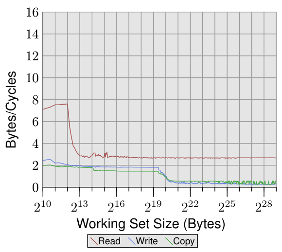

图3.25：P4带宽（2个超线程）  
Figure 3.25: P4 Bandwidth with 2 Hyper-Threads

在图3.25中，我们看到的是同一处理器上的结果，但运行了两个线程，每个线程固定在处理器的两个超线程之一上。该图以与前一张相同的刻度显示以说明差异，曲线有些抖动仅仅是因为测量两个并发线程的问题。结果符合预期。由于超线程共享除寄存器以外的所有资源，每个线程只能获得一半的缓存和带宽。这意味着即使每个线程都要等待很久并且可以把执行时间让给另一个线程，这也没有任何区别，因为另一个线程也必须等待内存。这确实展示了超线程最糟糕的使用方式。

In Figure 3.25 we see the results on the same processor but with two threads running, one pinned to each of the two hyper-threads of the processor. The graph is shown at the same scale as the previous one to illustrate the differences and the curves are a bit jittery simply because of the problem of measuring two concurrent threads. The results are as expected. Since the hyper-threads share all the resources except the registers each thread has only half the cache and bandwidth available. That means even though each thread has to wait a lot and could award the other thread with execution time this does not make any difference since the other thread also has to wait for the memory. This truly shows the worst possible use of hyper-threads.

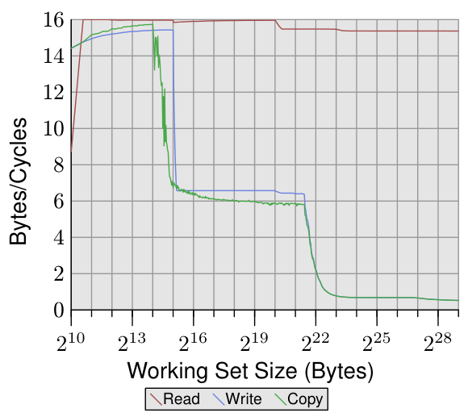

图3.26：Core 2带宽  
Figure 3.26: Core 2 Bandwidth

与图3.24和3.25相比，图3.26和3.27中Intel Core 2处理器的结果看起来大不相同。这是一个共享L2的双核处理器，其L2是P4机器上L2的四倍大。不过，这只能解释写和复制性能下降被推迟的原因。还有其他更大的差异。在整个工作集范围内，读性能都徘徊在最佳的每周期16字节左右。2<sup>20</sup>字节之后读性能的下降同样是由于工作集对DTLB来说太大了。达到如此高的数字意味着处理器不仅能够预取数据并及时传输数据。这还意味着数据被预取到了L1d中。

Compared to Figure 3.24 and 3.25 the results in Figure 3.26 and 3.27 look quite different for an Intel Core 2 processor. This is a dual-core processor with shared L2 which is four times as big as the L2 on the P4 machine. This only explains the delayed drop-off of the write and copy performance, though. There are other, bigger differences. The read performance throughout the working set range hovers around the optimal 16 bytes per cycle. The drop-off in the read performance after 2<sup>20</sup> bytes is again due to the working set being too big for the DTLB. Achieving these high numbers means the processor is not only able to prefetch the data and transport the data in time. It also means the data is prefetched into L1d.

写和复制性能也截然不同。处理器没有采用直写策略；写入的数据存储在L1d中，只在必要时才被逐出。这使得写速度接近最佳的每周期16字节。一旦L1d不够用了，性能就显著下降。与Netburst处理器一样，写性能要低得多。由于读性能很高，这里的差异甚至更大。事实上，当连L2也不够用时，速度差异增大到20倍！这并不意味着Core 2处理器表现不佳。恰恰相反，它们的性能总是优于Netburst内核。

The write and copy performance is dramatically different, too. The processor does not have a Write-Through policy; written data is stored in L1d and only evicted when necessary. This allows for write speeds close to the optimal 16 bytes per cycle. Once L1d is not sufficient anymore the performance drops significantly. As with the Netburst processor, the write performance is significantly lower. Due to the high read performance the difference is even higher here. In fact, when even the L2 is not sufficient anymore the speed difference increases to a factor of 20! This does not mean the Core 2 processors perform poorly. To the contrary, their performance is always better than the Netburst core’s.

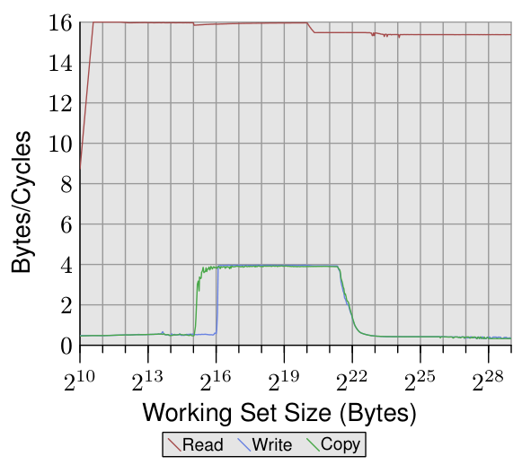

图3.27：Core 2带宽（2个线程）  
Figure 3.27: Core 2 Bandwidth with 2 Threads

在图3.27中，测试运行两个线程，分别在Core 2处理器的两个内核上各一个。两个线程访问同一内存，但不一定完全同步。读性能的结果与单线程情况没有什么不同。可以看到更多的抖动，这在任何多线程测试中都是可以预料的。

In Figure 3.27 the test runs two threads, one on each of the two cores of the Core 2 processor. Both threads access the same memory, not necessarily perfectly in sync, though. The results for the read performance are not different from the single-threaded case. A few more jitters are visible which is to be expected in any multi-threaded test case.

有趣的是对于能放进L1d的工作集大小的写和复制性能。从图中可以看到，性能与数据必须从主存读取时相同。两个线程竞争同一内存位置，必须为缓存行发送RFO消息。问题在于，即使两个内核共享L2缓存，这些请求也不是以L2缓存的速度处理的。一旦L1d缓存不够用，修改过的条目就会从每个内核的L1d刷新到共享的L2中。此时性能显著提高，因为现在L1d未命中由L2缓存满足，只有当数据尚未被刷新时才需要RFO消息。这就是为什么我们在这些工作集大小下看到速度降低了50%。渐近行为符合预期：由于两个内核共享同一FSB，每个内核获得一半的FSB带宽，这意味着对于大工作集，每个线程的性能大约是单线程情况的一半。

The interesting point is the write and copy performance for working set sizes which would fit into L1d. As can be seen in the figure, the performance is the same as if the data had to be read from the main memory. Both threads compete for the same memory location and RFO messages for the cache lines have to be sent. The problematic point is that these requests are not handled at the speed of the L2 cache, even though both cores share the cache. Once the L1d cache is not sufficient anymore modified entries are flushed from each core’s L1d into the shared L2. At that point the performance increases significantly since now the L1d misses are satisfied by the L2 cache and RFO messages are only needed when the data has not yet been flushed. This is why we see a 50% reduction in speed for these sizes of the working set. The asymptotic behavior is as expected: since both cores share the same FSB each core gets half the FSB bandwidth which means for large working sets each thread’s performance is about half that of the single threaded case.

由于即使在同一厂商的不同处理器版本之间也存在显著差异，看一看其他厂商处理器的性能当然也是值得的。图3.28显示了AMD family 10h Opteron处理器的性能。该处理器有64kB L1d、512kB L2和2MB的L3。L3缓存由处理器的所有内核共享。性能测试的结果可以在图3.28中看到。

Because there are significant differences even between the processor versions of one vendor it is certainly worthwhile looking at the performance of other vendors’ processors, too. Figure 3.28 shows the performance of an AMD family 10h Opteron processor. This processor has 64kB L1d, 512kB L2, and 2MB of L3. The L3 cache is shared between all cores of the processor. The results of the performance test can be seen in Figure 3.28.

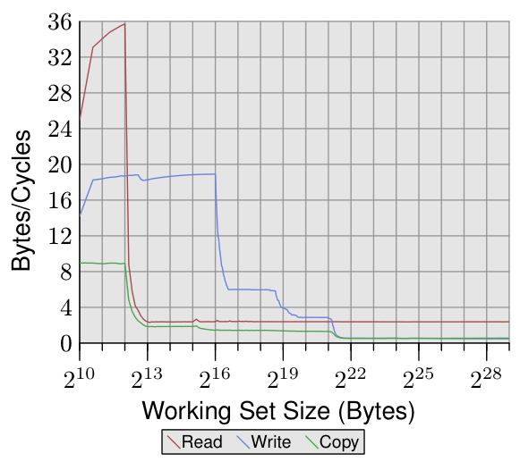

图3.28：AMD Family 10h Opteron带宽  
Figure 3.28: AMD Family 10h Opteron Bandwidth

人们注意到这些数字的第一个细节是，如果L1d缓存足够，处理器每个周期能够处理两条指令。读性能超过每周期32字节，甚至写性能也高达每周期18.7字节。不过，读曲线很快就变平了，并且只有每周期2.3字节，相当低。用于这项测试的处理器不预取任何数据，至少不能高效地预取。

The first detail one notices about the numbers is that the processor is capable of handling two instructions per cycle if the L1d cache is sufficient. The read performance exceeds 32 bytes per cycle and even the write performance is, with 18.7 bytes per cycle, high. The read curve flattens quickly, though, and is, with 2.3 bytes per cycle, pretty low. The processor for this test does not prefetch any data, at least not efficiently.

另一方面，写曲线的表现与各级缓存的大小相符。在L1d的全部大小范围内达到峰值性能，对于L2下降到每周期6字节，对于L3下降到每周期2.8字节，如果连L3都无法容纳所有数据，最终下降到每周期0.5字节。L1d缓存的性能超过了（较旧的）Core 2处理器，L2访问同样快（Core 2的缓存更大），而L3和主存访问更慢。

The write curve on the other hand performs according to the sizes of the various caches. The peak performance is achieved for the full size of the L1d, going down to 6 bytes per cycle for L2, to 2.8 bytes per cycle for L3, and finally .5 bytes per cycle if not even L3 can hold all the data. The performance for the L1d cache exceeds that of the (older) Core 2 processor, the L2 access is equally fast (with the Core 2 having a larger cache), and the L3 and main memory access is slower.

复制性能不可能比读或写性能更好。这就是为什么我们看到曲线起初由读性能主导，后来由写性能主导。

The copy performance cannot be better than either the read or write performance. This is why we see the curve initially dominated by the read performance and later by the write performance.

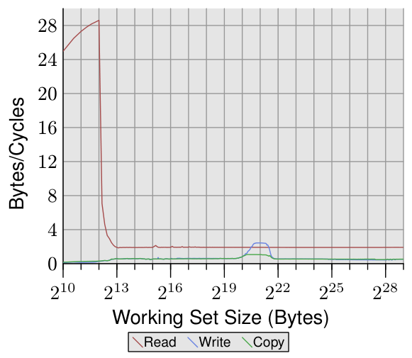

图3.29：AMD Fam 10h带宽（2个线程）  
Figure 3.29: AMD Fam 10h Bandwidth with 2 Threads

Opteron处理器的多线程性能如图3.29所示。读性能基本不受影响。每个线程的L1d和L2像以前一样工作，而在这种情况下L3缓存也没有得到很好的预取。两个线程并没有为了它们的目的过度地给L3施加压力。这项测试中的大问题是写性能。线程共享的所有数据都必须经过L3缓存。这种共享似乎相当低效，因为即使L3缓存的大小足以容纳整个工作集，代价也明显高于一次L3访问。把这张图与图3.27比较，我们看到，在适当的工作集大小范围内，Core 2处理器的两个线程以共享L2缓存的速度运行。对于Opteron处理器，只有在非常小的工作集大小范围内才能达到这一性能水平，而且即使在那里，它也只接近L3的速度，而L3比Core 2的L2慢。

The multi-thread performance of the Opteron processor is shown in Figure 3.29. The read performance is largely unaffected. Each thread’s L1d and L2 works as before and the L3 cache is in this case not prefetched very well either. The two threads do not unduly stress the L3 for their purpose. The big problem in this test is the write performance. All data the threads share has to go through the L3 cache. This sharing seems to be quite inefficient since even if the L3 cache size is sufficient to hold the entire working set the cost is significantly higher than an L3 access. Comparing this graph with Figure 3.27 we see that the two threads of the Core 2 processor operate at the speed of the shared L2 cache for the appropriate range of working set sizes. This level of performance is achieved for the Opteron processor only for a very small range of the working set sizes and even here it approaches only the speed of the L3 which is slower than the Core 2’s L2.

#### 3.5.2 关键字加载

#### 3.5.2 Critical Word Load

内存以小于缓存行大小的块从主存传输到缓存中。如今一次传输64*位*，而缓存行大小为64或128*字节*。这意味着每个缓存行需要8次或16次传输。

Memory is transferred from the main memory into the caches in blocks which are smaller than the cache line size. Today 64 *bits* are transferred at once and the cache line size is 64 or 128 *bytes*. This means 8 or 16 transfers per cache line are needed.

如果程序对数据缓存或指令缓存的访问未命中（即这是一次强制性缓存未命中——因为数据是第一次被使用；或者是一次容量缓存未命中——因为有限的缓存大小需要逐出该缓存行），情况就不同了。程序继续运行所需的缓存行中的那个字可能不是缓存行中的第一个字。即使在突发模式下并采用双倍数据速率传输，各个64位块到达的时间也明显不同。每个块都比前一个块晚4个或更多CPU周期到达。如果程序继续运行所需的字是缓存行的第八个字，那么在第一个字到达之后，程序还必须再等待30个或更多周期。

If a program’s cache access of the data or instruction caches misses (that means, it is a compulsory cache miss, because the data is used for the first time, or a capacity cache miss, because the limited cache size requires eviction of the cache line) the situation is different. The word inside the cache line which is required for the program to continue might not be the first word in the cache line. Even in burst mode and with double data rate transfer the individual 64-bit blocks arrive at noticeably different times. Each block arrives 4 CPU cycles or more later than the previous one. If the word the program needs to continue is the eighth of the cache line the program has to wait an additional 30 cycles or more after the first word arrives.

情况不一定非得如此。内存控制器可以自由地以不同的顺序请求缓存行中的字。处理器可以告知程序正在等待的是哪个字，即*关键字*，内存控制器可以先请求这个字。一旦这个字到达，程序就可以继续运行，而缓存行的其余部分仍在到达途中，缓存尚未处于一致状态。这种技术称为“关键字优先与提前重启”（Critical Word First & Early Restart）。

Things do not necessarily have to be like this. The memory controller is free to request the words of the cache line in a different order. The processor can communicate which word the program is waiting on, the *critical word*, and the memory controller can request this word first. Once the word arrives the program can continue while the rest of the cache line arrives and the cache is not yet in a consistent state. This technique is called Critical Word First & Early Restart.

如今的处理器实现了这项技术，但有些情况下这是不可能的。如果处理器预取数据，关键字是未知的。如果处理器在预取操作进行期间请求该缓存行，它将不得不等到关键字到达，而无法影响顺序。

Processors nowadays implement this technique but there are situations when that is not possible. If the processor prefetches data the critical word is not known. Should the processor request the cache line during the time the prefetch operation is in flight it will have to wait until the critical word arrives without being able to influence the order.

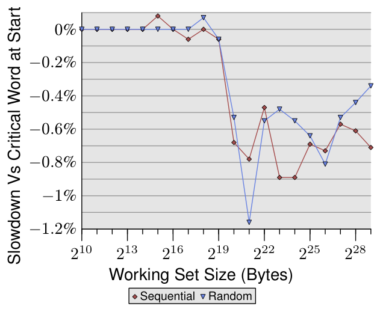

图3.30：关键字位于缓存行末尾  
Figure 3.30: Critical Word at End of Cache Line

即使有了这些优化，关键字在缓存行上的位置也很重要。图3.30显示了顺序访问和随机访问的Follow测试。图中显示的是，在指针追逐中所用的指针位于第一个字时与位于最后一个字时相比，运行测试的变慢程度。元素大小为64字节，对应于缓存行大小。数字噪声相当大，但可以看出，一旦L2不足以容纳工作集，关键字在末尾时的性能大约慢0.7%。顺序访问似乎受影响更大一些。这与前面提到的预取下一个缓存行时的问题是一致的。

Even with these optimizations in place the position of the critical word on a cache line matters. Figure 3.30 shows the Follow test for sequential and random access. Shown is the slowdown of running the test with the pointer used in the chase in the first word versus the case when the pointer is in the last word. The element size is 64 bytes, corresponding the cache line size. The numbers are quite noisy but it can be seen that, as soon as the L2 is not sufficient to hold the working set size, the performance of the case where the critical word is at the end is about 0.7% slower. The sequential access appears to be affected a bit more. This would be consistent with the aforementioned problem when prefetching the next cache line.

#### 3.5.3 缓存的布局

#### 3.5.3 Cache Placement

缓存相对于超线程、内核和处理器的布局不受程序员控制。但程序员可以决定线程在哪里执行，这时缓存与所用CPU之间的关系就变得重要了。

Where the caches are placed in relationship to the hyper-threads, cores, and processors is not under control of the programmer. But programmers can determine where the threads are executed and then it becomes important how the caches relate to the used CPUs.

这里我们不深入讨论何时选择哪些内核来运行线程的细节。我们只描述程序员在设置线程亲和性时必须考虑的架构细节。

Here we will not go into details of when to select what cores to run the threads. We will only describe architecture details which the programmer has to take into account when setting the affinity of the threads.

按照定义，超线程共享除寄存器组之外的一切。这包括L1缓存。这里没什么更多可说的。有趣的是处理器的各个内核。每个内核至少有自己的L1缓存。除此之外，如今它们之间没有多少共同的细节：

Hyper-threads, by definition share everything but the register set. This includes the L1 caches. There is not much more to say here. The fun starts with the individual cores of a processor. Each core has at least its own L1 caches. Aside from this there are today not many details in common:

- 早期的多核处理器根本没有共享缓存。

  Early multi-core processors had no shared caches at all.
- 后来的Intel型号为双核处理器提供共享的L2缓存。对于四核处理器，我们必须面对每对内核各有一个单独L2缓存的情况。没有更高级别的缓存。

  Later Intel models have shared L2 caches for dual-core processors. For quad-core processors we have to deal with separate L2 caches for each pair of two cores. There are no higher level caches.
- AMD的family 10h处理器有独立的L2缓存和一个统一的L3缓存。

  AMD’s family 10h processors have separate L2 caches and a unified L3 cache.

处理器厂商的宣传材料中写了很多关于各自型号优点的内容。如果各内核处理的工作集不重叠，没有共享缓存是有好处的。这对单线程程序很有效。由于这在今天往往仍是现实，这种方法的表现并不太差。但总会有一些重叠。所有缓存都包含常用运行时库中最活跃使用的部分，这意味着一些缓存空间被浪费了。

A lot has been written in the propaganda material of the processor vendors about the advantage of their respective models. Having no shared cache has an advantage if the working sets handled by the cores do not overlap. This works well for single-threaded programs. Since this is still often the reality today this approach does not perform too badly. But there is always some overlap. The caches all contain the most actively used parts of the common runtime libraries which means some cache space is wasted.

像Intel的双核处理器那样完全共享除L1之外的所有缓存，可能有很大的优势。如果在两个内核上工作的线程的工作集显著重叠，可用的缓存总量就会增加，工作集可以更大而不会降低性能。如果工作集不重叠，Intel的高级智能缓存（Advanced Smart Cache）管理应该能防止任何一个内核独占整个缓存。

Completely sharing all caches beside L1 as Intel’s dual-core processors do can have a big advantage. If the working set of the threads working on the two cores overlaps significantly the total available cache memory is increased and working sets can be bigger without performance degradation. If the working sets do not overlap Intel’s Advanced Smart Cache management is supposed to prevent any one core from monopolizing the entire cache.

不过，如果两个内核各自为其工作集使用大约一半的缓存，就会产生一些摩擦。缓存必须不断权衡两个内核的缓存使用，作为这种再平衡的一部分而执行的逐出可能选择得很糟糕。为了看出这些问题，我们来看另一个测试程序的结果。

If both cores use about half the cache for their respective working sets there is some friction, though. The cache constantly has to weigh the two cores’ cache use and the evictions performed as part of this rebalancing might be chosen poorly. To see the problems we look at the results of yet another test program.

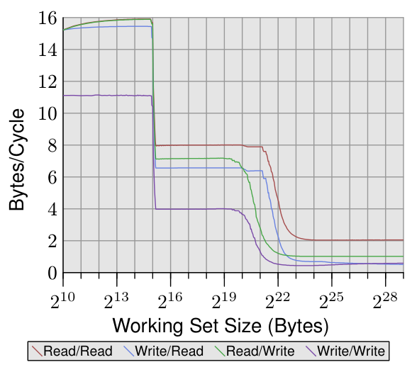

图3.31：两个进程时的带宽  
Figure 3.31: Bandwidth with two Processes  
Read/Read等：后台进程操作/被测进程操作。

该测试程序有一个进程使用SSE指令不断地读取或写入一个2MB的内存块。之所以选择2MB，是因为这是该Core 2处理器L2缓存大小的一半。该进程被固定在一个内核上，而第二个进程被固定在另一个内核上。第二个进程读写一个大小可变的内存区域。图中显示了每个周期读取或写入的字节数。显示了四条不同的曲线，对应两个进程读和写的每种组合。读/写曲线对应的是：后台进程总是使用2MB工作集进行写入，而被测进程以可变工作集进行读取。

The test program has one process constantly reading or writing, using SSE instructions, a 2MB block of memory. 2MB was chosen because this is half the size of the L2 cache of this Core 2 processor. The process is pinned to one core while a second process is pinned to the other core. This second process reads and writes a memory region of variable size. The graph shows the number of bytes per cycle which are read or written. Four different graphs are shown, one for each combination of the processes reading and writing. The read/write graph is for the background process, which always uses a 2MB working set to write, and the measured process with variable working set to read.

图中有趣的部分是2<sup>20</sup>到2<sup>23</sup>字节之间的部分。如果两个内核的L2缓存是完全独立的，我们可以预期所有四项测试的性能都会在2<sup>21</sup>到2<sup>22</sup>字节之间下降，也就是说，在L2缓存耗尽的时候。从图3.31中可以看出，情况并非如此。对于后台进程在写入的情况，这一点最为明显。性能在工作集大小达到1MB之前就开始恶化了。两个进程不共享内存，因此这两个进程不会导致RFO消息的产生。这些纯粹是缓存逐出的问题。智能缓存处理存在问题，其结果是每个内核实际感受到的缓存大小更接近1MB，而不是每个内核可用的2MB。人们只能希望，如果内核之间共享的缓存仍然是未来处理器的特性，用于智能缓存处理的算法能够得到修正。

The interesting part of the graph is the part between 2<sup>20</sup> and 2<sup>23</sup> bytes. If the L2 cache of the two cores were completely separate we could expect that the performance of all four tests would drop between 2<sup>21</sup> and 2<sup>22</sup> bytes, that means, once the L2 cache is exhausted. As we can see in Figure 3.31 this is not the case. For the cases where the background process is writing this is most visible. The performance starts to deteriorate before the working set size reaches 1MB. The two processes do not share memory and therefore the processes do not cause RFO messages to be generated. These are pure cache eviction problems. The smart cache handling has its problems with the effect that the experienced cache size per core is closer to 1MB than the 2MB per core which are available. One can only hope that, if caches shared between cores remain a feature of upcoming processors, the algorithm used for the smart cache handling will be fixed.

拥有两个L2缓存的四核处理器只是在引入更高级别缓存之前的权宜之计。与独立插槽和双核处理器相比，这种设计没有显著的性能优势。两个内核通过同一条总线通信，从外部看这就是FSB。没有特殊的快速数据交换通道。

Having a quad-core processor with two L2 caches was just a stop-gap solution before higher-level caches could be introduced. This design provides no significant performance advantage over separate sockets and dual-core processors. The two cores communicate via the same bus which is, at the outside, visible as the FSB. There is no special fast-track data exchange.

多核处理器缓存设计的未来将在于更多的层级。AMD的10h处理器家族开了个头。我们是否会继续看到较低级别的缓存由处理器的一部分内核共享，还有待观察（在2008年这一代处理器中，L2缓存不共享）。额外的缓存级别是必要的，因为高速且频繁使用的缓存不能在许多内核之间共享。那样会影响性能。它还将需要相联度很高的非常大的缓存。缓存大小和相联度这两个数字都必须随着共享缓存的内核数量而扩展。使用一个大的L3缓存和大小合理的L2缓存是一个合理的权衡。L3缓存较慢，但理想情况下它不像L2缓存那样频繁使用。

The future of cache design for multi-core processors will lie in more layers. AMD’s 10h processor family makes the start. Whether we will continue to see lower level caches be shared by a subset of the cores of a processor remains to be seen (in the 2008 generation of processors L2 caches are not shared). The extra levels of cache are necessary since the high-speed and frequently used caches cannot be shared among many cores. The performance would be impacted. It would also require very large caches with high associativity. Both numbers, the cache size and the associativity, must scale with the number of cores sharing the cache. Using a large L3 cache and reasonably-sized L2 caches is a reasonable trade-off. The L3 cache is slower but it is ideally not as frequently used as the L2 cache.

对于程序员来说，所有这些不同的设计都意味着在作调度决策时的复杂性。为了获得最佳性能，必须了解工作负载和机器架构的细节。幸运的是，我们有支持来确定机器架构。这些接口将在后面的章节中介绍。

For programmers all these different designs mean complexity when making scheduling decisions. One has to know the workloads and the details of the machine architecture to achieve the best performance. Fortunately we have support to determine the machine architecture. The interfaces will be introduced in later sections.

#### 3.5.4 FSB的影响

#### 3.5.4 FSB Influence

FSB在机器的性能中起着核心作用。缓存内容的存储和加载速度只能与到内存的连接所允许的速度一样快。我们可以在两台仅内存模块速度不同的机器上运行一个程序，来展示其影响有多大。图3.32显示了在64位机器上NPAD=7时Addnext0测试（把下一个元素的`pad[0]`元素的内容加到自己的`pad[0]`元素上）的结果。两台机器都使用Intel Core 2处理器，第一台使用667MHz DDR2模块，第二台使用800MHz模块（提高了20%）。

The FSB plays a central role in the performance of the machine. Cache content can only be stored and loaded as quickly as the connection to the memory allows. We can show how much so by running a program on two machines which only differ in the speed of their memory modules. Figure 3.32 shows the results of the Addnext0 test (adding the content of the next elements `pad[0]` element to the own `pad[0]` element) for NPAD=7 on a 64-bit machine. Both machines have Intel Core 2 processors, the first uses 667MHz DDR2 modules, the second 800MHz modules (a 20% increase).

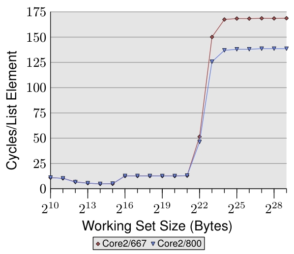

图3.32：FSB速度的影响  
Figure 3.32: Influence of FSB Speed

数字表明，当FSB在大工作集大小下真正承受压力时，我们确实看到了很大的收益。在这项测试中测得的最大性能提升为18.2%，接近理论最大值。这表明，更快的FSB确实可以带来巨大的回报。当工作集能放进缓存时（这些处理器有4MB L2），它并不关键。必须记住，我们在这里测量的是一个程序。一个系统的工作集包括所有并发运行进程所需的内存。这样，使用小得多的程序就很容易超过4MB甚至更多的内存。

The numbers show that, when the FSB is really stressed for large working set sizes, we indeed see a large benefit. The maximum performance increase measured in this test is 18.2%, close to the theoretical maximum. What this shows is that a faster FSB indeed can pay off big time. It is not critical when the working set fits into the caches (and these processors have a 4MB L2). It must be kept in mind that we are measuring one program here. The working set of a system comprises the memory needed by all concurrently running processes. This way it is easily possible to exceed 4MB memory or more with much smaller programs.

如今Intel的一些处理器支持高达1,333MHz的FSB速度，这将意味着再提高60%。未来将会看到更高的速度。如果速度很重要并且工作集较大，快速的RAM和高FSB速度当然值得花钱。不过必须小心，因为即使处理器可能支持更高的FSB速度，主板/北桥却可能不支持。检查规格至关重要。

Today some of Intel’s processors support FSB speeds up to 1,333MHz which would mean another 60% increase. The future is going to see even higher speeds. If speed is important and the working set sizes are larger, fast RAM and high FSB speeds are certainly worth the money. One has to be careful, though, since even though the processor might support higher FSB speeds the motherboard/Northbridge might not. It is critical to check the specifications.

[^16]: ↑ 在更早的系统中，缓存像CPU和主存一样连接到系统总线上。这与其说是真正的解决方案，不如说是一种权宜之计。

    ↑ In even earlier systems the cache was attached to the system bus just like the CPU and the main memory. This was more a hack than a real solution.
[^17]: ↑ 早期的多核处理器甚至拥有独立的二级缓存，并且没有三级缓存。

    ↑ Early multi-core processors even had separate 2<sup>nd</sup> level caches and no 3<sup>rd</sup> level cache.
[^18]: ↑ 地址的**S**部分相同的所有缓存行都被称为同一个别名。

    ↑ All cache lines with the same **S** part of the address are known by the same alias.
[^19]: ↑ 这种概括并不完全正确。有少数缓存是独占式的，而一些包含式缓存也具有独占式缓存的特性。

    ↑ This generalization is not completely correct. A few caches are exclusive and some inclusive caches have exclusive cache properties.
[^20]: ↑ 是的，这有点不一致，因为在其他测试中我们把结构中未使用的部分计入了元素大小，而且我们本可以定义NPAD使每个元素填满一页。在那种情况下，工作集大小会非常不同。不过这并不是这项测试的重点，而且由于预取无论如何都是无效的，这几乎没有什么区别。

    ↑ Yes, this is a bit inconsistent because in the other tests we count the unused part of the struct in the element size and we could define NPAD so that each element fills a page. In that case the working set sizes would be very different. This is not the point of this test, though, and since prefetching is ineffective anyway this makes little difference.
[^21]: ↑ 在更小的层面上，同一处理器上的两个内核也是如此。只是代价稍小一些。RFO消息很可能会被发送很多次。

    ↑ At a smaller level the same is true for two cores on the same processor. The costs are just a bit smaller. The RFO message is likely to be sent many times.
[^22]: ↑ 这就是为什么如今我们会看到例如三插槽的AMD Opteron系统。考虑到每个处理器只有三条超传输链路，其中一条用于连接北桥，每个处理器恰好只相隔一跳。

    ↑ Which is why we see nowadays, for instance, AMD Opteron systems with three sockets. Each processor is exactly one hop away given that the processors only have three hyperlinks and one is needed for the Northbridge connection.
[^23]: ↑ 保持超线程开启的另一个理由是调试。SMT在发现并行代码中的某些类别的问题方面出奇地好。

    ↑ Another reason to keep hyper-threads enabled is debugging. SMT is astonishingly good at finding some sets of problems in parallel code.

## 4 虚拟内存

## 4 Virtual Memory

处理器的虚拟内存（VM）子系统实现了为每个进程提供的虚拟地址空间。这使得每个进程都认为自己独占系统。虚拟内存的种种优点在其他地方已有详细描述，这里不再赘述。本节转而集中讨论虚拟内存子系统的实际实现细节及相关代价。

The virtual memory (VM) subsystem of a processor implements the virtual address spaces provided to each process. This makes each process think it is alone in the system. The list of advantages of virtual memory are described in detail elsewhere so they will not be repeated here. Instead this section concentrates on the actual implementation details of the virtual memory subsystem and the associated costs.

虚拟地址空间由CPU的内存管理单元（MMU）实现。操作系统必须填写页表数据结构，但大多数CPU会自行完成其余的工作。这实际上是一个相当复杂的机制；理解它的最好方法是介绍用于描述虚拟地址空间的数据结构。

A virtual address space is implemented by the Memory Management Unit (MMU) of the CPU. The OS has to fill out the page table data structures, but most CPUs do the rest of the work themselves. This is actually a pretty complicated mechanism; the best way to understand it is to introduce the data structures used to describe the virtual address space.

MMU所执行的地址转换的输入是一个虚拟地址。对其取值通常没有什么限制——即使有也很少。在32位系统上虚拟地址是32位的值，在64位系统上是64位的值。在某些系统上，例如x86和x86-64，所使用的地址实际上还涉及另一层间接：这些架构使用段，段只是给每个逻辑地址加上一个偏移量。我们可以忽略地址生成的这一部分，它很简单，而且就内存处理的性能而言，程序员不必关心它。<sup>24</sup>

The input to the address translation performed by the MMU is a virtual address. There are usually few–if any–restrictions on its value. Virtual addresses are 32-bit values on 32-bit systems, and 64-bit values on 64-bit systems. On some systems, for instance x86 and x86-64, the addresses used actually involve another level of indirection: these architectures use segments which simply cause an offset to be added to every logical address. We can ignore this part of address generation, it is trivial and not something that programmers have to care about with respect to performance of memory handling.<sup>24</sup>

### 4.1 最简单的地址转换

### 4.1 Simplest Address Translation

有趣的部分是把虚拟地址转换为物理地址。MMU可以按页重新映射地址。就像寻址缓存行时一样，虚拟地址被分成几个不同的部分。这些部分被用作索引，访问构建最终物理地址时所用的各种表。在最简单的模型中，我们只有一级表。

The interesting part is the translation of the virtual address to a physical address. The MMU can remap addresses on a page-by-page basis. Just as when addressing cache lines, the virtual address is split into distinct parts. These parts are used to index into various tables which are used in the construction of the final physical address. For the simplest model we have only one level of tables.

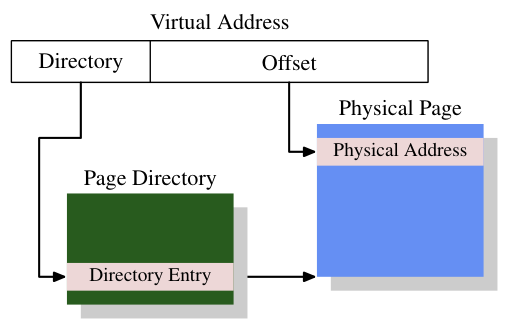

图4.1：一级地址转换  
Figure 4.1: 1-Level Address Translation  
Virtual Address=虚拟地址，Directory=目录，Offset=偏移，Page Directory=页目录，Directory Entry=目录条目，Physical Page=物理页，Physical Address=物理地址。

图4.1展示了虚拟地址的不同部分是如何使用的。高位部分用于在页目录中选择一个条目；该目录中的每个条目都可以由操作系统单独设置。页目录条目决定了一个物理内存页的地址；页目录中可以有不止一个条目指向同一个物理地址。存储单元的完整物理地址由页目录中的页地址与虚拟地址的低位组合而成。页目录条目还包含有关该页的一些附加信息，例如访问权限。

Figure 4.1 shows how the different parts of the virtual address are used. A top part is used to select an entry in a Page Directory; each entry in that directory can be individually set by the OS. The page directory entry determines the address of a physical memory page; more than one entry in the page directory can point to the same physical address. The complete physical address of the memory cell is determined by combining the page address from the page directory with the low bits from the virtual address. The page directory entry also contains some additional information about the page such as access permissions.

页目录的数据结构存储在主存中。操作系统必须分配连续的物理内存，并把该内存区域的基地址存入一个特殊寄存器。然后虚拟地址的相应位被用作页目录的索引，而页目录实际上就是一个目录条目数组。

The data structure for the page directory is stored in main memory. The OS has to allocate contiguous physical memory and store the base address of this memory region in a special register. The appropriate bits of the virtual address are then used as an index into the page directory, which is actually an array of directory entries.

举一个具体的例子，这是x86机器上4MB页所使用的布局。虚拟地址的偏移部分为22位，足以寻址4MB页中的每个字节。虚拟地址剩下的10位用于选择页目录中1024个条目之一。每个条目包含一个4MB页的10位基地址，它与偏移量组合形成完整的32位地址。

For a concrete example, this is the layout used for 4MB pages on x86 machines. The Offset part of the virtual address is 22 bits in size, enough to address every byte in a 4MB page. The remaining 10 bits of the virtual address select one of the 1024 entries in the page directory. Each entry contains a 10 bit base address of a 4MB page which is combined with the offset to form a complete 32 bit address.

### 4.2 多级页表

### 4.2 Multi-Level Page Tables

4MB页并不是常态，它们会浪费大量内存，因为操作系统必须执行的许多操作都要求按内存页对齐。对于4kB页（这是32位机器上的常态，在64位机器上也仍然常见），虚拟地址的偏移部分只有12位。这就剩下20位作为页目录的选择器。一个有2<sup>20</sup>个条目的表是不切实际的。即使每个条目只有4字节，这个表也有4MB大。由于每个进程都可能拥有自己独立的页目录，系统的大部分物理内存都将被这些页目录占用。

4MB pages are not the norm, they would waste a lot of memory since many operations an OS has to perform require alignment to memory pages. With 4kB pages (the norm on 32-bit machines and, still, often on 64-bit machines), the Offset part of the virtual address is only 12 bits in size. This leaves 20 bits as the selector of the page directory. A table with 2<sup>20</sup> entries is not practical. Even if each entry would be only 4 bytes the table would be 4MB in size. With each process potentially having its own distinct page directory much of the physical memory of the system would be tied up for these page directories.

解决办法是使用多级页表。这些层级共同构成一个巨大的稀疏页目录；地址空间中实际未被使用的区域不需要分配内存。这样的表示方式紧凑得多，使得内存中可以容纳许多进程的页表，而不会对性能造成太大影响。

The solution is to use multiple levels of page tables. The level then form a huge, sparse page directory; address space regions which are not actually used do not require allocated memory. The representation is therefore much more compact, making it possible to have the page tables for many processes in memory without impacting performance too much.

如今最复杂的页表结构包含四级。图4.2展示了这样一种实现的示意图。在这个例子中，虚拟地址被分成至少五个部分。其中四个部分是各级目录的索引。第4级目录通过CPU中的一个专用寄存器引用。第4级到第2级目录的内容是对下一级目录的引用。如果一个目录条目被标记为空，它显然不必指向任何更低级的目录。这样页表树就可以是稀疏而紧凑的。第1级目录的条目就像在图4.1中一样，是部分物理地址，外加访问权限之类的辅助数据。

Today the most complicated page table structures comprise four levels. Figure 4.2 shows the schematics of such an implementation. The virtual address is, in this example, split into at least five parts. Four of these parts are indexes into the various directories. The level 4 directory is referenced using a special-purpose register in the CPU. The content of the level 4 to level 2 directories is a reference to next lower level directory. If a directory entry is marked empty it obviously need not point to any lower directory. This way the page table tree can be sparse and compact. The entries of the level 1 directory are, just like in Figure 4.1, partial physical addresses, plus auxiliary data like access permissions.

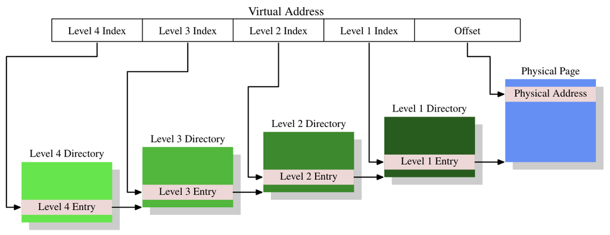

图4.2：四级地址转换  
Figure 4.2: 4-Level Address Translation  
Level n Index/Entry/Directory=第n级索引/条目/目录。

为了确定与某个虚拟地址对应的物理地址，处理器首先确定最高级目录的地址。这个地址通常存储在一个寄存器中。然后CPU取出虚拟地址中对应于该目录的索引部分，用这个索引挑选出相应的条目。这个条目是下一级目录的地址，再用虚拟地址的下一部分对其进行索引。这一过程持续进行，直到到达第1级目录，此时目录条目的值就是物理地址的高位部分。加上虚拟地址中的页偏移位，物理地址就完整了。这个过程称为页树遍历。有些处理器（如x86和x86-64）在硬件中执行这一操作，另一些则需要操作系统的协助。

To determine the physical address corresponding to a virtual address the processor first determines the address of the highest level directory. This address is usually stored in a register. Then the CPU takes the index part of the virtual address corresponding to this directory and uses that index to pick the appropriate entry. This entry is the address of the next directory, which is indexed using the next part of the virtual address. This process continues until it reaches the level 1 directory, at which point the value of the directory entry is the high part of the physical address. The physical address is completed by adding the page offset bits from the virtual address. This process is called page tree walking. Some processors (like x86 and x86-64) perform this operation in hardware, others need assistance from the OS.

系统上运行的每个进程都可能需要自己的页表树。部分共享页表树是可能的，但这只是例外。因此，如果页表树所需的内存尽可能少，对性能和可扩展性都有好处。理想的情况是把所使用的内存在虚拟地址空间中彼此靠近地放置；实际使用的物理地址并不重要。一个小程序可能只需在第2、3、4级各使用一个目录，再加上少量第1级目录就够了。在x86-64上，使用4kB页且每个目录有512个条目，总共用4个目录（每级一个）就可以寻址2MB。1GB的连续内存可以用第2到第4级各一个目录、第1级512个目录来寻址。

Each process running on the system might need its own page table tree. It is possible to partially share trees but this is rather the exception. It is therefore good for performance and scalability if the memory needed by the page table trees is as small as possible. The ideal case for this is to place the used memory close together in the virtual address space; the actual physical addresses used do not matter. A small program might get by with using just one directory at each of levels 2, 3, and 4 and a few level 1 directories. On x86-64 with 4kB pages and 512 entries per directory this allows the addressing of 2MB with a total of 4 directories (one for each level). 1GB of contiguous memory can be addressed with one directory for levels 2 to 4 and 512 directories for level 1.

不过，假设所有内存都可以连续分配未免太过简单化了。出于灵活性的考虑，一个进程的栈和堆区域在大多数情况下被分配在地址空间几乎相对的两端。这使得任何一个区域在需要时都能尽可能地增长。这意味着很可能需要两个第2级目录，以及相应更多的低级目录。

Assuming all memory can be allocated contiguously is too simplistic, though. For flexibility reasons the stack and the heap area of a process are, in most cases, allocated at pretty much opposite ends of the address space. This allows either area to grow as much as possible if needed. This means that there are most likely two level 2 directories needed and correspondingly more lower level directories.

但即便如此也并不总是符合当前的实践。出于安全原因，可执行文件的各个部分（代码、数据、堆、栈、动态共享对象（DSO，又称共享库））被映射到随机化的地址上[9]。随机化扩展到各部分的相对位置；这意味着进程中使用的各个内存区域在整个虚拟地址空间中分布得很广。通过对地址中被随机化的位数加以限制，可以缩小范围，但在大多数情况下，这肯定无法让进程只用一两个第2级和第3级目录就能运行。

But even this does not always match current practice. For security reasons the various parts of an executable (code, data, heap, stack, Dynamic Shared Objects (DSOs), aka shared libraries) are mapped at randomized addresses [9]. The randomization extends to the relative position of the various parts; that implies that the various memory regions in use in a process are widespread throughout the virtual address space. By applying some limits to the number of bits of the address which are randomized the range can be restricted, but it certainly, in most cases, will not allow a process to run with just one or two directories for levels 2 and 3.

如果性能真的比安全重要得多，可以关闭随机化。这时操作系统通常至少会把所有DSO连续地加载到虚拟内存中。

If performance is really much more important than security, randomization can be turned off. The OS will then usually at least load all DSOs contiguously in virtual memory.

### 4.3 优化页表访问

### 4.3 Optimizing Page Table Access

页表的所有数据结构都保存在主存中；操作系统在那里构建和更新这些表。在创建进程或修改页表时，CPU会得到通知。页表通过上面描述的页表遍历，把每个虚拟地址解析为物理地址。更确切地说：在解析一个虚拟地址的过程中，每一级至少要使用一个目录。这需要多达四次内存访问（针对运行中进程的一次访问），这很慢。可以把这些目录表条目当作普通数据，缓存在L1d、L2等中，但这样仍然太慢了。

All the data structures for the page tables are kept in the main memory; this is where the OS constructs and updates the tables. Upon creation of a process or a change of a page table the CPU is notified. The page tables are used to resolve every virtual address into a physical address using the page table walk described above. More to the point: at least one directory for each level is used in the process of resolving a virtual address. This requires up to four memory accesses (for a single access by the running process) which is slow. It is possible to treat these directory table entries as normal data and cache them in L1d, L2, etc., but this would still be far too slow.

从虚拟内存的最早期开始，CPU设计者就使用了一种不同的优化。一个简单的计算就可以表明，只把目录表条目保存在L1d及更高级的缓存中，性能会非常糟糕。每一次绝对地址计算都需要与页表深度相对应的若干次L1d访问。这些访问无法并行化，因为它们依赖于前一次查找的结果。仅此一项，在有四级页表的机器上就至少需要12个周期。再加上L1d未命中的可能性，其结果是指令流水线无法隐藏的。额外的L1d访问还会抢占宝贵的缓存带宽。

From the earliest days of virtual memory, CPU designers have used a different optimization. A simple computation can show that only keeping the directory table entries in the L1d and higher cache would lead to horrible performance. Each absolute address computation would require a number of L1d accesses corresponding to the page table depth. These accesses cannot be parallelized since they depend on the previous lookup’s result. This alone would, on a machine with four page table levels, require at the very least 12 cycles. Add to that the probability of an L1d miss and the result is nothing the instruction pipeline can hide. The additional L1d accesses also steal precious bandwidth to the cache.

因此，被缓存的不只是目录表条目，而是物理页地址的完整计算结果。出于与代码缓存和数据缓存有效的相同原因，这种被缓存的地址计算也是有效的。由于虚拟地址的页偏移部分在物理页地址的计算中不起任何作用，只有虚拟地址的其余部分被用作缓存的标记。根据页大小的不同，这意味着成百上千条指令或数据对象共享同一个标记，因而共享同一个物理地址前缀。

So, instead of just caching the directory table entries, the complete computation of the address of the physical page is cached. For the same reason that code and data caches work, such a cached address computation is effective. Since the page offset part of the virtual address does not play any part in the computation of the physical page address, only the rest of the virtual address is used as the tag for the cache. Depending on the page size this means hundreds or thousands of instructions or data objects share the same tag and therefore same physical address prefix.

存放这些计算结果的缓存称为转换后备缓冲区（TLB）。由于它必须极快，它通常是一个很小的缓存。现代CPU与其他缓存一样提供多级TLB缓存；更高级别的缓存更大、更慢。L1TLB容量小的缺点通常通过使其成为全相联缓存并采用LRU逐出策略来弥补。最近，这种缓存的容量一直在增长，在此过程中被改为组相联的。因此，每当必须添加一个新条目时，被逐出和替换的不一定是最旧的条目。

The cache into which the computed values are stored is called the Translation Look-Aside Buffer (TLB). It is usually a small cache since it has to be extremely fast. Modern CPUs provide multi-level TLB caches, just as for the other caches; the higher-level caches are larger and slower. The small size of the L1TLB is often made up for by making the cache fully associative, with an LRU eviction policy. Recently, this cache has been growing in size and, in the process, was changed to be set associative. As a result, it might not be the oldest entry which gets evicted and replaced whenever a new entry has to be added.

如上所述，用于访问TLB的标记是虚拟地址的一部分。如果标记在缓存中有匹配，就把虚拟地址中的页偏移加到缓存的值上，计算出最终的物理地址。这是一个非常快的过程；它也必须很快，因为每一条使用绝对地址的指令都需要物理地址，在某些情况下，以物理地址为键的L2查找也需要它。如果TLB查找未命中，处理器就必须执行页表遍历；这可能代价相当高。

As noted above, the tag used to access the TLB is a part of the virtual address. If the tag has a match in the cache, the final physical address is computed by adding the page offset from the virtual address to the cached value. This is a very fast process; it has to be since the physical address must be available for every instruction using absolute addresses and, in some cases, for L2 look-ups which use the physical address as the key. If the TLB lookup misses the processor has to perform a page table walk; this can be quite costly.

如果地址位于另一页上，通过软件或硬件预取代码或数据可能会隐式地预取TLB条目。对于硬件预取，这是不能允许的，因为硬件可能会发起无效的页表遍历。因此程序员不能依赖硬件预取来预取TLB条目。这必须使用预取指令显式地完成。TLB与数据缓存和指令缓存一样，可以有多级。与数据缓存一样，TLB通常有两种形式：指令TLB（ITLB）和数据TLB（DTLB）。像L2TLB这样的更高级TLB通常是统一的，其他缓存也是如此。

Prefetching code or data through software or hardware could implicitly prefetch entries for the TLB if the address is on another page. This cannot be allowed for hardware prefetching because the hardware could initiate page table walks that are invalid. Programmers therefore cannot rely on hardware prefetching to prefetch TLB entries. It has to be done explicitly using prefetch instructions. TLBs, just like data and instruction caches, can appear in multiple levels. Just as for the data cache, the TLB usually appears in two flavors: an instruction TLB (ITLB) and a data TLB (DTLB). Higher-level TLBs such as the L2TLB are usually unified, as is the case with the other caches.

#### 4.3.1 使用TLB的注意事项

#### 4.3.1 Caveats Of Using A TLB

TLB是处理器内核的全局资源。在该处理器内核上执行的所有线程和进程都使用同一个TLB。由于虚拟地址到物理地址的转换取决于安装的是哪棵页表树，如果页表发生变化，CPU不能盲目地重用缓存的条目。每个进程都有不同的页表树（但同一进程中的线程没有），内核和VMM（虚拟机监视器，如果存在的话）也有各自的页表树。进程的地址空间布局也可能发生变化。有两种方法来处理这个问题：

The TLB is a processor-core global resource. All threads and processes executed on the processor core use the same TLB. Since the translation of virtual to physical addresses depends on which page table tree is installed, the CPU cannot blindly reuse the cached entries if the page table is changed. Each process has a different page table tree (but not the threads in the same process) as does the kernel and the VMM (hypervisor) if present. It is also possible that the address space layout of a process changes. There are two ways to deal with this problem:

- 每当页表树改变时就刷新TLB。

  The TLB is flushed whenever the page table tree is changed.
- 扩展TLB条目的标记，使其额外地、唯一地标识它们所引用的页表树。

  The tags for the TLB entries are extended to additionally and uniquely identify the page table tree they refer to.

在第一种情况下，每当执行上下文切换时都要刷新TLB。由于在大多数操作系统中，从一个线程/进程切换到另一个线程/进程需要执行一些内核代码，TLB刷新被限制在离开（有时是进入）内核地址空间时。在虚拟化系统上，当内核必须调用VMM时以及返回时也会发生刷新。如果内核和/或VMM不必使用虚拟地址，或者可以重用发起系统调用/VMM调用的进程或内核的同一组虚拟地址（即地址空间是叠加的），那么只有当离开内核或VMM时处理器要恢复执行一个不同的进程或内核时，才需要刷新TLB。

In the first case the TLB is flushed whenever a context switch is performed. Since, in most OSes, a switch from one thread/process to another requires executing some kernel code, TLB flushes are restricted to leaving (and sometimes entering) the kernel address space. On virtualized systems it also happens when the kernel has to call the VMM and on the way back. If the kernel and/or VMM does not have to use virtual addresses, or can reuse the same virtual addresses as the process or kernel which made the system/VMM call (i.e., the address spaces are overlaid), the TLB only has to be flushed if, upon leaving the kernel or VMM, the processor resumes execution of a different process or kernel.

刷新TLB是有效的，但代价很高。例如，在执行一次系统调用时，内核代码可能只有几千条指令，接触的可能只是少数几个新页（或者一个大页，就像Linux在某些架构上那样）。这项工作替换的TLB条目数只与接触的页数一样多。对于Intel的Core2架构，它有128个ITLB条目和256个DTLB条目，一次完全刷新将意味着分别有100多个和200多个条目被不必要地刷新。当系统调用返回到同一进程时，所有这些被刷新的TLB条目本可以再次使用，但它们已经没了。内核或VMM中经常使用的代码也是如此。每次进入内核时，TLB都必须从头开始填充，尽管内核和VMM的页表通常不会改变，因而TLB条目理论上可以保留很长时间。这也解释了为什么如今处理器中的TLB缓存没有更大：程序很可能运行不了足够长的时间来填满所有这些条目。

Flushing the TLB is effective but expensive. When executing a system call, for instance, the kernel code might be restricted to a few thousand instructions which touch, perhaps, a handful of new pages (or one huge page, as is the case for Linux on some architectures). This work would replace only as many TLB entries as pages are touched. For Intel’s Core2 architecture with its 128 ITLB and 256 DTLB entries, a full flush would mean that more than 100 and 200 entries (respectively) would be flushed unnecessarily. When the system call returns to the same process, all those flushed TLB entries can be used again, but they will be gone. The same is true for often-used code in the kernel or VMM. On each entry into the kernel the TLB has to be filled from scratch even though the page tables for the kernel and VMM usually do not change and, therefore, TLB entries could, in theory, be preserved for a very long time. This also explains why the TLB caches in today’s processors are not bigger: programs most likely will not run long enough to fill all these entries.

这一事实当然没有逃过CPU架构师的眼睛。优化缓存刷新的一种可能是单独使TLB条目失效。例如，如果内核代码和数据落在某个特定的地址范围内，就只需要把落在这个地址范围内的页从TLB中逐出。这只需要比较标记，因此代价不高。这种方法在地址空间的一部分发生变化时也很有用，例如通过调用`munmap`。

This fact, of course, did not escape the CPU architects. One possibility to optimize the cache flushes is to individually invalidate TLB entries. For instance, if the kernel code and data falls into a specific address range, only the pages falling into this address range have to evicted from the TLB. This only requires comparing tags and, therefore, is not very expensive. This method is also useful in case a part of the address space is changed, for instance, through a call to `munmap`.

一个好得多的解决方案是扩展用于TLB访问的标记。如果除了虚拟地址的部分之外，再为每棵页表树（即一个进程的地址空间）加上一个唯一的标识符，TLB就根本不必完全刷新。内核、VMM以及各个进程都可以拥有唯一的标识符。这一方案唯一的问题是，可用于TLB标记的位数非常有限，而地址空间的数量却没有限制。这意味着一些标识符需要被重用。发生这种情况时，必须部分地刷新TLB（如果可能的话）。所有带有被重用标识符的条目都必须被刷新，但希望这是一个小得多的集合。

A much better solution is to extend the tag used for the TLB access. If, in addition to the part of the virtual address, a unique identifier for each page table tree (i.e., a process’s address space) is added, the TLB does not have to be completely flushed at all. The kernel, VMM, and the individual processes all can have unique identifiers. The only issue with this scheme is that the number of bits available for the TLB tag is severely limited, while the number of address spaces is not. This means some identifier reuse is necessary. When this happens the TLB has to be partially flushed (if this is possible). All entries with the reused identifier must be flushed but this is, hopefully, a much smaller set.

当系统上运行多个进程时，这种扩展的TLB标记在虚拟化领域之外也是有好处的。如果每个可运行进程的内存使用（因而TLB条目使用）是有限的，那么当一个进程再次被调度时，它最近使用的TLB条目很有可能仍在TLB中。但还有两个额外的优点：

This extended TLB tagging is of advantage outside the realm of virtualization when multiple processes are running on the system. If the memory use (and hence TLB entry use) of each of the runnable processes is limited, there is a good chance the most recently used TLB entries for a process are still in the TLB when it gets scheduled again. But there are two additional advantages:

1. 特殊的地址空间，例如内核和VMM所使用的地址空间，通常只被进入很短的时间；之后控制权通常返回到发起进入的那个地址空间。没有标记时，要执行一到两次TLB刷新。有了标记，调用方地址空间的缓存转换结果得以保留，而且由于内核和VMM地址空间根本不常改变TLB条目，之前系统调用等的转换结果仍然可以使用。

   Special address spaces, such as those used by the kernel and VMM, are often only entered for a short time; afterward control is often returned to the address space which initiated the entry. Without tags, one or two TLB flushes are performed. With tags the calling address space’s cached translations are preserved and, since the kernel and VMM address space do not often change TLB entries at all, the translations from previous system calls, etc. can still be used.
2. 在同一进程的两个线程之间切换时，根本不需要刷新TLB。不过，如果没有扩展的TLB标记，进入内核就会破坏第一个线程的TLB条目。

   When switching between two threads of the same process no TLB flush is necessary at all. Without extended TLB tags the entry into the kernel destroys the first thread’s TLB entries, though.

有些处理器已经实现这些扩展标记一段时间了。AMD在Pacifica虚拟化扩展中引入了1位的标记扩展。这个1位的地址空间ID（ASID）在虚拟化的语境下用于区分VMM的地址空间与客户域的地址空间。这使得操作系统可以避免在每次进入VMM时（例如为了处理缺页）刷新客户的TLB条目，或在控制权返回客户时刷新VMM的TLB条目。该架构将来会允许使用更多的位。其他主流处理器很可能会效仿并支持这一特性。

Some processors have, for some time, implemented these extended tags. AMD introduced a 1-bit tag extension with the Pacifica virtualization extensions. This 1-bit Address Space ID (ASID) is, in the context of virtualization, used to distinguish the VMM’s address space from that of the guest domains. This allows the OS to avoid flushing the guest’s TLB entries every time the VMM is entered (for instance, to handle a page fault) or the VMM’s TLB entries when control returns to the guest. The architecture will allow the use of more bits in the future. Other mainstream processors will likely follow suit and support this feature.

#### 4.3.2 影响TLB性能

#### 4.3.2 Influencing TLB Performance

有几个因素会影响TLB的性能。第一个是页的大小。显然，页越大，能放进去的指令或数据对象就越多。因此，更大的页大小减少了所需地址转换的总数，这意味着需要的TLB缓存条目更少。如今大多数架构都允许使用多种不同的页大小；有些大小可以同时使用。例如，x86/x86-64处理器的常规页大小为4kB，但它们也可以分别使用4MB和2MB的页。IA-64和PowerPC允许使用64kB之类的大小作为基本页大小。

There are a couple of factors which influence TLB performance. The first is the size of the pages. Obviously, the larger a page is, the more instructions or data objects will fit into it. So a larger page size reduces the overall number of address translations which are needed, meaning that fewer entries in the TLB cache are needed. Most architectures nowadays allow the use of multiple different page sizes; some sizes can be used concurrently. For instance, the x86/x86-64 processors have a normal page size of 4kB but they can also use 4MB and 2MB pages respectively. IA-64 and PowerPC allow sizes like 64kB as the base page size.

不过，使用大页也带来了一些问题。用于大页的内存区域在物理内存中必须是连续的。如果把物理内存管理的单位大小提高到虚拟内存页的大小，浪费的内存量就会增加。各种内存操作（例如加载可执行文件）都要求与页边界对齐。这意味着平均而言，每次映射都会在物理内存中浪费半个页大小。这种浪费很容易累积起来；因此它为物理内存分配的合理单位大小设定了上限。

The use of large page sizes brings some problems with it, though. The memory regions used for the large pages must be contiguous in physical memory. If the unit size for the administration of physical memory is raised to the size of the virtual memory pages, the amount of wasted memory will grow. All kinds of memory operations (like loading executables) require alignment to page boundaries. This means, on average, that each mapping wastes half the page size in physical memory for each mapping. This waste can easily add up; it thus puts an upper limit on the reasonable unit size for physical memory allocation.

为了在x86-64上容纳大页而把单位大小提高到2MB，肯定是不切实际的。这个尺寸实在太大了。但这又意味着每个大页必须由许多较小的页组成。而这些小页在物理内存中必须是连续的。在单位页大小为4kB的情况下分配2MB的连续物理内存可能很有挑战性。它需要找到一个有512个连续页的空闲区域。在系统运行一段时间、物理内存变得碎片化之后，这可能极其困难（甚至不可能）。

It is certainly not practical to increase the unit size to 2MB to accommodate large pages on x86-64. This is just too large a size. But this in turn means that each large page has to be comprised of many smaller pages. And these small pages have to be contiguous in physical memory. Allocating 2MB of contiguous physical memory with a unit page size of 4kB can be challenging. It requires finding a free area with 512 contiguous pages. This can be extremely difficult (or impossible) after the system runs for a while and physical memory becomes fragmented.

因此在Linux上，需要在系统启动时使用特殊的`hugetlbfs`文件系统来分配这些大页。固定数量的物理页被保留下来，专门用作大虚拟页。这会占用可能并不总是被使用的资源。它也是一个有限的池；增大它通常意味着要重启系统。尽管如此，在性能至上、资源充裕、繁琐的设置也不构成大障碍的情况下，大页仍是可取之道。数据库服务器就是一个例子。

On Linux it is therefore necessary to allocate these big pages at system start time using the special `hugetlbfs` filesystem. A fixed number of physical pages are reserved for exclusive use as big virtual pages. This ties down resources which might not always be used. It also is a limited pool; increasing it normally means restarting the system. Still, huge pages are the way to go in situations where performance is a premium, resources are plenty, and cumbersome setup is not a big deterrent. Database servers are an example.

提高最小虚拟页大小（与可选的大页相对）也有其问题。内存映射操作（例如加载应用程序）必须符合这些页大小。不可能有更小的映射。对于大多数架构，可执行文件各部分的位置有着固定的关系。如果页大小超出了构建可执行文件或DSO时所考虑的范围，加载操作就无法执行。记住这一限制很重要。图4.3展示了如何确定一个ELF二进制文件的对齐要求。它编码在ELF程序头中。在这个例子中，即一个x86-64二进制文件，该值为200000<sub>16</sub> = 2,097,152 = 2MB，对应于处理器支持的最大页大小。

Increasing the minimum virtual page size (as opposed to optional big pages) has its problems, too. Memory mapping operations (loading applications, for example) must conform to these page sizes. No smaller mappings are possible. The location of the various parts of an executable have, for most architectures, a fixed relationship. If the page size is increased beyond what has been taken into account when the executable or DSO was built, the load operation cannot be performed. It is important to keep this limitation in mind. Figure 4.3 shows how the alignment requirements of an ELF binary can be determined. It is encoded in the ELF program header. In this example, an x86-64 binary, the value is 200000<sub>16</sub> = 2,097,152 = 2MB which corresponds to the maximum page size supported by the processor.

```
$ eu-readelf -l /bin/ls
Program Headers:
  Type   Offset   VirtAddr           PhysAddr           FileSiz  MemSiz   Flg Align
...
  LOAD   0x000000 0x0000000000400000 0x0000000000400000 0x0132ac 0x0132ac R E 0x200000
  LOAD   0x0132b0 0x00000000006132b0 0x00000000006132b0 0x001a71 0x001a71 RW  0x200000
...
```

图4.3：指示对齐要求的ELF程序头  
Figure 4.3: ELF Program Header Indicating Alignment Requirements

使用更大的页还有第二个效果：页表树的级数减少了。由于虚拟地址中对应于页偏移的部分增加了，需要通过页目录来处理的位就没有那么多了。这意味着在TLB未命中的情况下，需要做的工作量减少了。

There is a second effect of using larger page sizes: the number of levels of the page table tree is reduced. Since the part of the virtual address corresponding to the page offset increases, there are not that many bits left which need to be handled through page directories. This means that, in case of a TLB miss, the amount of work which has to be done is reduced.

除了使用大页之外，还可以通过把同时使用的数据移到更少的页中来减少所需的TLB条目数。这类似于我们前面讨论过的一些针对缓存使用的优化。只是现在所需的对齐粒度要大得多。鉴于TLB条目的数量相当少，这可能是一项重要的优化。

Beyond using large page sizes, it is possible to reduce the number of TLB entries needed by moving data which is used at the same time to fewer pages. This is similar to some optimizations for cache use we talked about above. Only now the alignment required is large. Given that the number of TLB entries is quite small this can be an important optimization.

### 4.4 虚拟化的影响

### 4.4 Impact Of Virtualization

操作系统映像的虚拟化将变得越来越普遍；这意味着在图景中又加入了一层内存处理。进程的虚拟化（基本上就是jail）或操作系统容器不属于这一类，因为只涉及一个操作系统。像Xen或KVM这样的技术——无论是否借助处理器的帮助——能够执行独立的操作系统映像。在这些情况下，只有一个软件直接控制对物理内存的访问。

Virtualization of OS images will become more and more prevalent; this means another layer of memory handling is added to the picture. Virtualization of processes (basically jails) or OS containers do not fall into this category since only one OS is involved. Technologies like Xen or KVM enable–with or without help from the processor–the execution of independent OS images. In these situations there is one piece of software alone which directly controls access to the physical memory.

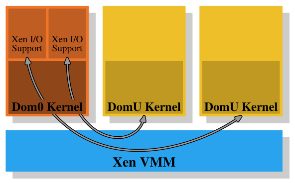

图4.4：Xen虚拟化模型  
Figure 4.4: Xen Virtualization Model

在Xen的情况下（见图4.4），Xen VMM就是这个软件。不过，VMM本身并不实现许多其他的硬件控制。与其他更早系统上的VMM（以及Xen VMM的第一个版本）不同，内存和处理器之外的硬件由特权的Dom0域控制。目前，它基本上与非特权的DomU内核是同一个内核，就内存处理而言，二者没有区别。这里重要的是，VMM把物理内存分发给Dom0和DomU内核，然后这些内核自己实现通常的内存处理，就好像它们直接运行在处理器上一样。

In the case of Xen (see Figure 4.4) the Xen VMM is that piece of software. The VMM does not implement many of the other hardware controls itself, though. Unlike VMMs on other, earlier systems (and the first release of the Xen VMM) the hardware outside of memory and processors is controlled by the privileged Dom0 domain. Currently, this is basically the same kernel as the unprivileged DomU kernels and, as far as memory handling is concerned, they do not differ. Important here is that the VMM hands out physical memory to the Dom0 and DomU kernels which, themselves, then implement the usual memory handling as if they were running directly on a processor.

为了实现完整的虚拟化所需的域间隔离，Dom0和DomU内核中的内存处理并不能不受限制地访问物理内存。VMM不是通过分发单个物理页、让客户操作系统处理寻址来分发内存的；那样无法针对有缺陷的或恶意的客户域提供任何保护。相反，VMM为每个客户域创建自己的页表树，并使用这些数据结构来分发内存。好处是可以控制对页表树管理信息的访问。如果代码没有相应的权限，它就什么也做不了。

To implement the separation of the domains which is required for the virtualization to be complete, the memory handling in the Dom0 and DomU kernels does not have unrestricted access to physical memory. The VMM does not hand out memory by giving out individual physical pages and letting the guest OSes handle the addressing; this would not provide any protection against faulty or rogue guest domains. Instead, the VMM creates its own page table tree for each guest domain and hands out memory using these data structures. The good thing is that access to the administrative information of the page table tree can be controlled. If the code does not have appropriate privileges it cannot do anything.

Xen提供的虚拟化利用了这种访问控制，无论使用的是半虚拟化还是硬件（又称完全）虚拟化。客户域为每个进程构建页表树的方式，对于半虚拟化和硬件虚拟化而言是有意设计得相当相似的。每当客户操作系统修改其页表时，就会调用VMM。然后VMM利用客户域中更新后的信息来更新它自己的影子页表。这些才是硬件实际使用的页表。显然，这个过程代价相当高：页表树的每次修改都需要调用一次VMM。虽然在没有虚拟化的情况下内存映射的改变也不便宜，但现在它们变得更加昂贵了。

This access control is exploited in the virtualization Xen provides, regardless of whether para- or hardware (aka full) virtualization is used. The guest domains construct their page table trees for each process in a way which is intentionally quite similar for para- and hardware virtualization. Whenever the guest OS modifies its page tables the VMM is invoked. The VMM then uses the updated information in the guest domain to update its own shadow page tables. These are the page tables which are actually used by the hardware. Obviously, this process is quite expensive: each modification of the page table tree requires an invocation of the VMM. While changes to the memory mapping are not cheap without virtualization they become even more expensive now.

考虑到从客户操作系统切换到VMM再切换回来本身就已经代价很高，额外的代价可能真的很大。这就是为什么处理器开始具备额外的功能来避免创建影子页表。这不仅出于速度方面的考虑，还因为它减少了VMM的内存消耗。Intel有扩展页表（EPT），AMD称之为嵌套页表（NPT）。基本上，这两种技术都让客户操作系统的页表从“客户虚拟地址”产生“主机虚拟地址”。然后，主机虚拟地址必须使用每个域的EPT/NPT树进一步转换为实际的物理地址。这将使内存处理的速度几乎达到无虚拟化时的水平，因为大多数为处理内存而进入VMM的情形都被消除了。它还减少了VMM的内存使用，因为现在每个域（而不是每个进程）只需维护一棵页表树。

The additional costs can be really large, considering that the changes from the guest OS to the VMM and back themselves are already quite expensive. This is why the processors are starting to have additional functionality to avoid the creation of shadow page tables. This is good not only because of speed concerns but it also reduces memory consumption by the VMM. Intel has Extended Page Tables (EPTs) and AMD calls it Nested Page Tables (NPTs). Basically both technologies have the page tables of the guest OSes produce “host virtual addresses” from the “guest virtual address”. The host virtual addresses must then be further translated, using the per-domain EPT/NPT trees, into actual physical addresses. This will allow memory handling at almost the speed of the no-virtualization case since most VMM entries for memory handling are removed. It also reduces the memory use of the VMM since now only one page table tree for each domain (as opposed to process) has to be maintained.

额外地址转换步骤的结果也存储在TLB中。这意味着TLB存储的不是虚拟物理地址，而是查找的完整结果。前面已经解释过，AMD的Pacifica扩展引入了ASID，以避免每次进入时都刷新TLB。在该处理器扩展的初始版本中，ASID的位数为一位；这刚好足以区分VMM和客户操作系统。Intel有虚拟处理器ID（VPID），用途相同，只是数量更多。但VPID对每个客户域是固定的，因此它也不能用来标记不同的进程、在那个层面上避免TLB刷新。

The results of the additional address translation steps are also stored in the TLB. That means the TLB does not store the virtual physical address but, instead, the complete result of the lookup. It was already explained that AMD’s Pacifica extension introduced the ASID to avoid TLB flushes on each entry. The number of bits for the ASID is one in the initial release of the processor extensions; this is just enough to differentiate VMM and guest OS. Intel has virtual processor IDs (VPIDs) which serve the same purpose, only there are more of them. But the VPID is fixed for each guest domain and therefore it cannot be used to mark separate processes and avoid TLB flushes at that level, too.

每次修改地址空间所需的工作量是虚拟化操作系统的一个问题。不过，基于VMM的虚拟化还有另一个固有的问题：两层内存处理是无法避免的。但内存处理很难（尤其是考虑到NUMA之类的复杂情况时，见第5节）。Xen使用独立VMM的方法使得最优（甚至良好）的处理变得困难，因为内存管理实现的所有复杂之处，包括像发现内存区域这样的“琐碎”事情，都必须在VMM中重复一遍。操作系统已经拥有成熟且经过优化的实现；人们确实希望避免重复它们。

The amount of work needed for each address space modification is one problem with virtualized OSes. There is another problem inherent in VMM-based virtualization, though: there is no way around having two layers of memory handling. But memory handling is hard (especially when taking complications like NUMA into account, see section 5). The Xen approach of using a separate VMM makes optimal (or even good) handling hard since all the complications of a memory management implementation, including “trivial” things like discovery of memory regions, must be duplicated in the VMM. The OSes have fully-fledged and optimized implementations; one really wants to avoid duplicating them.

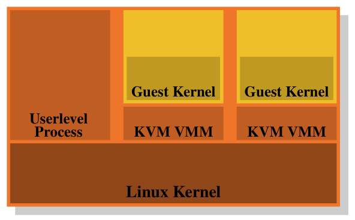

图4.5：KVM虚拟化模型  
Figure 4.5: KVM Virtualization Model

这就是为什么把VMM/Dom0模型贯彻到底是一种如此有吸引力的替代方案。图4.5展示了KVM Linux内核扩展是如何尝试解决这个问题的。没有直接运行在硬件上、控制所有客户的独立VMM；取而代之的是，一个普通的Linux内核接管了这一功能。这意味着Linux内核中完整而成熟的内存处理功能被用来管理系统的内存。客户域与普通的用户级进程一起运行在其创建者所称的“客户模式”中。虚拟化功能——半虚拟化或完全虚拟化——由KVM VMM控制。它只是另一个用户级进程，碰巧使用内核实现的特殊KVM设备来控制一个客户域。

This is why carrying the VMM/Dom0 model to its conclusion is such an attractive alternative. Figure 4.5 shows how the KVM Linux kernel extensions try to solve the problem. There is no separate VMM running directly on the hardware and controlling all the guests; instead, a normal Linux kernel takes over this functionality. This means the complete and sophisticated memory handling functionality in the Linux kernel is used to manage the memory of the system. Guest domains run alongside the normal user-level processes in what the creators call “guest mode”. The virtualization functionality, para- or full virtualization, is controlled by the KVM VMM. This is just another userlevel process which happens to control a guest domain using the special KVM device the kernel implements.

与Xen模型的独立VMM相比，这种模型的好处是，即使使用客户操作系统时仍有两个内存处理程序在工作，也只需要一个实现，即Linux内核中的那个。没有必要在像Xen VMM这样的另一段代码中重复相同的功能。这意味着更少的工作、更少的缺陷，而且也许在两个内存处理程序相接触的地方摩擦也更少，因为Linux客户中的内存处理程序与运行在裸硬件上的外层Linux内核中的内存处理程序作出相同的假设。

The benefit of this model over the separate VMM of the Xen model is that, even though there are still two memory handlers at work when guest OSes are used, there only needs to be one implementation, that in the Linux kernel. It is not necessary to duplicate the same functionality in another piece of code like the Xen VMM. This leads to less work, fewer bugs, and, perhaps, less friction where the two memory handlers touch since the memory handler in a Linux guest makes the same assumptions as the memory handler in the outer Linux kernel which runs on the bare hardware.

总的来说，程序员必须意识到，在使用虚拟化的情况下，缓存未命中（指令、数据或TLB）的代价甚至比没有虚拟化时更高。任何减少这项工作的优化在虚拟化环境中都会带来更大的回报。随着时间的推移，处理器设计者将通过EPT和NPT等技术越来越多地缩小这一差距，但它永远不会完全消失。

Overall, programmers must be aware that, with virtualization used, the cost of cache misses (instruction, data, or TLB) is even higher than without virtualization. Any optimization which reduces this work will pay off even more in virtualized environments. Processor designers will, over time, reduce the difference more and more through technologies like EPT and NPT but it will never completely go away.

[^24]: ↑ x86上的段界限与性能相关，但那是另一回事了。

    ↑ Segment limits on x86 are performance-relevant but that is another story.

## 5 NUMA支持

## 5 NUMA Support

在第2节中我们看到，在某些机器上，访问物理内存特定区域的代价因访问的发起位置而异。这类硬件需要操作系统和应用程序的特别关照。我们将从NUMA硬件的一些细节开始，然后介绍Linux内核为NUMA提供的一些支持。

In section 2 we saw that, on some machines, the cost of access to specific regions of physical memory differs depending on where the access originated. This type of hardware requires special care from the OS and the applications. We will start with a few details of NUMA hardware, then we will cover some of the support the Linux kernel provides for NUMA.

### 5.1 NUMA硬件

### 5.1 NUMA Hardware

非一致内存架构正变得越来越普遍。在最简单的NUMA形式中，处理器可以拥有本地内存（见图2.3），访问它比访问其他处理器的本地内存代价更低。这类NUMA系统的代价差异不大，即NUMA因子较低。

Non-uniform memory architectures are becoming more and more common. In the simplest form of NUMA, a processor can have local memory (see Figure 2.3) which is cheaper to access than memory local to other processors. The difference in cost for this type of NUMA system is not high, i.e., the NUMA factor is low.

NUMA也——而且尤其——用于大型机器。我们已经描述过许多处理器访问同一内存所带来的问题。对于通用硬件，所有处理器都会共享同一个北桥（暂且忽略AMD Opteron的NUMA节点，它们有自己的问题）。这使北桥成为一个严重的瓶颈，因为所有的内存流量都要经过它。大型机器当然可以用定制硬件代替北桥，但除非所用的内存芯片具有多个端口——即它们可以从多条总线上使用——否则仍然存在瓶颈。多端口RAM的制造和支持复杂而昂贵，因此几乎从不使用。

NUMA is also–and especially–used in big machines. We have described the problems of having many processors access the same memory. For commodity hardware all processors would share the same Northbridge (ignoring the AMD Opteron NUMA nodes for now, they have their own problems). This makes the Northbridge a severe bottleneck since all memory traffic is routed through it. Big machines can, of course, use custom hardware in place of the Northbridge but, unless the memory chips used have multiple ports–i.e. they can be used from multiple busses–there still is a bottleneck. Multiport RAM is complicated and expensive to build and support and, therefore, it is hardly ever used.

复杂度更上一层的是AMD所使用的模型，其中一种互连机制（在AMD的情况下是HyperTransport，这是他们从Digital获得许可的技术）为没有直接连接到RAM的处理器提供访问。以这种方式所能构成的结构规模是有限的，除非人们愿意任意增大直径（即任意两个节点之间的最大距离）。

The next step up in complexity is the model AMD uses where an interconnect mechanism (Hyper Transport in AMD’s case, technology they licensed from Digital) provides access for processors which are not directly connected to the RAM. The size of the structures which can be formed this way is limited unless one wants to increase the diameter (i.e., the maximum distance between any two nodes) arbitrarily.

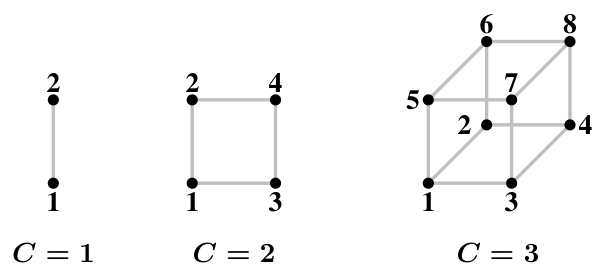

图5.1：超立方体  
Figure 5.1: Hypercubes

连接节点的一种高效拓扑是超立方体，它把节点数限制为2<sup>C</sup>，其中C是每个节点拥有的互连接口数。对于所有拥有2<sup>n</sup>个CPU和n个互连的系统，超立方体的直径最小。图5.1展示了前三个超立方体。每个超立方体的直径为C，这是绝对的最小值。AMD的第一代Opteron处理器每个处理器有三条HyperTransport链路。至少有一个处理器必须在一条链路上连接南桥，这意味着目前可以直接而高效地实现C = 2的超立方体。下一代在某个时候将有四条链路，届时C = 3的超立方体将成为可能。

An efficient topology for connecting the nodes is the hypercube, which limits the number of nodes to 2<sup>C</sup> where C is the number of interconnect interfaces each node has. Hypercubes have the smallest diameter for all systems with 2<sup>n</sup> CPUs and n interconnects. Figure 5.1 shows the first three hypercubes. Each hypercube has a diameter of C which is the absolute minimum. AMD’s first-generation Opteron processors have three hypertransport links per processor. At least one of the processors has to have a Southbridge attached to one link, meaning, currently, that a hypercube with C = 2 can be implemented directly and efficiently. The next generation will at some point have four links, at which point C = 3 hypercubes will be possible.

不过，这并不意味着不能支持更大规模的处理器集合。有些公司已经开发出交叉开关，允许使用更大的处理器集合（例如Newisys的Horus）。但这些交叉开关会增大NUMA因子，并且在处理器数量达到一定程度时就不再有效。

This does not mean, though, that larger accumulations of processors cannot be supported. There are companies which have developed crossbars allowing larger sets of processors to be used (e.g., Newisys’s Horus). But these crossbars increase the NUMA factor and they stop being effective at a certain number of processors.

再上一层意味着把多组CPU连接起来，并为它们全体实现共享内存。所有这类系统都需要专门的硬件，绝不是通用系统。这样的设计存在于若干复杂程度不同的层次上。一个仍然相当接近通用机器的系统是IBM x445及类似机器。它们可以作为普通的4U、8路、使用x86和x86-64处理器的机器购买。然后可以把两台（在某个时候多达四台）这样的机器连接起来，作为一台共享内存的机器工作。所使用的互连引入了显著的NUMA因子，操作系统和应用程序都必须将其考虑在内。

The next step up means connecting groups of CPUs and implementing a shared memory for all of them. All such systems need specialized hardware and are by no means commodity systems. Such designs exist at several levels of complexity. A system which is still quite close to a commodity machine is IBM x445 and similar machines. They can be bought as ordinary 4U, 8-way machines with x86 and x86-64 processors. Two (at some point up to four) of these machines can then be connected to work as a single machine with shared memory. The interconnect used introduces a significant NUMA factor which the OS, as well as applications, must take into account.

在光谱的另一端，像SGI的Altix这样的机器是专门为互连而设计的。SGI的NUMAlink互连结构非常快，同时延迟很低；这两个特性都是高性能计算（HPC）的要求，特别是在使用消息传递接口（MPI）时。缺点当然是，如此精密和专门化的设计非常昂贵。它们使相当低的NUMA因子成为可能，但考虑到这些机器可以拥有的CPU数量（几千个）以及互连的有限容量，NUMA因子实际上是动态的，并且根据工作负载可能达到不可接受的水平。

At the other end of the spectrum, machines like SGI’s Altix are designed specifically to be interconnected. SGI’s NUMAlink interconnect fabric is very fast and has low latency at the same time; both properties are requirements for high-performance computing (HPC), specifically when Message Passing Interfaces (MPI) are used. The drawback is, of course, that such sophistication and specialization is very expensive. They make a reasonably low NUMA factor possible but with the number of CPUs these machines can have (several thousands) and the limited capacity of the interconnects, the NUMA factor is actually dynamic and can reach unacceptable levels depending on the workload.

更常用的是这样的解决方案：用高速网络把许多通用机器连接起来组成集群。不过，它们不是NUMA机器；它们不实现共享地址空间，因此不属于这里讨论的任何类别。

More commonly used are solutions where many commodity machines are connected using high-speed networking to form a cluster. These are no NUMA machines, though; they do not implement a shared address space and therefore do not fall into any category which is discussed here.

### 5.2 操作系统对NUMA的支持

### 5.2 OS Support for NUMA

为了支持NUMA机器，操作系统必须考虑内存的分布式特性。例如，如果一个进程在某个处理器上运行，那么分配给该进程地址空间的物理RAM理想情况下应来自本地内存。否则每条指令都必须为代码和数据访问远程内存。

To support NUMA machines, the OS has to take the distributed nature of the memory into account. For instance, if a process is run on a given processor, the physical RAM assigned to the process’s address space should ideally come from local memory. Otherwise each instruction has to access remote memory for code and data.

有一些只在NUMA机器中才存在的特殊情况需要考虑。DSO的代码段通常在一台机器的物理RAM中只存在一份。但如果该DSO被所有CPU上的进程和线程使用（例如libc这样的基础运行时库），这意味着除少数处理器之外，所有处理器都必须进行远程访问。理想情况下，操作系统会把这样的DSO“镜像”到每个处理器的物理RAM中，并使用本地副本。这是一种优化，而不是必需的，并且一般很难实现。它可能不被支持，或者只以有限的方式支持。

There are special cases to be taken into account which are only present in NUMA machines. The text segment of DSOs is normally present exactly once in a machine’s physical RAM. But if the DSO is used by processes and threads on all CPUs (for instance, the basic runtime libraries like libc) this means that all but a few processors have to have remote accesses. The OS ideally would “mirror” such DSOs into each processor’s physical RAM and use local copies. This is an optimization, not a requirement, and generally hard to implement. It might not be supported or only in a limited fashion.

为了避免情况变得更糟，操作系统不应把进程或线程从一个节点迁移到另一个节点。在普通的多处理器机器上，操作系统就已经应当尽量避免迁移进程，因为从一个处理器迁移到另一个处理器意味着缓存内容丢失。如果负载分配要求把一个进程或线程从某个处理器上迁走，操作系统通常可以任意挑选一个还有足够余力的新处理器。在NUMA环境中，新处理器的选择就受到更多限制。新选择的处理器访问该进程所用内存的代价不应高于旧处理器；这就限制了目标列表。如果没有符合该标准的空闲处理器可用，操作系统别无选择，只能迁移到内存访问代价更高的处理器上。

To avoid making the situation worse, the OS should not migrate a process or thread from one node to another. The OS should already try to avoid migrating processes on normal multi-processor machines because migrating from one processor to another means the cache content is lost. If load distribution requires migrating a process or thread off of a processor, the OS can usually pick an arbitrary new processor which has sufficient capacity left. In NUMA environments the selection of the new processor is a bit more limited. The newly selected processor should not have higher access costs to the memory the process is using than the old processor; this restricts the list of targets. If there is no free processor matching that criteria available, the OS has no choice but to migrate to a processor where memory access is more expensive.

在这种情况下有两条可能的出路。第一，可以寄希望于这种情况是暂时的，进程可以被迁回一个更合适的处理器。或者，操作系统也可以把进程的内存迁移到离新使用的处理器更近的物理页上。这是一个代价相当高的操作。可能有大量内存需要复制，尽管不一定是一步完成。在此期间，进程至少必须短暂停止，以便对旧页的修改能被正确迁移。要使页迁移高效而快速，还有一长串其他要求。简而言之，除非确实必要，操作系统应当避免这样做。

In this situation there are two possible ways forward. First, one can hope the situation is temporary and the process can be migrated back to a better-suited processor. Alternatively, the OS can also migrate the process’s memory to physical pages which are closer to the newly-used processor. This is quite an expensive operation. Possibly huge amounts of memory have to be copied, albeit not necessarily in one step. While this is happening the process, at least briefly, has to be stopped so that modifications to the old pages are correctly migrated. There are a whole list of other requirements for page migration to be efficient and fast. In short, the OS should avoid it unless it is really necessary.

一般来说，不能假设NUMA机器上的所有进程都使用相同数量的内存，从而随着进程在处理器间的分布，内存使用也均匀分布。事实上，除非机器上运行的应用程序非常特定（这在HPC领域很常见，但在其外并非如此），内存使用将非常不均衡。有些应用程序会使用海量内存，另一些则几乎不用。如果内存总是在发起请求的处理器本地分配，这迟早会导致问题。系统最终会耗尽运行大型进程的节点的本地内存。

Generally, it cannot be assumed that all processes on a NUMA machine use the same amount of memory such that, with the distribution of processes across the processors, memory usage is also equally distributed. In fact, unless the applications running on the machines are very specific (common in the HPC world, but not outside) the memory use will be very unequal. Some applications will use vast amounts of memory, others hardly any. This will, sooner or later, lead to problems if memory is always allocated local to the processor where the request is originated. The system will eventually run out of memory local to nodes running large processes.

为了应对这些严重的问题，内存默认不是只在本地节点上分配。为了利用系统的全部内存，默认策略是对内存进行条带化。这保证了系统所有内存的均衡使用。作为一个副作用，在处理器之间自由迁移进程成为可能，因为平均而言，访问所用全部内存的代价不会改变。对于较小的NUMA因子，条带化是可以接受的，但仍不是最优的（见5.4节中的数据）。

In response to these severe problems, memory is, by default, not allocated exclusively on the local node. To utilize all the system’s memory the default strategy is to stripe the memory. This guarantees equal use of all the memory of the system. As a side effect, it becomes possible to freely migrate processes between processors since, on average, the access cost to all the memory used does not change. For small NUMA factors, striping is acceptable but still not optimal (see data in section 5.4).

这是一种悲观化处理，它帮助系统避免严重问题，并使其在正常运行时更可预测。但它确实降低了整体系统性能，在某些情况下降低得很显著。这就是为什么Linux允许每个进程选择内存分配规则。一个进程可以为自己及其子进程选择不同的策略。我们将在第6节介绍可用于此目的的接口。

This is a pessimization which helps the system avoid severe problems and makes it more predictable under normal operation. But it does decrease overall system performance, in some situations significantly. This is why Linux allows the memory allocation rules to be selected by each process. A process can select a different strategy for itself and its children. We will introduce the interfaces which can be used for this in section 6.

### 5.3 公开的信息

### 5.3 Published Information

内核通过sys伪文件系统（sysfs）在以下位置公开有关处理器缓存的信息：

The kernel publishes, through the sys pseudo file system (sysfs), information about the processor caches below

```
/sys/devices/system/cpu/cpu*/cache
```

在6.2.1节中我们将看到可用于查询各级缓存大小的接口。这里重要的是缓存的拓扑。上述目录包含若干子目录（名为`index*`），列出了CPU所拥有的各个缓存的信息。就拓扑而言，这些目录中重要的文件是`type`、`level`和`shared_cpu_map`。对于Intel Core 2 QX6700，信息如表5.1所示。

In section 6.2.1 we will see interfaces which can be used to query the size of the various caches. What is important here is the topology of the caches. The directories above contain subdirectories (named `index*`) which list information about the various caches the CPU possesses. The files `type`, `level`, and `shared_cpu_map` are the important files in these directories as far as the topology is concerned. For an Intel Core 2 QX6700 the information looks as in Table 5.1.

|  |  | type | level | shared_cpu_map |
| --- | --- | --- | --- | --- |
| cpu0 | index0 | Data | 1 | `00000001` |
|  | index1 | Instruction | 1 | `00000001` |
|  | index2 | Unified | 2 | `00000003` |
| cpu1 | index0 | Data | 1 | `00000002` |
|  | index1 | Instruction | 1 | `00000002` |
|  | index2 | Unified | 2 | `00000003` |
| cpu2 | index0 | Data | 1 | `00000004` |
|  | index1 | Instruction | 1 | `00000004` |
|  | index2 | Unified | 2 | `0000000c` |
| cpu3 | index0 | Data | 1 | `00000008` |
|  | index1 | Instruction | 1 | `00000008` |
|  | index2 | Unified | 2 | `0000000c` |

表5.1：Core 2 CPU缓存的sysfs信息  
Table 5.1: sysfs Information for Core 2 CPU Caches

这些数据的含义如下：

What this data means is as follows:

- 每个内核<sup>25</sup>有三个缓存：L1i、L1d、L2。

  Each core<sup>25</sup> has three caches: L1i, L1d, L2.
- L1d和L1i缓存不与任何其他内核共享——每个内核都有自己的一组缓存。这由`shared_cpu_map`中只有一位被置位的位图表示。

  The L1d and L1i caches are not shared with any other core–each core has its own set of caches. This is indicated by the bitmap in `shared_cpu_map` having only one set bit.
- cpu0和cpu1上的L2缓存是共享的，cpu2和cpu3上的L2也是如此。

  The L2 cache on cpu0 and cpu1 is shared, as is the L2 on cpu2 and cpu3.

如果CPU有更多的缓存级别，就会有更多的`index*`目录。

If the CPU had more cache levels, there would be more `index*` directories.

对于一台四插槽、双核的Opteron机器，缓存信息如表5.2所示。可以看出，这些处理器也有三个缓存：L1i、L1d、L2。没有任何内核共享任何级别的缓存。这个系统有趣的部分是处理器拓扑。没有这些额外的信息，就无法理解缓存数据。sys文件系统在以下位置的文件中公开这些信息：

For a four-socket, dual-core Opteron machine the cache information looks like Table 5.2. As can be seen these processors also have three caches: L1i, L1d, L2. None of the cores shares any level of cache. The interesting part for this system is the processor topology. Without this additional information one cannot make sense of the cache data. The sys file system exposes this information in the files below

|  |  | type | level | shared_cpu_map |
| --- | --- | --- | --- | --- |
| cpu0 | index0 | Data | 1 | `00000001` |
|  | index1 | Instruction | 1 | `00000001` |
|  | index2 | Unified | 2 | `00000001` |
| cpu1 | index0 | Data | 1 | `00000002` |
|  | index1 | Instruction | 1 | `00000002` |
|  | index2 | Unified | 2 | `00000002` |
| cpu2 | index0 | Data | 1 | `00000004` |
|  | index1 | Instruction | 1 | `00000004` |
|  | index2 | Unified | 2 | `00000004` |
| cpu3 | index0 | Data | 1 | `00000008` |
|  | index1 | Instruction | 1 | `00000008` |
|  | index2 | Unified | 2 | `00000008` |
| cpu4 | index0 | Data | 1 | `00000010` |
|  | index1 | Instruction | 1 | `00000010` |
|  | index2 | Unified | 2 | `00000010` |
| cpu5 | index0 | Data | 1 | `00000020` |
|  | index1 | Instruction | 1 | `00000020` |
|  | index2 | Unified | 2 | `00000020` |
| cpu6 | index0 | Data | 1 | `00000040` |
|  | index1 | Instruction | 1 | `00000040` |
|  | index2 | Unified | 2 | `00000040` |
| cpu7 | index0 | Data | 1 | `00000080` |
|  | index1 | Instruction | 1 | `00000080` |
|  | index2 | Unified | 2 | `00000080` |

表5.2：Opteron CPU缓存的sysfs信息  
Table 5.2: sysfs Information for Opteron CPU Caches

```
/sys/devices/system/cpu/cpu*/topology
```

表5.3展示了这台SMP Opteron机器在此层次结构中值得关注的文件。

Table 5.3 shows the interesting files in this hierarchy for the SMP Opteron machine.

|  | physical_ package_id | core_id | core_ siblings | thread_ siblings |
| --- | --- | --- | --- | --- |
| cpu0 | 0 | 0 | `00000003` | `00000001` |
| cpu1 | 0 | 1 | `00000003` | `00000002` |
| cpu2 | 1 | 0 | `0000000c` | `00000004` |
| cpu3 | 1 | 1 | `0000000c` | `00000008` |
| cpu4 | 2 | 0 | `00000030` | `00000010` |
| cpu5 | 2 | 1 | `00000030` | `00000020` |
| cpu6 | 3 | 0 | `000000c0` | `00000040` |
| cpu7 | 3 | 1 | `000000c0` | `00000080` |

表5.3：Opteron CPU拓扑的sysfs信息  
Table 5.3: sysfs Information for Opteron CPU Topology

把表5.2和表5.3放在一起，我们可以看出

Taking Table 5.2 and Table 5.3 together we can see that

1. 没有任何CPU有超线程（`thread_siblings`位图只有一位被置位），

   none of the CPU has hyper-threads (the `thread_siblings` bitmaps have one bit set),
2. 该系统实际上共有四个处理器（`physical_package_id`为0到3），

   the system in fact has a total of four processors (`physical_package_id` 0 to 3),
3. 每个处理器有两个内核，以及

   each processor has two cores, and
4. 没有任何内核共享任何缓存。

   none of the cores share any cache.

这正好对应于较早的Opteron。

This is exactly what corresponds to earlier Opterons.

到目前为止所提供的数据中完全缺失的，是有关这台机器NUMA性质的信息。任何SMP Opteron机器都是NUMA机器。对于这些数据，我们必须查看sys文件系统中存在于NUMA机器上的另一部分，即以下位置的层次结构：

What is completely missing in the data provided so far is information about the nature of NUMA on this machine. Any SMP Opteron machine is a NUMA machine. For this data we have to look at yet another part of the sys file system which exists on NUMA machines, namely in the hierarchy below

```
/sys/devices/system/node
```

这个目录为系统上的每个NUMA节点包含一个子目录。在各节点专属的目录中有若干文件。对于前两个表所描述的Opteron机器，重要的文件及其内容如表5.4所示。

This directory contains a subdirectory for every NUMA node on the system. In the node-specific directories there are a number of files. The important files and their content for the Opteron machine described in the previous two tables are shown in Table 5.4.

|  | cpumap | distance |
| --- | --- | --- |
| node0 | `00000003` | `10 20 20 20` |
| node1 | `0000000c` | `20 10 20 20` |
| node2 | `00000030` | `20 20 10 20` |
| node3 | `000000c0` | `20 20 20 10` |

表5.4：Opteron节点的sysfs信息  
Table 5.4: sysfs Information for Opteron Nodes

这些信息把其余的一切联系在了一起；现在我们对这台机器的架构有了完整的了解。我们已经知道这台机器有四个处理器。从`node*`目录中`cpumap`文件的值中被置位的位可以看出，每个处理器构成自己的节点。这些目录中的`distance`文件包含一组值，每个节点一个，表示在相应节点上进行内存访问的代价。在这个例子中，所有本地内存访问的代价为10，所有对任何其他节点的远程访问代价为20。<sup>26</sup>这意味着，即使处理器被组织成一个二维超立方体（见图5.1），没有直接连接的处理器之间的访问也并不更贵。代价的相对值应该可以用作对访问时间实际差异的估计。所有这些信息的准确性是另一个问题。

This information ties all the rest together; now we have a complete picture of the architecture of the machine. We already know that the machine has four processors. Each processor constitutes its own node as can be seen by the bits set in the value in `cpumap` file in the `node*` directories. The `distance` files in those directories contains a set of values, one for each node, which represent a cost of memory accesses at the respective nodes. In this example all local memory accesses have the cost 10, all remote access to any other node has the cost 20.<sup>26</sup> This means that, even though the processors are organized as a two-dimensional hypercube (see Figure 5.1), accesses between processors which are not directly connected is not more expensive. The relative values of the costs should be usable as an estimate of the actual difference of the access times. The accuracy of all this information is another question.

### 5.4 远程访问的代价

### 5.4 Remote Access Costs

不过，距离是有意义的。在[1]中，AMD记录了一台四插槽机器的NUMA代价。写操作的数字如图5.3所示。写比读慢，这并不奇怪。有趣的部分是1跳和2跳情况的代价。两种1跳情况的代价实际上略有不同。详见[1]。我们需要从这张图中记住的事实是：2跳的读和写分别比0跳读慢30%和49%。2跳写比0跳写慢32%，比1跳写慢17%。处理器与内存节点的相对位置可能造成很大的差异。AMD的下一代处理器将为每个处理器配备四条一致性HyperTransport链路。在那种情况下，四插槽机器的直径将为一。如果有八个插槽，同样的问题将变本加厉地卷土重来，因为八节点超立方体的直径为三。

The distance is relevant, though. In [1] AMD documents the NUMA cost of a four socket machine. For write operations the numbers are shown in Figure 5.3. Writes are slower than reads, this is no surprise. The interesting parts are the costs of the 1- and 2-hop cases. The two 1-hop cases actually have slightly different costs. See [1] for the details. The fact we need to remember from this chart is that 2-hop reads and writes are 30% and 49% (respectively) slower than 0-hop reads. 2-hop writes are 32% slower than 0-hop writes, and 17% slower than 1-hop writes. The relative position of processor and memory nodes can make a big difference. The next generation of processors from AMD will feature four coherent HyperTransport links per processor. In that case a four socket machine would have diameter of one. With eight sockets the same problem returns, with a vengeance, since the diameter of a hypercube with eight nodes is three.

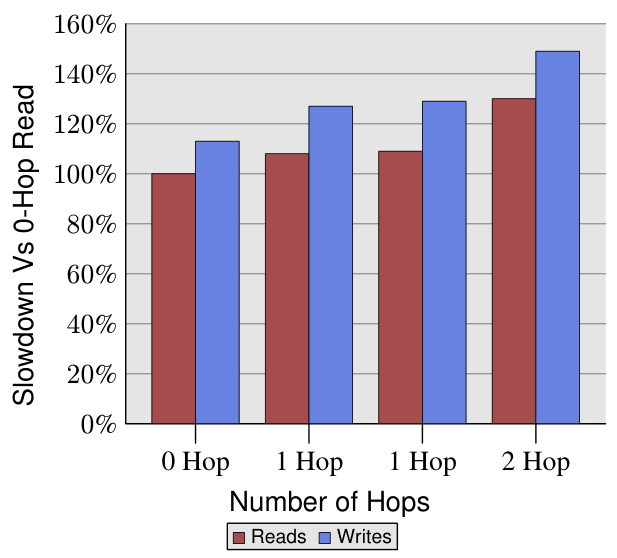

图5.3：多节点下的读/写性能  
Figure 5.3: Read/Write Performance with Multiple Nodes  
X轴：跳数；Y轴：相对0跳读的变慢程度。Reads=读，Writes=写。

所有这些信息都是可以获得的，但使用起来很麻烦。在6.5节中我们将看到一个有助于更容易地访问和使用这些信息的接口。

All this information is available but it is cumbersome to use. In section 6.5 we will see an interface which helps accessing and using this information easier.

系统提供的最后一项信息在于进程本身的状态。可以确定内存映射文件、写时复制（COW）<sup>27</sup>页以及匿名内存是如何分布在系统中各节点上的。对于每个进程，内核提供一个伪文件`/proc/PID/numa_maps`，其中PID是进程的ID，如图5.2所示。文件中重要的信息是N0到N3的值，它们表示该内存区域在节点0到3上分配的页数。可以很有把握地猜测，该程序是在节点3上的一个内核上执行的。程序本身和被弄脏的页都分配在该节点上。只读映射，例如`ld-2.4.so`和`libc-2.4.so`的第一个映射，以及共享文件`locale-archive`，则分配在其他节点上。

The last piece of information the system provides is in the status of a process itself. It is possible to determine how the memory-mapped files, the Copy-On-Write (COW)<sup>27</sup> pages and anonymous memory are distributed over the nodes in the system. For each process the kernel provides a pseudo-file `/proc/PID/numa_maps`, where PID is the ID of the process, as shown in Figure 5.2. The important information in the file is the values for N0 to N3, which indicate the number of pages allocated for the memory area on nodes 0 to 3. It is a good guess that the program was executed on a core on node 3. The program itself and the dirtied pages are allocated on that node. Read-only mappings, such as the first mapping for `ld-2.4.so` and `libc-2.4.so` as well as the shared file `locale-archive` are allocated on other nodes.

```
00400000 default file=/bin/cat mapped=3 N3=3
00504000 default file=/bin/cat anon=1 dirty=1 mapped=2 N3=2
00506000 default heap anon=3 dirty=3 active=0 N3=3
38a9000000 default file=/lib64/ld-2.4.so mapped=22 mapmax=47 N1=22
38a9119000 default file=/lib64/ld-2.4.so anon=1 dirty=1 N3=1
38a911a000 default file=/lib64/ld-2.4.so anon=1 dirty=1 N3=1
38a9200000 default file=/lib64/libc-2.4.so mapped=53 mapmax=52 N1=51 N2=2
38a933f000 default file=/lib64/libc-2.4.so
38a943f000 default file=/lib64/libc-2.4.so anon=1 dirty=1 mapped=3 mapmax=32 N1=2 N3=1
38a9443000 default file=/lib64/libc-2.4.so anon=1 dirty=1 N3=1
38a9444000 default anon=4 dirty=4 active=0 N3=4
2b2bbcdce000 default anon=1 dirty=1 N3=1
2b2bbcde4000 default anon=2 dirty=2 N3=2
2b2bbcde6000 default file=/usr/lib/locale/locale-archive mapped=11 mapmax=8 N0=11
7fffedcc7000 default stack anon=2 dirty=2 N3=2
```

图5.2：/proc/PID/numa_maps的内容  
Figure 5.2: Content of /proc/PID/numa_maps

正如我们在图5.3中看到的，跨节点进行时，1跳和2跳读的读性能分别下降9%和30%。对于执行而言，这样的读是必需的，如果L2缓存未命中，每个缓存行都会产生这些额外的代价。如果内存对处理器而言是远程的，那么对于超出缓存大小的大型工作负载所测得的所有代价都必须增加9%/30%。

As we have seen in Figure 5.3, when performed across nodes the read performance falls by 9% and 30% respectively for 1- and 2-hop reads. For execution, such reads are needed and, if the L2 cache is missed, each cache line incurs these additional costs. All the costs measured for large workloads beyond the size of the cache would have to be increased by 9%/30% if the memory is remote to the processor.

为了观察现实世界中的效果，我们可以像3.5.1节那样测量带宽，但这一次内存位于一跳之外的远程节点上。与使用本地内存的数据相比，这项测试的结果可以在图5.4中看到。这些数字在两个方向上都有几个大的尖峰，这是测量多线程代码的问题造成的，可以忽略。这张图中的重要信息是，读操作总是慢20%。这比图5.3中的9%要慢得多，后者很可能不是针对不间断读/写操作的数字，并且可能适用于较旧的处理器版本。只有AMD知道。

To see the effects in the real world we can measure the bandwidth as in section 3.5.1 but this time with the memory being on a remote node, one hop away. The result of this test when compared with the data for using local memory can be seen in Figure 5.4. The numbers have a few big spikes in both directions which are the result of a problem of measuring multi-threaded code and can be ignored. The important information in this graph is that read operations are always 20% slower. This is significantly slower than the 9% in Figure 5.3, which is, most likely, not a number for uninterrupted read/write operations and might refer to older processor revisions. Only AMD knows.

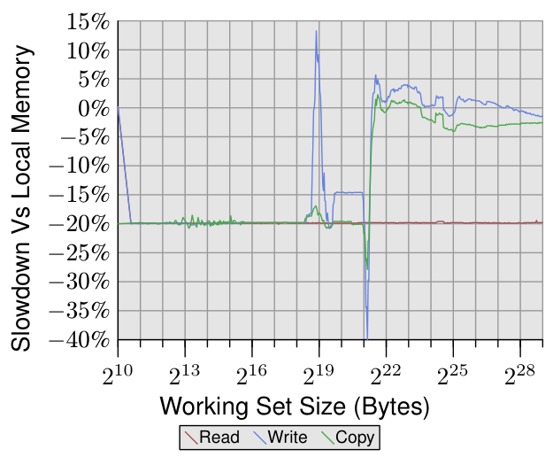

图5.4：操作远程内存  
Figure 5.4: Operating on Remote Memory  
Y轴：相对本地内存的变慢程度。Read=读，Write=写，Copy=复制。

对于能放进缓存的工作集大小，写和复制操作的性能也慢20%。对于超出缓存大小的工作集，写性能与在本地节点上的操作相比并没有可测量的变慢。互连的速度足以跟上内存。主导因素是等待主存所花费的时间。

For working set sizes which fit into the caches, the performance of write and copy operations is also 20% slower. For working sets exceeding the size of the caches, the write performance is not measurably slower than the operation on the local node. The speed of the interconnect is fast enough to keep up with the memory. The dominating factor is the time spent waiting on the main memory.

[^25]: ↑ cpu0到cpu3是内核这一认识来自另一个地方，稍后会加以解释。

    ↑ The knowledge that cpu0 to cpu3 are cores comes from another place that will be explained shortly.
[^26]: ↑ 顺便说一句，这是不正确的。ACPI信息显然是错误的，因为尽管所用的处理器有三条一致性HyperTransport链路，但至少有一个处理器必须连接到南桥。因此至少有一对节点的距离必然更大。

    ↑ This is, by the way, incorrect. The ACPI information is apparently wrong since, although the processors used have three coherent HyperTransport links, at least one processor must be connected to a Southbridge. At least one pair of nodes must therefore have a larger distance.
[^27]: ↑ 写时复制是操作系统实现中经常使用的一种方法：一个内存页起初只有一个使用者，之后为了允许独立的使用者而必须复制它。在许多情况下，复制是不必要的——完全不必要或起初不必要——这时只在任一使用者修改内存时才复制是合理的。操作系统拦截写操作，复制内存页，然后允许写指令继续执行。

    ↑ Copy-On-Write is a method often used in OS implementations when a memory page has one user at first and then has to be copied to allow independent users. In many situations the copying is unnecessary, at all or at first, in which case it makes sense to only copy when either user modifies the memory. The operating system intercepts the write operation, duplicates the memory page, and then allows the write instruction to proceed.

## 6 程序员能做些什么

## 6 What Programmers Can Do

经过前面各节的描述，很明显，程序员有许许多多的机会去影响程序的性能，无论是正面的还是负面的。而这还仅仅是与内存相关的操作。我们将从最底层开始逐一介绍这些机会，从物理RAM访问和L1缓存这些最低层次开始，一直到并包括影响内存处理的操作系统功能。

After the descriptions in the previous sections it is clear that there are many, many opportunities for programmers to influence a program’s performance, positively or negatively. And this is for memory-related operations only. We will proceed in covering the opportunities from the ground up, starting with the lowest levels of physical RAM access and L1 caches, up to and including OS functionality which influences memory handling.

### 6.1 绕过缓存

### 6.1 Bypassing the Cache

当数据被产生出来而不会（立即）再被消费时，内存存储操作先读取完整的缓存行再修改缓存数据这一事实对性能是有害的。这一操作会把可能还会再次需要的数据挤出缓存，换进不会很快被使用的数据。对于矩阵这样的大型数据结构尤其如此，它们先被填充，稍后才被使用。在矩阵的最后一个元素被填充之前，其庞大的规模就已经把最前面的元素逐出了，使得对写操作的缓存毫无效果。

When data is produced and not (immediately) consumed again, the fact that memory store operations read a full cache line first and then modify the cached data is detrimental to performance. This operation pushes data out of the caches which might be needed again in favor of data which will not be used soon. This is especially true for large data structures, like matrices, which are filled and then used later. Before the last element of the matrix is filled the sheer size evicts the first elements, making caching of the writes ineffective.

针对这种以及类似的情况，处理器提供了对非临时（non-temporal）写操作的支持。这里的“非临时”是指数据不会很快被重用，因此没有理由缓存它。这些非临时写操作不会先读取缓存行再修改它；相反，新内容被直接写入内存。

For this and similar situations, processors provide support for non-temporal write operations. Non-temporal in this context means the data will not be reused soon, so there is no reason to cache it. These non-temporal write operations do not read a cache line and then modify it; instead, the new content is directly written to memory.

这听起来可能代价很高，但其实不一定。处理器会尝试使用写合并（见3.3.3节）来填满整个缓存行。如果成功，就完全不需要内存读操作。对于x86和x86-64架构，gcc提供了若干内建函数（intrinsic）：

This might sound expensive but it does not have to be. The processor will try to use write-combining (see section 3.3.3) to fill entire cache lines. If this succeeds no memory read operation is needed at all. For the x86 and x86-64 architectures a number of intrinsics are provided by gcc:

```c
#include <emmintrin.h>
void _mm_stream_si32(int *p, int a);
void _mm_stream_si128(int *p, __m128i a);
void _mm_stream_pd(double *p, __m128d a);

#include <xmmintrin.h>
void _mm_stream_pi(__m64 *p, __m64 a);
void _mm_stream_ps(float *p, __m128 a);

#include <ammintrin.h>
void _mm_stream_sd(double *p, __m128d a);
void _mm_stream_ss(float *p, __m128 a);
```

如果这些指令一次性处理大量数据，使用效率最高。数据从内存加载，经过一个或多个步骤的处理，然后写回内存。数据“流”过处理器，这些内建函数的名称由此而来。

These instructions are used most efficiently if they process large amounts of data in one go. Data is loaded from memory, processed in one or more steps, and then written back to memory. The data “streams” through the processor, hence the names of the intrinsics.

内存地址必须分别按8字节或16字节对齐。在使用多媒体扩展的代码中，可以用这些非临时版本替换普通的`_mm_store_*`内建函数。在A.1节的矩阵乘法代码中我们没有这样做，因为写入的值会在很短的时间内被重用。这是一个使用流式指令并无益处的例子。关于这段代码的更多内容见6.2.1节。

The memory address must be aligned to 8 or 16 bytes respectively. In code using the multimedia extensions it is possible to replace the normal `_mm_store_*` intrinsics with these non-temporal versions. In the matrix multiplication code in section A.1 we do not do this since the written values are reused in a short order of time. This is an example where using the stream instructions is not useful. More on this code in section 6.2.1.

处理器的写合并缓冲区只能在有限的时间内保存对缓存行部分写入的请求。通常有必要把修改同一缓存行的所有指令一条接一条地发出，以便写合并能够真正发生。下面是一个如何做到这一点的例子：

The processor’s write-combining buffer can hold requests for partial writing to a cache line for only so long. It is generally necessary to issue all the instructions which modify a single cache line one after another so that the write-combining can actually take place. An example for how to do this is as follows:

```c
#include <emmintrin.h>
void setbytes(char *p, int c)
{
  __m128i i = _mm_set_epi8(c, c, c, c,
                           c, c, c, c,
                           c, c, c, c,
                           c, c, c, c);
  _mm_stream_si128((__m128i *)&p[0], i);
  _mm_stream_si128((__m128i *)&p[16], i);
  _mm_stream_si128((__m128i *)&p[32], i);
  _mm_stream_si128((__m128i *)&p[48], i);
}
```

假设指针`p`已正确对齐，调用这个函数将把所寻址缓存行的所有字节都设置为`c`。写合并逻辑会看到生成的四条`movntdq`指令，并且只在最后一条指令执行完之后才向内存发出写命令。总而言之，这段代码序列不仅避免了在写入之前读取缓存行，还避免了用可能不会很快需要的数据污染缓存。在某些情况下这能带来巨大的好处。使用这种技术的日常代码的一个例子是C运行时中的`memset`函数，对于大块内存它应当使用类似上面的代码序列。

Assuming the pointer `p` is appropriately aligned, a call to this function will set all bytes of the addressed cache line to `c`. The write-combining logic will see the four generated `movntdq` instructions and only issue the write command for the memory once the last instruction has been executed. To summarize, this code sequence not only avoids reading the cache line before it is written, it also avoids polluting the cache with data which might not be needed soon. This can have huge benefits in certain situations. An example of everyday code using this technique is the `memset` function in the C runtime, which should use a code sequence like the above for large blocks.

有些架构提供了专门的解决方案。PowerPC架构定义了`dcbz`指令，可以用来清零整个缓存行。该指令并没有真正绕过缓存，因为会为结果分配一个缓存行，但不会从内存读取任何数据。它比非临时存储指令更受限制，因为缓存行只能被全部置零，并且它会污染缓存（在数据是非临时的情况下），但实现这一结果不需要任何写合并逻辑。

Some architectures provide specialized solutions. The PowerPC architecture defines the `dcbz` instruction which can be used to clear an entire cache line. The instruction does not really bypass the cache since a cache line is allocated for the result, but no data is read from memory. It is more limited than the non-temporal store instructions since a cache line can only be set to all-zeros and it pollutes the cache (in case the data is non-temporal), but no write-combining logic is needed to achieve the results.

为了观察非临时指令的实际效果，我们来看一个新的测试，用于测量对按二维数组组织的矩阵的写入。编译器在内存中这样排列矩阵：最左边的（第一个）索引寻址行，行内所有元素在内存中顺序排列。右边的（第二个）索引寻址行内的元素。测试程序以两种方式遍历矩阵：第一种是在内层循环中递增列号，第二种是在内层循环中递增行索引。这意味着我们得到图6.1所示的行为。

To see the non-temporal instructions in action we will look at a new test which is used to measure writing to a matrix, organized as a two-dimensional array. The compiler lays out the matrix in memory so that the leftmost (first) index addresses the row which has all elements laid out sequentially in memory. The right (second) index addresses the elements in a row. The test program iterates over the matrix in two ways: first by increasing the column number in the inner loop and then by increasing the row index in the inner loop. This means we get the behavior shown in Figure 6.1.

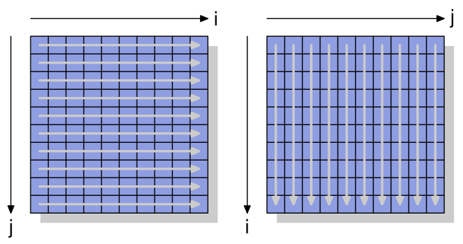

图6.1：矩阵访问模式  
Figure 6.1: Matrix Access Pattern

我们测量初始化一个3000 × 3000矩阵所需的时间。为了观察内存的行为，我们使用不经过缓存的存储指令。在IA-32处理器上，为此使用“非临时提示”。作为对比，我们也测量普通的存储操作。结果见表6.1。

We measure the time it takes to initialize a 3000 × 3000 matrix. To see how memory behaves, we use store instructions which do not use the cache. On IA-32 processors the “non-temporal hint” is used for this. For comparison we also measure ordinary store operations. The results can be seen in Table 6.1.

|  | 内层循环递增 Inner Loop Increment 行 Row | 内层循环递增 Inner Loop Increment 列 Column |
| --- | --- | --- |
| 普通 Normal | 0.048s | 0.127s |
| 非临时 Non-Temporal | 0.048s | 0.160s |

表6.1：矩阵初始化计时  
Table 6.1: Timing Matrix Initialization

对于使用缓存的普通写入，我们看到了预期的结果：如果顺序地使用内存，我们会得到好得多的结果，整个操作耗时0.048s，相当于约750MB/s；相比之下，或多或少随机的访问耗时0.127s（约280MB/s）。矩阵足够大，以至于缓存基本上失效了。

For the normal writes which do use the cache we see the expected result: if memory is used sequentially we get a much better result, 0.048s for the whole operation translating to about 750MB/s, compared to the more-or-less random access which takes 0.127s (about 280MB/s). The matrix is large enough that the caches are essentially ineffective.

我们这里主要感兴趣的是绕过缓存的写入。可能令人惊讶的是，这里的顺序访问与使用缓存的情况一样快。得到这一结果的原因是处理器如上所述执行了写合并。此外，非临时写入的内存排序规则是放宽的：程序需要显式地插入内存屏障（对于x86和x86-64处理器是`sfence`指令）。这意味着处理器在写回数据时有更大的自由，从而可以尽可能充分地利用可用带宽。

The part we are mainly interested in here are the writes bypassing the cache. It might be surprising that the sequential access is just as fast here as in the case where the cache is used. The reason for this result is that the processor is performing write-combining as explained above. In addition, the memory ordering rules for non-temporal writes are relaxed: the program needs to explicitly insert memory barriers (`sfence` instructions for the x86 and x86-64 processors). This means the processor has more freedom to write back the data and thereby using the available bandwidth as well as possible.

在内层循环中按列访问的情况就不同了。不经缓存的访问结果明显慢于经缓存访问的情况（0.16s，约225MB/s）。这里我们可以看到，写合并是不可能的，每个存储单元都必须单独寻址。这需要不断地在RAM芯片中选择新的行，并伴随所有相关的延迟。结果比经缓存的运行差25%。

In the case of column-wise access in the inner loop the situation is different. The results for uncached accesses are significantly slower than in the case of cached accesses (0.16s, about 225MB/s). Here we can see that no write combining is possible and each memory cell must be addressed individually. This requires constantly selecting new rows in the RAM chips with all the associated delays. The result is a 25% worse result than the cached run.

在读的一侧，直到最近，处理器除了使用非临时访问（NTA）预取指令给出的弱提示之外，一直缺乏支持。对于读，没有与写合并等价的机制，这对于内存映射I/O之类的不可缓存内存尤其糟糕。Intel在SSE4.1扩展中引入了NTA加载。它们是用少量的流式加载缓冲区实现的；每个缓冲区容纳一个缓存行。针对给定缓存行的第一条`movntdqa`指令会把一个缓存行加载到缓冲区中，可能替换掉另一个缓存行。随后对同一缓存行的16字节对齐访问将以很小的代价由加载缓冲区提供服务。除非有其他理由，该缓存行不会被加载到缓存中，从而可以加载大量内存而不污染缓存。编译器为这条指令提供了一个内建函数：

On the read side, processors, until recently, lacked support aside from weak hints using non-temporal access (NTA) prefetch instructions. There is no equivalent to write-combining for reads, which is especially bad for uncacheable memory such as memory-mapped I/O. Intel, with the SSE4.1 extensions, introduced NTA loads. They are implemented using a small number of streaming load buffers; each buffer contains a cache line. The first `movntdqa` instruction for a given cache line will load a cache line into a buffer, possibly replacing another cache line. Subsequent 16-byte aligned accesses to the same cache line will be serviced from the load buffer at little cost. Unless there are other reasons to do so, the cache line will not be loaded into a cache, thus enabling the loading of large amounts of memory without polluting the caches. The compiler provides an intrinsic for this instruction:

```c
#include <smmintrin.h>
__m128i _mm_stream_load_si128 (__m128i *p);
```

这个内建函数应当被多次使用，以16字节块的地址作为参数传入，直到读完每个缓存行。只有在那之后才应开始下一个缓存行。由于有几个流式读缓冲区，可能可以同时从两个内存位置读取。

This intrinsic should be used multiple times, with addresses of 16-byte blocks passed as the parameter, until each cache line is read. Only then should the next cache line be started. Since there are a few streaming read buffers it might be possible to read from two memory locations at once.

我们应当从这个实验中得出的是：现代CPU能够非常好地优化不经缓存的写访问，以及最近甚至读访问，只要它们是顺序的。在处理只使用一次的大型数据结构时，这一认识会非常有用。其次，缓存可以帮助掩盖随机内存访问的部分——但不是全部——代价。在这个例子中，由于RAM访问的实现方式，随机访问要慢70%。在实现改变之前，应当尽可能避免随机访问。

What we should take away from this experiment is that modern CPUs very nicely optimize uncached write and more recently even read accesses as long as they are sequential. This knowledge can come in very handy when handling large data structures which are used only once. Second, caches can help to cover up some–but not all–of the costs of random memory access. Random access in this example is 70% slower due to the implementation of RAM access. Until the implementation changes, random accesses should be avoided whenever possible.

在关于预取的那一节中，我们将再次讨论非临时标志。

In the section about prefetching we will again take a look at the non-temporal flag.

### 6.2 缓存访问

### 6.2 Cache Access

希望提高程序性能的程序员会发现，最好把精力集中在影响一级缓存的改动上，因为这些改动很可能带来最好的结果。我们将首先讨论它，然后再把讨论扩展到其他级别。显然，所有针对一级缓存的优化也会影响其他缓存。所有内存访问的主题都是一样的：提高局部性（空间局部性和时间局部性），并对齐代码和数据。

Programmers wishing to improve their programs’ performance will find it best to focus on changes affected the level 1 cache since those will likely yield the best results. We will discuss it first before extending the discussion to the other levels. Obviously, all the optimizations for the level 1 cache also affect the other caches. The theme for all memory access is the same: improve locality (spatial and temporal) and align the code and data.

#### 6.2.1 优化一级数据缓存访问

#### 6.2.1 Optimizing Level 1 Data Cache Access

在3.3节中我们已经看到，有效地使用L1d缓存能在多大程度上提高性能。在本节中，我们将展示哪些类型的代码改动有助于提高这一性能。接续上一节，我们首先集中讨论顺序访问内存的优化。正如3.3节中的数字所示，当顺序访问内存时，处理器会自动预取数据。

In section section 3.3 we have already seen how much the effective use of the L1d cache can improve performance. In this section we will show what kinds of code changes can help to improve that performance. Continuing from the previous section, we first concentrate on optimizations to access memory sequentially. As seen in the numbers of section 3.3, the processor automatically prefetches data when memory is accessed sequentially.

所用的示例代码是矩阵乘法。我们使用两个1000 × 1000的`double`元素方阵。对于那些已经忘了数学的人：给定两个矩阵A和B，其元素为*a*<sub>*ij*</sub>和*b*<sub>*ij*</sub>，0 ≤ *i*, *j* < *N*，其乘积为

The example code used is a matrix multiplication. We use two square matrices of 1000 × 1000 `double` elements. For those who have forgotten the math, given two matrices A and B with elements *a*<sub>*ij*</sub> and *b*<sub>*ij*</sub> with 0 ≤ *i*, *j* < *N* the product is

$$(AB)ij=∑k=0N−1aikbkj=ai1b1j+ai2b2j+⋯+ai(N−1)b(N−1)j$$

一个直截了当的C实现可能看起来像这样：

A straight-forward C implementation of this can look like this:

```c
for (i = 0; i < N; ++i)
  for (j = 0; j < N; ++j)
    for (k = 0; k < N; ++k)
      res[i][j] += mul1[i][k] * mul2[k][j];
```

两个输入矩阵是`mul1`和`mul2`。结果矩阵`res`假定已被初始化为全零。这是一个优美而简单的实现。但很明显，我们恰好遇到了图6.1所解释的问题。`mul1`是顺序访问的，而内层循环推进的是`mul2`的行号。这意味着`mul1`像图6.1中左边的矩阵那样被处理，而`mul2`像右边的矩阵那样被处理。这不可能好。

The two input matrices are `mul1` and `mul2`. The result matrix `res` is assumed to be initialized to all zeroes. It is a nice and simple implementation. But it should be obvious that we have exactly the problem explained in Figure 6.1. While `mul1` is accessed sequentially, the inner loop advances the row number of `mul2`. That means that `mul1` is handled like the left matrix in Figure 6.1 while `mul2` is handled like the right matrix. This cannot be good.

有一个很容易尝试的补救办法。由于矩阵中的每个元素都被访问多次，在使用第二个矩阵`mul2`之前对其进行重新排列（用数学术语说就是“转置”）可能是值得的。

There is one possible remedy one can easily try. Since each element in the matrices is accessed multiple times it might be worthwhile to rearrange (“transpose,” in mathematical terms) the second matrix `mul2` before using it.

$$(AB)ij=∑k=0N−1aikbjkT=ai1bj1T+ai2bj2T+⋯+ai(N−1)bj(N−1)T$$

转置之后（传统上用上标“T”表示），我们现在顺序地遍历两个矩阵。就C代码而言，现在它看起来像这样：

After the transposition (traditionally indicated by a superscript ‘T’) we now iterate over both matrices sequentially. As far as the C code is concerned, it now looks like this:

```c
double tmp[N][N];
for (i = 0; i < N; ++i)
  for (j = 0; j < N; ++j)
    tmp[i][j] = mul2[j][i];
for (i = 0; i < N; ++i)
  for (j = 0; j < N; ++j)
    for (k = 0; k < N; ++k)
      res[i][j] += mul1[i][k] * tmp[j][k];
```

我们创建一个临时变量来存放转置后的矩阵。这需要接触额外的内存，但这一代价有望得到补偿，因为每列1000次非顺序访问的代价更高（至少在现代硬件上如此）。是时候做些性能测试了。在时钟频率为2666MHz的Intel Core 2上，结果如下（以时钟周期计）：

We create a temporary variable to contain the transposed matrix. This requires touching additional memory, but this cost is, hopefully, recovered since the 1000 non-sequential accesses per column are more expensive (at least on modern hardware). Time for some performance tests. The results on a Intel Core 2 with 2666MHz clock speed are (in clock cycles):

|  | 原始 Original | 转置 Transposed |
| --- | --- | --- |
| 周期数 Cycles | 16,765,297,870 | 3,922,373,010 |
| 相对值 Relative | 100% | 23.4% |

通过对矩阵的简单变换，我们获得了76.6%的加速！复制操作的代价被绰绰有余地弥补了。那1000次非顺序访问真的很伤性能。

Through the simple transformation of the matrix we can achieve a 76.6% speed-up! The copy operation is more than made up. The 1000 non-sequential accesses really hurt.

下一个问题是这是否是我们能做到的最好结果。无论如何，我们当然需要一种不要求额外复制的替代方法。我们不会总是有条件进行复制：矩阵可能太大，或者可用内存太小。

The next question is whether this is the best we can do. We certainly need an alternative method anyway which does not require the additional copy. We will not always have the luxury to be able to perform the copy: the matrix can be too large or the available memory too small.

寻找替代实现应当从仔细审视所涉及的数学以及原始实现所执行的操作开始。基本的数学知识就能让我们看出，只要每个加数恰好出现一次，结果矩阵每个元素的加法执行顺序就无关紧要。<sup>28</sup>这一认识使我们可以寻找对原始代码内层循环中所执行的加法重新排序的解决方案。

The search for an alternative implementation should start with a close examination of the math involved and the operations performed by the original implementation. Trivial math knowledge allows us to see that the order in which the additions for each element of the result matrix are performed is irrelevant as long as each addend appears exactly once.<sup>28</sup> This understanding allows us to look for solutions which reorder the additions performed in the inner loop of the original code.

现在我们来考察原始代码执行中的实际问题。`mul2`元素被访问的顺序是：(0,0)、(1,0)、……、(N-1,0)、(0,1)、(1,1)、……。元素(0,0)和(0,1)位于同一缓存行中，但到内层循环完成一轮时，这个缓存行早已被逐出了。在这个例子中，内层循环的每一轮对三个矩阵中的每一个都需要1000个缓存行（对于Core 2处理器，每个64字节）。加起来远远超过可用的32k L1d。

Now let us examine the actual problem in the execution of the original code. The order in which the elements of `mul2` are accessed is: (0,0), (1,0), ..., (N-1,0), (0,1), (1,1), . . . . The elements (0,0) and (0,1) are in the same cache line but, by the time the inner loop completes one round, this cache line has long been evicted. For this example, each round of the inner loop requires, for each of the three matrices, 1000 cache lines (with 64 bytes for the Core 2 processor). This adds up to much more than the 32k of L1d available.

但如果我们在执行内层循环的同时一起处理中层循环的两次迭代呢？在这种情况下，我们使用来自那个保证位于L1d中的缓存行的两个`double`值。我们把L1d未命中率减半了。这当然是一个改进，但根据缓存行的大小，这可能仍不是我们能做到的最好。Core 2处理器的L1d缓存行大小为64字节。实际值可以在运行时用

But what if we handle two iterations of the middle loop together while executing the inner loop? In this case we use two `double` values from the cache line which is guaranteed to be in L1d. We cut the L1d miss rate in half. That is certainly an improvement, but, depending on the cache line size, it still might not be as good as we can get it. The Core 2 processor has a L1d cache line size of 64 bytes. The actual value can be queried using

```c
sysconf (_SC_LEVEL1_DCACHE_LINESIZE)
```

查询，或者在命令行上使用`getconf`工具查询，以便为特定的缓存行大小编译程序。由于`sizeof(double)`为8，这意味着为了充分利用缓存行，我们应当把中层循环展开8次。顺着这个思路，为了也有效地使用`res`矩阵，即同时写入8个结果，我们也应当把外层循环展开8次。这里我们假设缓存行大小为64，但这段代码在缓存行为32字节的系统上也能很好地工作，因为两个缓存行也都被100%地利用了。一般来说，最好在编译时使用`getconf`工具把缓存行大小硬编码进去，例如：

at runtime or using the `getconf` utility from the command line so that the program can be compiled for a specific cache line size. With `sizeof(double)` being 8 this means that, to fully utilize the cache line, we should unroll the middle loop 8 times. Continuing this thought, to effectively use the `res` matrix as well, i.e., to write 8 results at the same time, we should unroll the outer loop 8 times as well. We assume here cache lines of size 64 but the code works also well on systems with 32 byte cache lines since both cache lines are also 100% utilized. In general it is best to hardcode cache line sizes at compile time by using the `getconf` utility as in:

```
gcc -DCLS=$(getconf LEVEL1_DCACHE_LINESIZE) ...
```

如果二进制文件应当是通用的，就应当使用最大的缓存行大小。对于非常小的L1d，这可能意味着并非所有数据都能放进缓存，但这样的处理器本来就不适合高性能程序。我们得到的代码大致如下：

If the binaries are supposed to be generic, the largest cache line size should be used. With very small L1ds this might mean that not all the data fits into the cache but such processors are not suitable for high-performance programs anyway. The code we arrive at looks something like this:

```c
#define SM (CLS / sizeof (double))

for (i = 0; i < N; i += SM)
  for (j = 0; j < N; j += SM)
    for (k = 0; k < N; k += SM)
      for (i2 = 0, rres = &res[i][j],
           rmul1 = &mul1[i][k]; i2 < SM;
           ++i2, rres += N, rmul1 += N)
        for (k2 = 0, rmul2 = &mul2[k][j];
             k2 < SM; ++k2, rmul2 += N)
          for (j2 = 0; j2 < SM; ++j2)
            rres[j2] += rmul1[k2] * rmul2[j2];
```

这看起来相当吓人。在某种程度上确实如此，但只是因为它包含了一些技巧。最明显的变化是我们现在有六重嵌套循环。外层循环以`SM`（缓存行大小除以`sizeof(double)`）为间隔进行迭代。这把乘法划分为若干个较小的问题，可以以更好的缓存局部性来处理。内层循环遍历外层循环缺失的那些索引。同样，这里有三个循环。这里唯一棘手的部分是`k2`和`j2`循环的顺序不同。这样做是因为在实际计算中，只有一个表达式依赖于`k2`，而有两个依赖于`j2`。

This looks quite scary. To some extent it is but only because it incorporates some tricks. The most visible change is that we now have six nested loops. The outer loops iterate with intervals of `SM` (the cache line size divided by `sizeof(double)`). This divides the multiplication in several smaller problems which can be handled with more cache locality. The inner loops iterate over the missing indexes of the outer loops. There are, once again, three loops. The only tricky part here is that the `k2` and `j2` loops are in a different order. This is done since, in the actual computation, only one expression depends on `k2` but two depend on `j2`.

其余的复杂之处源于这样一个事实：在优化数组索引方面，gcc并不十分聪明。引入额外的变量`rres`、`rmul1`和`rmul2`，通过把公共表达式尽可能地提到内层循环之外来优化代码。C和C++语言默认的别名规则并不能帮助编译器作出这些决定（除非使用`restrict`，否则所有指针访问都是潜在的别名来源）。这就是为什么Fortran仍是数值编程的首选语言：用它更容易写出快速的代码。<sup>29</sup>

The rest of the complication here results from the fact that gcc is not very smart when it comes to optimizing array indexing. The introduction of the additional variables `rres`, `rmul1`, and `rmul2` optimizes the code by pulling common expressions out of the inner loops, as far down as possible. The default aliasing rules of the C and C++ languages do not help the compiler making these decisions (unless `restrict` is used, all pointer accesses are potential sources of aliasing). This is why Fortran is still a preferred language for numeric programming: it makes writing fast code easier.<sup>29</sup>

|  | 原始 Original | 转置 Transposed | 子矩阵 Sub-Matrix | 向量化 Vectorized |
| --- | --- | --- | --- | --- |
| 周期数 Cycles | 16,765,297,870 | 3,922,373,010 | 2,895,041,480 | 1,588,711,750 |
| 相对值 Relative | 100% | 23.4% | 17.3% | 9.47% |

表6.2：矩阵乘法计时  
Table 6.2: Matrix Multiplication Timing

所有这些工作带来了怎样的回报，可以从表6.2中看到。通过避免复制，我们又获得了6.1%的性能。而且，我们不需要任何额外的内存。只要结果矩阵也能放进内存，输入矩阵就可以任意大。这是对通用解决方案的要求，我们现在已经做到了。

How all this work pays off can be seen in Table 6.2. By avoiding the copying we gain another 6.1% of performance. Plus, we do not need any additional memory. The input matrices can be arbitrarily large as long as the result matrix fits into memory as well. This is a requirement for a general solution which we have now achieved.

我们在矩阵乘法的例子中所优化的，是对已加载缓存行的使用。缓存行的所有字节总是被使用的。我们只是确保在缓存行被腾出之前使用它们。这当然是一种特殊情况。

What we optimized in the example of the matrix multiplication is the use of the loaded cache lines. All bytes of a cache line are always used. We just made sure they are used before the cache line is evacuated. This is certainly a special case.

更常见的情况是，数据结构填满一个或多个缓存行，而程序在任一时刻只使用其中少数几个成员。在图3.11中我们已经看到，如果只使用少数成员，大的结构尺寸会带来怎样的影响。

It is much more common to have data structures which fill one or more cache lines where the program uses only a few members at any one time. In Figure 3.11 we have already seen the effects of large structure sizes if only few members are used.

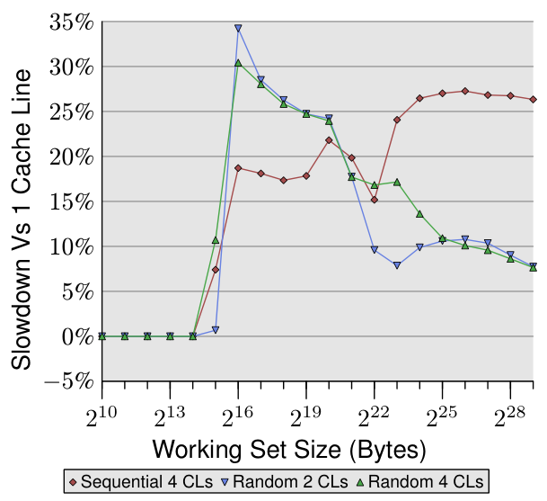

图6.2：分散在多个缓存行上  
Figure 6.2: Spreading Over Multiple Cache Lines  
Y轴：相对1个缓存行的变慢程度。Sequential 4 CLs=顺序、4个缓存行；Random 2/4 CLs=随机、2/4个缓存行。

图6.2显示了使用那个如今已广为人知的程序进行的又一组基准测试的结果。这一次，把同一链表元素的两个值相加。在一种情况下，两个元素位于同一缓存行中；在另一种情况下，一个元素位于链表元素的第一个缓存行中，另一个位于最后一个缓存行中。该图显示了我们所经历的变慢。

Figure 6.2 shows the results of yet another set of benchmarks performed using the by now well-known program. This time two values of the same list element are added. In one case, both elements are in the same cache line; in another case, one element is in the first cache line of the list element and the second is in the last cache line. The graph shows the slowdown we are experiencing.

不出所料，在所有情况下，如果工作集能放进L1d，就没有负面影响。一旦L1d不再足够，在过程中使用两个缓存行而不是一个就要付出代价。红线显示的是链表在内存中顺序排列时的数据。我们看到了通常的两级台阶模式：当L2缓存足够时约17%的代价，当必须使用主存时约27%的代价。

Unsurprisingly, in all cases there are no negative effects if the working set fits into L1d. Once L1d is no longer sufficient, penalties are paid by using two cache lines in the process instead of one. The red line shows the data when the list is laid out sequentially in memory. We see the usual two step patterns: about 17% penalty when the L2 cache is sufficient and about 27% penalty when the main memory has to be used.

在随机内存访问的情况下，相对数据看起来有些不同。对于能放进L2的工作集，变慢在25%到35%之间。超出之后，它下降到大约10%。这并不是因为代价变小了，而是因为实际的内存访问代价不成比例地变得更高。数据还表明，在某些情况下，元素之间的距离确实很重要。Random 4 CLs曲线显示出更高的代价，因为使用的是第一个和第四个缓存行。

In the case of random memory accesses the relative data looks a bit different. The slowdown for working sets which fit into L2 is between 25% and 35%. Beyond that it goes down to about 10%. This is not because the penalties get smaller but, instead, because the actual memory accesses get disproportionally more costly. The data also shows that, in some cases, the distance between the elements does matter. The Random 4 CLs curve shows higher penalties because the first and fourth cache lines are used.

查看数据结构相对于缓存行布局的一个简便方法是使用`pahole`程序（见[4]）。这个程序检查二进制文件中定义的数据结构。以一个包含如下定义的程序为例：

An easy way to see the layout of a data structure compared to cache lines is to use the `pahole` program (see [4]). This program examines the data structures defined in a binary. Take a program containing this definition:

```c
struct foo {
  int a;
  long fill[7];
  int b;
};
```

```c
struct foo {
        int                        a;                    /*     0     4 */

        /* XXX 4 bytes hole, try to pack */

        long int                   fill[7];              /*     8    56 */
        /* --- cacheline 1 boundary (64 bytes) --- */
        int                        b;                    /*    64     4 */
}; /* size: 72, cachelines: 2 */
   /* sum members: 64, holes: 1, sum holes: 4 */
   /* padding: 4 */
   /* last cacheline: 8 bytes */
```

图6.3：pahole运行的输出  
Figure 6.3: Output of pahole Run

在64位机器上编译时，`pahole`的输出包含（除其他内容外）图6.3所示的输出。这一输出告诉了我们很多信息。首先，它表明该数据结构用掉了不止一个缓存行。该工具假定使用当前处理器的缓存行大小，但这个值可以用命令行参数覆盖。尤其是在结构的大小刚刚超过缓存行界限、并且分配了大量这种类型对象的情况下，设法压缩该结构是有意义的。也许有几个元素可以使用更小的类型，或者有些字段实际上是标志，可以用单独的位来表示。

When compiled on a 64-bit machine, the output of `pahole` contains (among other things) the output shown in Figure 6.3. This output tells us a lot. First, it shows that the data structure uses up more than one cache line. The tool assumes the currently used processor’s cache line size, but this value can be overridden using a command line parameter. Especially in cases where the size of the structure is barely over the limit of a cache line, and many objects of this type are allocated, it makes sense to seek a way to compress that structure. Maybe a few elements can have a smaller type, or maybe some fields are actually flags which can be represented using individual bits.

在这个例子中，压缩很容易，而且程序也给出了提示。输出显示，在第一个元素之后有一个四字节的空洞。这个空洞是由结构和`fill`元素的对齐要求造成的。很容易看出，大小为四字节的元素`b`（由该行末尾的4表示）正好能放进这个空隙。这样做的结果是空隙不复存在，数据结构可以放进一个缓存行。`pahole`工具自己就能执行这项优化。如果使用`--reorganize`参数，并在命令行末尾加上结构名，工具的输出就是优化后的结构及其缓存行使用情况。除了移动元素来填补空隙之外，该工具还可以优化位字段，并合并填充和空洞。更多细节见[4]。

In the case of the example the compression is easy and it is hinted at by the program. The output shows that there is a hole of four bytes after the first element. This hole is caused by the alignment requirement of the structure and the `fill` element. It is easy to see that the element `b`, which has a size of four bytes (indicated by the 4 at the end of the line), fits perfectly into the gap. The result in this case is that the gap no longer exists and that the data structure fits onto one cache line. The `pahole` tool can perform this optimization itself. If the `--reorganize` parameter is used and the structure name is added at the end of the command line the output of the tool is the optimized structure and the cache line use. Besides moving elements to fill gaps, the tool can also optimize bit fields and combine padding and holes. For more details see [4].

有一个刚好足够容纳末尾元素的空洞当然是理想情况。要使这一优化有用，要求对象本身按缓存行对齐。我们稍后会谈到这一点。

Having a hole which is just large enough for the trailing element is, of course, the ideal situation. For this optimization to be useful it is required that the object itself is aligned to a cache line. We get to that in a bit.

`pahole`的输出还可以让人很容易地看出是否需要对元素重新排序，以便一起使用的元素也被存放在一起。使用`pahole`工具，可以很容易地确定哪些元素位于同一缓存行上，以及何时需要重新调整元素来做到这一点。这不是一个自动化的过程，但该工具可以提供相当大的帮助。

The `pahole` output also allows to see easily whether elements have to be reordered so that those elements which are used together are also stored together. Using the `pahole` tool, it is easily possible to determine which elements are on the same cache line and when, instead, the elements have to be reshuffled to achieve that. This is not an automatic process but the tool can help quite a bit.

各个结构元素的位置及其使用方式也很重要。正如我们在3.5.2节中看到的，关键字位于缓存行靠后位置的代码性能更差。这意味着程序员应当始终遵循以下两条规则：

The position of the individual structure elements and the way they are used is important, too. As we have seen in section 3.5.2 the performance of code with the critical word late in the cache line is worse. This means a programmer should always follow the following two rules:

1. 总是把最可能成为关键字的结构元素移到结构的开头。

   Always move the structure element which is most likely to be the critical word to the beginning of the structure.
2. 访问数据结构时，如果访问顺序不受情况所限，就按照元素在结构中定义的顺序访问它们。

   When accessing the data structures, and the order of access is not dictated by the situation, access the elements in the order in which they are defined in the structure.

对于小结构，这意味着元素应当按照它们可能被访问的顺序排列。这必须灵活处理，以便也能应用其他优化，例如填补空洞。对于较大的数据结构，每个缓存行大小的块都应当按照这些规则来安排。

For small structures, this means that the elements should be arranged in the order in which they are likely accessed. This must be handled in a flexible way to allow the other optimizations, such as filling holes, to be applied as well. For bigger data structures each cache line-sized block should be arranged to follow the rules.

不过，如果对象本身没有按预期对齐，重新排序元素就不值得花这个时间。对象的对齐由数据类型的对齐要求决定。每种基本类型都有自己的对齐要求。对于结构化类型，其任一元素中最大的对齐要求决定了该结构的对齐。这几乎总是小于缓存行大小。这意味着，即使结构的成员被排列得能放进同一个缓存行，分配出来的对象也可能不具有与缓存行大小相匹配的对齐。有两种方法可以确保对象具有设计结构布局时所采用的对齐：

If the object itself is not aligned as expected, reordering elements is not worth the time it takes, though. The alignment of an object is determined by the alignment requirement of the data type. Each fundamental type has its own alignment requirement. For structured types the largest alignment requirement of any of its elements determines the alignment of the structure. This is almost always smaller than the cache line size. This means even if the members of a structure are lined up to fit into the same cache line an allocated object might not have an alignment matching the cache line size. There are two ways to ensure that the object has the alignment which was used when designing the layout of the structure:

- 可以用显式的对齐要求来分配对象。对于动态分配，调用`malloc`只会以与要求最高的标准类型（通常是`long double`）相匹配的对齐来分配对象。不过，可以使用`posix_memalign`来请求更高的对齐。

  the object can be allocated with an explicit alignment requirement. For dynamic allocation a call to `malloc` would only allocate the object with an alignment matching that of the most demanding standard type (usually `long double`). It is possible to use `posix_memalign`, though, to request higher alignments.

  ```c
  #include <stdlib.h>
  int posix_memalign(void **memptr,
                     size_t align,
                     size_t size);
  ```

  该函数把指向新分配内存的指针存入`memptr`所指向的指针变量中。内存块的大小为`size`字节，并按`align`字节边界对齐。

  The function stores a pointer pointing to the newly-allocated memory in the pointer variable pointed to by `memptr`. The memory block is `size` bytes in size and is aligned on a `align`-byte boundary.

  对于由编译器分配的对象（在`.data`、`.bss`等中以及栈上），可以使用变量属性：

  For objects allocated by the compiler (in `.data`, `.bss`, etc, and on the stack) a variable attribute can be used:

  ```c
  struct strtype variable
     __attribute((aligned(64)));
  ```

  在这种情况下，无论`strtype`结构的对齐要求如何，该变量都按64字节边界对齐。这对全局变量和自动变量都适用。

  In this case the variable is aligned at a 64 byte boundary regardless of the alignment requirement of the `strtype` structure. This works for global variables as well as automatic variables.

  对于数组，这种方法并不像人们可能预期的那样起作用。除非每个数组元素的大小是对齐值的倍数，否则只有数组的第一个元素会被对齐。这也意味着每一个变量都必须被适当地标注。使用`posix_memalign`也并非完全没有代价，因为对齐要求通常会导致碎片和/或更高的内存消耗。

  For arrays this method does not work as one might expect. Only the first element of the array would be aligned unless the size of each array element is a multiple of the alignment value. It also means that every single variable must be annotated appropriately. The use of `posix_memalign` is also not entirely free since the alignment requirements usually lead to fragmentation and/or higher memory consumption.
- 可以使用类型属性来改变用户定义类型的对齐要求：

  the alignment requirement of a user-defined type can be changed by using a type attribute:

  ```c
  struct strtype {
    ...members...
  } __attribute((aligned(64)));
  ```

  这将使编译器以适当的对齐来分配所有对象，包括数组。不过，对于动态分配的对象，程序员必须负责请求适当的对齐。这里同样必须使用`posix_memalign`。使用gcc提供的`alignof`运算符并把其值作为第二个参数传给`posix_memalign`是很容易的。

  This will cause the compiler to allocate all objects with the appropriate alignment, including arrays. The programmer has to take care of requesting the appropriate alignment for dynamically allocated objects, though. Here once again `posix_memalign` must be used. It is easy enough to use the `alignof` operator gcc provides and pass the value as the second parameter to `posix_memalign`.

本节前面提到的多媒体扩展几乎总是要求内存访问是对齐的。也就是说，对于16字节的内存访问，地址应当是16字节对齐的。x86和x86-64处理器有能够处理非对齐访问的特殊内存操作变体，但它们更慢。这种硬性的对齐要求对于大多数RISC架构来说并不新鲜，它们要求所有内存访问都完全对齐。即使一种架构支持非对齐访问，这有时也比使用适当的对齐更慢，尤其是当未对齐导致一次加载或存储要使用两个缓存行而不是一个时。

The multimedia extensions previously mentioned in this section almost always require that the memory accesses are aligned. I.e., for 16 byte memory accesses the address is supposed to be 16 byte aligned. The x86 and x86-64 processors have special variants of the memory operations which can handle unaligned accesses but these are slower. This hard alignment requirement is nothing new for most RISC architectures which require full alignment for all memory accesses. Even if an architecture supports unaligned accesses this is sometimes slower than using appropriate alignment, especially if the misalignment causes a load or store to use two cache lines instead of one.

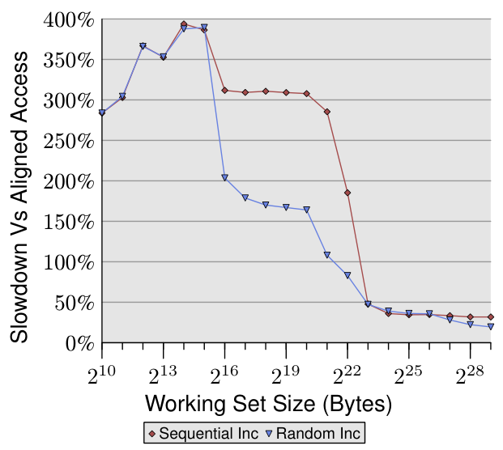

图6.4：非对齐访问的开销  
Figure 6.4: Overhead of Unaligned Accesses  
Y轴：相对对齐访问的变慢程度。Sequential Inc=顺序加一，Random Inc=随机加一。

图6.4显示了非对齐内存访问的影响。测量的是那些如今已广为人知的、在访问内存（顺序或随机地）时对数据元素加一的测试，一次使用对齐的链表元素，一次使用故意未对齐的元素。该图显示了程序因非对齐访问而产生的变慢。顺序访问情况下的影响比随机情况更显著，因为在后一种情况下，非对齐访问的代价部分地被通常更高的内存访问代价所掩盖。在顺序的情况下，对于能放进L2缓存的工作集大小，变慢约为300%。这可以用L1缓存有效性的降低来解释。现在一些加一操作会触及两个缓存行，开始处理一个链表元素现在常常需要读取两个缓存行。L1与L2之间的连接实在太拥挤了。

Figure 6.4 shows the effects of unaligned memory accesses. The now well-known tests which increment a data element while visiting memory (sequentially or randomly) are measured, once with aligned list elements and once with deliberately misaligned elements. The graph shows the slowdown the program incurs because of the unaligned accesses. The effects are more dramatic for the sequential access case than for the random case because, in the latter case, the costs of unaligned accesses are partially hidden by the generally higher costs of the memory access. In the sequential case, for working set sizes which do fit into the L2 cache, the slowdown is about 300%. This can be explained by the reduced effectiveness of the L1 cache. Some increment operations now touch two cache lines, and beginning work on a list element now often requires reading of two cache lines. The connection between L1 and L2 is simply too congested.

对于非常大的工作集，非对齐访问的影响仍有20%到30%——考虑到这些大小下对齐访问的时间本来就很长，这是很多的。这张图应当表明，对齐必须被认真对待。即使架构支持非对齐访问，也绝不能把它当作“与对齐访问一样好”。

For very large working set sizes, the effects of the unaligned access are still 20% to 30%–which is a lot given that the aligned access time for those sizes is long. This graph should show that alignment must be taken seriously. Even if the architecture supports unaligned accesses, this must not be taken as “they are as good as aligned accesses”.

不过，这些对齐要求也有一些副作用。如果一个自动变量有对齐要求，编译器就必须确保在所有情况下都满足它。这并不简单，因为编译器无法控制调用点以及它们处理栈的方式。这个问题可以用两种方法处理：

There is some fallout from these alignment requirements, though. If an automatic variable has an alignment requirement, the compiler has to ensure that it is met in all situations. This is not trivial since the compiler has no control over the call sites and the way they handle the stack. This problem can be handled in two ways:

1. 生成的代码主动对齐栈，必要时插入间隙。这需要代码来检查对齐、建立对齐，并在之后撤销对齐。

   The generated code actively aligns the stack, inserting gaps if necessary. This requires code to check for alignment, create alignment, and later undo the alignment.
2. 要求所有调用者都对齐栈。

   Require that all callers have the stack aligned.

所有常用的应用程序二进制接口（ABI）都遵循第二条路线。如果调用者违反了这条规则而被调用者又需要对齐，程序很可能会失败。不过，保持对齐并不是没有代价的。

All of the commonly used application binary interfaces (ABIs) follow the second route. Programs will likely fail if a caller violates the rule and alignment is needed in the callee. Keeping alignment intact does not come for free, though.

函数所用栈帧的大小不一定是对齐值的倍数。这意味着如果从这个栈帧调用其他函数，就需要填充。最大的区别在于，在大多数情况下编译器知道栈帧的大小，因此它知道如何调整栈指针，以确保从该栈帧调用的任何函数都能满足对齐。事实上，大多数编译器会简单地把栈帧大小向上取整，然后就完事了。

The size of a stack frame used in a function is not necessarily a multiple of the alignment. This means padding is needed if other functions are called from this stack frame. The big difference is that the stack frame size is, in most cases, known to the compiler and, therefore, it knows how to adjust the stack pointer to ensure alignment for any function which is called from that stack frame. In fact, most compilers will simply round the stack frame size up and be done with it.

如果使用了变长数组（VLA）或`alloca`，这种处理对齐的简单方法就行不通了。在这种情况下，栈帧的总大小只有在运行时才知道。这时可能需要主动的对齐控制，使生成的代码（稍微）变慢。

This simple way to handle alignment is not possible if variable length arrays (VLAs) or `alloca` are used. In that case, the total size of the stack frame is only known at runtime. Active alignment control might be needed in this case, making the generated code (slightly) slower.

在某些架构上，只有多媒体扩展需要严格对齐；这些架构上的栈对于普通数据类型总是最低限度地对齐的，对于32位和64位架构通常分别是4字节或8字节对齐。在这些系统上，强制对齐会带来不必要的代价。这意味着，在这种情况下，如果我们知道从未依赖于严格的对齐要求，我们可能希望去掉它。不做多媒体操作的尾函数（即不调用其他函数的函数）不需要对齐。只调用不需要对齐的函数的函数也不需要。如果能找出足够大的一组函数，程序可能会希望放宽对齐要求。对于x86二进制文件，gcc支持放宽的栈对齐要求：

On some architectures, only the multimedia extensions require strict alignment; stacks on those architectures are always minimally aligned for the normal data types, usually 4 or 8 byte alignment for 32- and 64-bit architectures respectively. On these systems, enforcing the alignment incurs unnecessary costs. That means that, in this case, we might want to get rid of the strict alignment requirement if we know that it is never depended upon. Tail functions (those which call no other functions) which do no multimedia operations do not need alignment. Neither do functions which only call functions which need no alignment. If a large enough set of functions can be identified, a program might want to relax the alignment requirement. For x86 binaries gcc has support for relaxed stack alignment requirements:

```
-mpreferred-stack-boundary=2
```

如果给这个选项一个值N，栈对齐要求将被设置为2<sup>N</sup>字节。因此，如果使用值2，栈对齐要求就从默认值（16字节）降低到仅4字节。在大多数情况下，这意味着不需要额外的对齐操作，因为普通的栈压入和弹出操作本来就以四字节为边界工作。这个机器特定的选项有助于减小代码尺寸，也能提高执行速度。但它不能应用于许多其他架构。即使对于x86-64，它一般也不适用，因为x86-64 ABI要求浮点参数通过SSE寄存器传递，而SSE指令要求完整的16字节对齐。尽管如此，只要该选项可用，它就可能带来明显的差异。

If this option is given a value of N, the stack alignment requirement will be set to 2<sup>N</sup> bytes. So, if a value of 2 is used, the stack alignment requirement is reduced from the default (which is 16 bytes) to just 4 bytes. In most cases this means no additional alignment operation is needed since normal stack push and pop operations work on four-byte boundaries anyway. This machine-specific option can help to reduce code size and also improve execution speed. But it cannot be applied for many other architectures. Even for x86-64 it is generally not applicable since the x86-64 ABI requires that floating-point parameters are passed in an SSE register and the SSE instructions require full 16 byte alignment. Nevertheless, whenever the option is usable it can make a noticeable difference.

结构元素的高效布局和对齐并不是影响缓存效率的数据结构的唯一方面。如果使用结构数组，整个结构定义都会影响性能。还记得图3.11中的结果：在那种情况下，数组元素中未使用的数据越来越多。结果是预取越来越无效，对于大数据集，程序变得越来越低效。

Efficient placement of structure elements and alignment are not the only aspects of data structures which influence cache efficiency. If an array of structures is used, the entire structure definition affects performance. Remember the results in Figure 3.11: in this case we had increasing amounts of unused data in the elements of the array. The result was that prefetching was increasingly less effective and the program, for large data sets, became less efficient.

对于大型工作集，尽可能好地使用可用的缓存是很重要的。为此，可能有必要重新安排数据结构。虽然对程序员来说，把概念上属于一体的所有数据放在同一个数据结构中更容易，但这可能不是获得最高性能的最佳方法。假设我们有如下数据结构：

For large working sets it is important to use the available cache as well as possible. To achieve this, it might be necessary to rearrange data structures. While it is easier for the programmer to put all the data which conceptually belongs together in the same data structure, this might not be the best approach for maximum performance. Assume we have a data structure as follows:

```c
struct order {
  double price;
  bool paid;
  const char *buyer[5];
  long buyer_id;
};
```

再假设这些记录存储在一个大数组中，并且有一个经常运行的作业要把所有未付账单的预期付款加起来。在这种场景下，用于`buyer`和`buyer_id`字段的内存被不必要地加载到了缓存中。根据图3.11中的数据判断，程序的性能可能比它本可以达到的差多达5倍。

Further assume that these records are stored in a big array and that a frequently-run job adds up the expected payments of all the outstanding bills. In this scenario, the memory used for the `buyer` and `buyer_id` fields is unnecessarily loaded into the caches. Judging from the data in Figure 3.11 the program will perform up to 5 times worse than it could.

把`order`数据结构拆成两部分要好得多：把前两个字段存放在一个结构中，把其他字段存放在别处。这一改动无疑增加了程序的复杂性，但性能上的收益可能证明这一代价是值得的。

It is much better to split the `order` data structure in two pieces, storing the first two fields in one structure and the other fields elsewhere. This change certainly increases the complexity of the program, but the performance gains might justify this cost.

最后，让我们考虑另一种缓存使用优化，它虽然也适用于其他缓存，但主要体现在L1d访问上。正如图3.8所示，提高缓存的相联度有利于正常运行。缓存越大，相联度通常就越高。L1d缓存太大，不可能是全相联的，但又不够大，无法拥有与L2缓存相同的相联度。如果工作集中的许多对象落入同一个缓存组，这就可能成为问题。如果这导致因某个组被过度使用而发生逐出，即使大部分缓存都未被使用，程序也可能遭遇延迟。这些缓存未命中有时称为冲突未命中。由于L1d的寻址使用虚拟地址，这实际上是程序员可以控制的事情。如果一起使用的变量也被存放在一起，它们落入同一组的可能性就会降到最低。图6.5显示了这个问题来得有多快。

Finally, let us consider another cache use optimization which, while also applying to the other caches, is primarily felt in the L1d access. As seen in Figure 3.8 an increased associativity of the cache benefits normal operation. The larger the cache, the higher the associativity usually is. The L1d cache is too large to be fully associative but not large enough to have the same associativity as L2 caches. This can be a problem if many of the objects in the working set fall into the same cache set. If this leads to evictions due to overuse of a set, the program can experience delays even though much of the cache is unused. These cache misses are sometimes called *conflict misses*. Since the L1d addressing uses virtual addresses, this is actually something the programmer can have control over. If variables which are used together are also stored together the likelihood of them falling into the same set is minimized. Figure 6.5 shows how quickly the problem can hit.

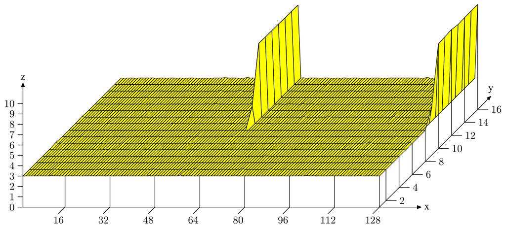

图6.5：缓存相联度效应  
Figure 6.5: Cache Associativity Effects  
x：元素间距离（以空元素计）；y：链表长度；z：每元素平均周期数。

在该图中，如今已熟悉的NPAD=15的Follow<sup>30</sup>测试在一种特殊设置下被测量。X轴是两个链表元素之间的距离，以空链表元素为单位度量。换句话说，距离为2意味着下一个元素的地址在前一个元素之后128字节处。所有元素在虚拟地址空间中都以相同的距离排列。Y轴显示链表的总长度。只使用1到16个元素，这意味着总工作集大小为64到1024字节。z轴显示遍历每个链表元素所需的平均周期数。

In the figure, the now familiar Follow<sup>30</sup> with NPAD=15 test is measured with a special setup. The X–axis is the distance between two list elements, measured in empty list elements. In other words, a distance of 2 means that the next element’s address is 128 bytes after the previous one. All elements are laid out in the virtual address space with the same distance. The Y–axis shows the total length of the list. Only one to 16 elements are used, meaning that the total working set size is 64 to 1024 bytes. The z–axis shows the average number of cycles needed to traverse each list element.

图中所示的结果应该不会令人惊讶。如果使用的元素很少，所有数据都能放进L1d，访问时间每个链表元素只有3个周期。对于链表元素几乎所有的排列方式都是如此：虚拟地址被很好地映射到L1d槽位上，几乎没有冲突。有两个（在这张图中）特殊的距离值，情况有所不同。如果距离是4096字节的倍数（即距离为64个元素），并且链表长度大于八，每个链表元素的平均周期数就会急剧增加。在这些情况下，所有条目都位于同一组中，一旦链表长度大于相联度，条目就会被从L1d中刷出，下一轮必须从L2重新读取。这导致每个链表元素约10个周期的代价。

The result shown in the figure should not be surprising. If few elements are used, all the data fits into L1d and the access time is only 3 cycles per list element. The same is true for almost all arrangements of the list elements: the virtual addresses are nicely mapped to L1d slots with almost no conflicts. There are two (in this graph) special distance values for which the situation is different. If the distance is a multiple of 4096 bytes (i.e., distance of 64 elements) and the length of the list is greater than eight, the average number of cycles per list element increases dramatically. In these situations all entries are in the same set and, once the list length is greater than the associativity, entries are flushed from L1d and have to be re-read from L2 the next round. This results in the cost of about 10 cycles per list element.

通过这张图，我们可以确定所用处理器的L1d缓存相联度为8，总大小为32kB。这意味着，如果有必要，这个测试可以用来确定这些值。同样的效应也可以在L2缓存上测量到，但在那里更为复杂，因为L2缓存使用物理地址索引，而且大得多。

With this graph we can determine that the processor used has an L1d cache with associativity 8 and a total size of 32kB. That means that the test could, if necessary, be used to determine these values. The same effects can be measured for the L2 cache but, here, it is more complex since the L2 cache is indexed using physical addresses and it is much larger.

希望程序员能把这些数据看作一个信号：组相联度是值得关注的。在现实世界中，把数据布置在2的幂次边界上的情况经常发生，但这恰恰是很容易导致上述效应和性能下降的情形。非对齐访问可能会增加冲突未命中的概率，因为每次访问可能需要额外的一个缓存行。

Programmers will hopefully see this data as an indication that set associativity is something worth paying attention to. Laying out data at boundaries that are powers of two happens often enough in the real world, but this is exactly the situation which can easily lead to the above effects and degraded performance. Unaligned accesses can increase the probability of conflict misses since each access might require an additional cache line.

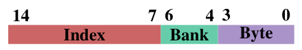

图6.6：AMD上L1d的存储体地址  
Figure 6.6: Bank Address of L1d on AMD  
Index=索引（位14–7），Bank=存储体（位6–4），Byte=字节（位3–0）。

如果执行了这项优化，另一项相关的优化也成为可能。至少AMD的处理器把L1d实现为若干个独立的存储体（bank）。L1d每个周期可以接收两个数据字，但前提是这两个字存储在不同的存储体中，或者存储在同一存储体中且索引相同。存储体地址编码在虚拟地址的低位中，如图6.6所示。如果一起使用的变量也被存放在一起，它们位于不同存储体中或位于同一存储体且索引相同的可能性就很高。

If this optimization is performed, another related optimization is possible, too. AMD’s processors, at least, implement the L1d as several individual banks. The L1d can receive two data words per cycle but only if both words are stored in different banks or in a bank with the same index. The bank address is encoded in the low bits of the virtual address as shown in Figure 6.6. If variables which are used together are also stored together the likelihood that they are in different banks or the same bank with the same index is high.

#### 6.2.2 优化一级指令缓存访问

#### 6.2.2 Optimizing Level 1 Instruction Cache Access

为良好地使用L1i而准备代码，需要与良好使用L1d类似的技术。不过，问题在于，除非用汇编语言编写代码，程序员通常无法直接影响L1i的使用方式。如果使用编译器，程序员可以通过引导编译器生成更好的代码布局来间接地决定L1i的使用。

Preparing code for good L1i use needs similar techniques as good L1d use. The problem is, though, that the programmer usually does not directly influence the way L1i is used unless s/he writes code in assembler. If compilers are used, programmers can indirectly determine the L1i use by guiding the compiler to create a better code layout.

代码的优点在于，在跳转之间它是线性的。在这些区间内，处理器可以高效地预取内存。跳转打乱了这幅美好的图景，因为

Code has the advantage that it is linear between jumps. In these periods the processor can prefetch memory efficiently. Jumps disturb this nice picture because

- 跳转目标可能无法静态确定；

  the jump target might not be statically determined;
- 而且即使它是静态的，如果所有缓存都未命中，取内存也可能需要很长时间。

  and even if it is static the memory fetch might take a long time if it misses all caches.

这些问题会造成执行停顿，可能对性能产生严重影响。这就是为什么如今的处理器在分支预测（BP）上投入巨大。高度专门化的BP单元试图在跳转之前尽可能早地确定跳转的目标，以便处理器可以开始把新位置的指令加载到缓存中。它们使用静态和动态规则，并且越来越擅长确定执行中的模式。

These problems create stalls in execution with a possibly severe impact on performance. This is why today’s processors invest heavily in branch prediction (BP). Highly specialized BP units try to determine the target of a jump as far ahead of the jump as possible so that the processor can initiate loading the instructions at the new location into the cache. They use static and dynamic rules and are increasingly good at determining patterns in execution.

对于指令缓存而言，尽早把数据放入缓存甚至更加重要。正如3.1节所述，指令在执行之前必须先被解码，为了加快这一过程（这在x86和x86-64上很重要），指令实际上是以解码后的形式被缓存的，而不是以从内存读取的字节/字形式。

Getting data into the cache as soon as possible is even more important for the instruction cache. As mentioned in section 3.1, instructions have to be decoded before they can be executed and, to speed this up (important on x86 and x86-64), instructions are actually cached in the decoded form, not in the byte/word form read from memory.

为了实现最佳的L1i使用，程序员至少应当注意代码生成的以下几个方面：

To achieve the best L1i use programmers should look out for at least the following aspects of code generation:

1. 尽可能减少代码占用。这必须与循环展开和内联等优化相平衡。

   reduce the code footprint as much as possible. This has to be balanced with optimizations like loop unrolling and inlining.
2. 代码执行应当是线性的，没有气泡。<sup>31</sup>

   code execution should be linear without bubbles.<sup>31</sup>
3. 在有意义的地方对齐代码。

   aligning code when it makes sense.

我们现在来看一些可用于帮助按照这些方面优化程序的编译器技术。

We will now look at some compiler techniques available to help with optimizing programs according to these aspects.

编译器有启用各级优化的选项；具体的优化也可以单独启用。在高优化级别（gcc的`-O2`和`-O3`）下启用的许多优化涉及循环优化和函数内联。一般来说，这些都是好的优化。如果以这些方式优化的代码占程序总执行时间的很大一部分，整体性能就能得到提高。特别是函数内联，它使编译器能够一次优化更大的代码块，这反过来又使得生成能更好地利用处理器流水线架构的机器码成为可能。当程序更大的部分可以被视为一个单元时，对代码和数据的处理（通过死代码消除或值范围传播等）效果更好。

Compilers have options to enable levels of optimization; specific optimizations can also be individually enabled. Many of the optimizations enabled at high optimization levels (`-O2` and `-O3` for gcc) deal with loop optimizations and function inlining. In general, these are good optimizations. If the code which is optimized in these ways accounts for a significant part of the total execution time of the program, overall performance can be improved. Inlining of functions, in particular, allows the compiler to optimize larger chunks of code at a time which, in turn, enables the generation of machine code which better exploits the processor’s pipeline architecture. The handling of both code and data (through dead code elimination or value range propagation, and others) works better when larger parts of the program can be considered as a single unit.

更大的代码尺寸意味着对L1i（以及L2和更高级别）缓存的更大压力。这可能导致性能下降。更小的代码可能更快。幸运的是，gcc有一个优化选项来指定这一点。如果使用`-Os`，编译器将针对代码尺寸进行优化。已知会增大代码尺寸的优化会被禁用。使用这个选项常常会产生令人惊讶的结果。特别是如果编译器无法真正利用循环展开和内联，这个选项会是一大胜利。

A larger code size means higher pressure on the L1i (and also L2 and higher level) caches. This can lead to less performance. Smaller code can be faster. Fortunately gcc has an optimization option to specify this. If `-Os` is used the compiler will optimize for code size. Optimizations which are known to increase the code size are disabled. Using this option often produces surprising results. Especially if the compiler cannot really take advantage of loop unrolling and inlining, this option is a big win.

内联也可以单独控制。编译器有指导内联的启发式规则和限制；这些限制可以由程序员控制。`-finline-limit`选项指定一个函数必须有多大才会被认为太大而不能内联。如果一个函数在多个地方被调用，在所有这些地方都内联它会导致代码尺寸暴增。但还不止于此。假设函数`inlcand`在两个函数`f1`和`f2`中被调用。函数`f1`和`f2`本身又是依次被调用的。

Inlining can be controlled individually as well. The compiler has heuristics and limits which guide inlining; these limits can be controlled by the programmer. The `-finline-limit` option specifies how large a function must be to be considered too large for inlining. If a function is called in multiple places, inlining it in all of them would cause an explosion in the code size. But there is more. Assume a function `inlcand` is called in two functions `f1` and `f2`. The functions `f1` and `f2` are themselves called in sequence.

内联  
With inlining

不内联  
Without inlining

```
start f1
  code f1
  inlined inlcand
  more code f1
end f1

start f2
  code f2
  inlined inlcand
  more code f2
end f2
```

```
start inlcand
  code inlcand
end inlcand

start f1
  code f1
end f1

start f2
  code f2
end f2
```

表6.3：内联与不内联  
Table 6.3: Inlining Vs Not

表6.3显示了在不内联以及在两个函数中都内联的情况下生成的代码可能的样子。如果函数`inlcand`在`f1`和`f2`中都被内联，生成代码的总大小为size `f1` + size `f2` + 2× size `inlcand`。如果没有发生内联，总大小要小size `inlcand`。如果`f1`和`f2`在短时间内先后被调用，这就是所需额外L1i和L2缓存的大小。再者：如果`inlcand`没有被内联，代码可能仍在L1i中，就不必再次解码。再者：分支预测单元可能会更好地预测跳转，因为它已经见过这段代码了。如果编译器对内联函数大小上限的默认值对程序来说不是最佳的，就应当降低它。

Table 6.3 shows how the generated code could look like in the cases of no inline and inlining in both functions. If the function `inlcand` is inlined in both `f1` and `f2` the total size of the generated code is size `f1` + size `f2` + 2× size `inlcand`. If no inlining happens, the total size is smaller by size `inlcand`. This is how much more L1i and L2 cache is needed if `f1` and `f2` are called shortly after one another. Plus: if `inlcand` is not inlined, the code might still be in L1i and it will not have to be decoded again. Plus: the branch prediction unit might do a better job of predicting jumps since it has already seen the code. If the compiler default for the upper limit on the size of inlined functions is not the best for the program, it should be lowered.

不过，也有一些情况下内联总是有意义的。如果一个函数只被调用一次，那就不妨把它内联。这给了编译器执行更多优化的机会（例如值范围传播，它可能会显著改进代码）。这种内联可能会被选择限制所阻碍。对于这类情况，gcc有一个选项来指定某个函数总是被内联。添加`always_inline`函数属性会指示编译器严格按照其名称所示去做。

There are cases, though, when inlining always makes sense. If a function is only called once it might as well be inlined. This gives the compiler the opportunity to perform more optimizations (like value range propagation, which might significantly improve the code). That inlining might be thwarted by the selection limits. gcc has, for cases like this, an option to specify that a function is always inlined. Adding the `always_inline` function attribute instructs the compiler to do exactly what the name suggests.

在同样的语境下，如果一个函数尽管足够小却永远不应被内联，可以使用`noinline`函数属性。即使对于小函数，如果它们经常从不同的地方被调用，使用这个属性也是有意义的。如果L1i的内容可以被重用并且整体占用减少了，这通常能弥补额外函数调用的代价。如今的分支预测单元相当出色。如果内联可以带来更激进的优化，情况就不同了。这是必须根据具体情况决定的事情。

In the same context, if a function should never be inlined despite being small enough, the `noinline` function attribute can be used. Using this attribute makes sense even for small functions if they are called often from different places. If the L1i content can be reused and the overall footprint is reduced this often makes up for the additional cost of the extra function call. Branch prediction units are pretty good these days. If inlining can lead to more aggressive optimizations things look different. This is something which must be decided on a case-by-case basis.

如果内联的代码总是被使用，`always_inline`属性效果很好。但如果情况并非如此呢？如果内联的函数只是偶尔被调用呢：

The `always_inline` attribute works well if the inline code is always used. But what if this is not the case? What if the inlined function is called only occasionally:

```c
void fct(void) {
  ... code block A ...
  if (condition)
    inlfct()
  ... code block C ...
}
```

为这样的代码序列生成的代码一般与源代码的结构相匹配。这意味着首先是代码块A，然后是一个条件跳转，如果条件求值为假，就向前跳转。接下来是为内联的`inlfct`生成的代码，最后是代码块C。这一切看起来都很合理，但它有一个问题。

The code generated for such a code sequence in general matches the structure of the sources. That means first comes the code block A, then a conditional jump which, if the condition evaluates to false, jumps forward. The code generated for the inlined `inlfct` comes next, and finally the code block C. This looks all reasonable but it has a problem.

如果`condition`经常为假，执行就不是线性的。中间有一大块未被使用的代码，它不仅因预取而污染L1i，还可能给分支预测带来问题。如果分支预测错误，条件表达式可能会非常低效。

If the `condition` is frequently false, the execution is not linear. There is a big chunk of unused code in the middle which not only pollutes the L1i due to prefetching, it also can cause problems with branch prediction. If the branch prediction is wrong the conditional expression can be very inefficient.

这是一个普遍的问题，并不特定于函数内联。每当使用条件执行并且它是不平衡的（即表达式导致某一结果的次数远多于另一结果）时，就有可能出现错误的静态分支预测，从而在流水线中产生气泡。这可以通过告诉编译器把较少执行的代码移出主代码路径来避免。在那种情况下，为`if`语句生成的条件分支将跳转到一个不按顺序的位置，如下图所示。

This is a general problem and not specific to inlining functions. Whenever conditional execution is used and it is lopsided (i.e., the expression far more often leads to one result than the other) there is the potential for false static branch prediction and thus bubbles in the pipeline. This can be prevented by telling the compiler to move the less often executed code out of the main code path. In that case the conditional branch generated for an `if` statement would jump to a place out of the order as can be seen in the following figure.

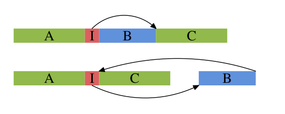

代码块重排：上为简单布局，下为重排后的布局  
Block reordering: simple layout (top) and reordered layout (bottom)

上半部分表示简单的代码布局。如果区域B（例如由上面内联的函数`inlfct`生成）因为条件I跳过它而经常不被执行，处理器的预取会拉入包含块B的缓存行，而这些缓存行很少被使用。使用块重排可以改变这一点，其结果可以在图的下半部分看到。经常执行的代码在内存中是线性的，而很少执行的代码被移到了某个不会损害预取和L1i效率的地方。

The upper parts represents the simple code layout. If the area B, e.g. generated from the inlined function `inlfct` above, is often not executed because the conditional I jumps over it, the prefetching of the processor will pull in cache lines containing block B which are rarely used. Using block reordering this can be changed, with a result that can be seen in the lower part of the figure. The often-executed code is linear in memory while the rarely-executed code is moved somewhere where it does not hurt prefetching and L1i efficiency.

gcc提供了两种方法来做到这一点。首先，编译器可以在重新编译代码时考虑剖析（profiling）输出，并根据剖析结果安排代码块。我们将在第7节中看到这是如何工作的。第二种方法是通过显式的分支预测。gcc识别`__builtin_expect`：

gcc provides two methods to achieve this. First, the compiler can take profiling output into account while recompiling code and lay out the code blocks according to the profile. We will see how this works in section 7. The second method is through explicit branch prediction. gcc recognizes `__builtin_expect`:

```c
long __builtin_expect(long EXP, long C);
```

这个构造告诉编译器，表达式`EXP`最有可能取值`C`。返回值是`EXP`。`__builtin_expect`旨在用于条件表达式中。在几乎所有情况下，它都将在布尔表达式的语境中使用，这时定义两个辅助宏要方便得多：

This construct tells the compiler that the expression `EXP` most likely will have the value `C`. The return value is `EXP`. `__builtin_expect` is meant to be used in an conditional expression. In almost all cases will it be used in the context of boolean expressions in which case it is much more convenient to define two helper macros:

```c
#define unlikely(expr) __builtin_expect(!!(expr), 0)
#define likely(expr) __builtin_expect(!!(expr), 1)
```

然后可以这样使用这些宏：

These macros can then be used as in

```c
if (likely(a > 1))
```

如果程序员使用了这些宏，然后使用`-freorder-blocks`优化选项，gcc就会像上图那样重排代码块。这个选项在`-O2`下启用，但在`-Os`下禁用。还有另一个重排代码块的gcc选项（`-freorder-blocks-and-partition`），但它的用处有限，因为它不能与异常处理一起工作。

If the programmer makes use of these macros and then uses the `-freorder-blocks` optimization option gcc will reorder blocks as in the figure above. This option is enabled with `-O2` but disabled for `-Os`. There is another gcc option to reorder block (`-freorder-blocks-and-partition`) but it has limited usefulness because it does not work with exception handling.

小循环还有另一个很大的优点，至少在某些处理器上是这样。Intel Core 2前端有一个称为循环流检测器（LSD）的特殊功能。如果一个循环不超过18条指令（其中没有一条是对子程序的调用），只需要最多4次16字节的解码器取指，最多有4条分支指令，并且执行超过64次，那么该循环有时会被锁定在指令队列中，因而在再次使用该循环时能更快地获得。例如，这适用于通过外层循环多次进入的小型内层循环。即使没有这种专门的硬件，紧凑的循环也有其优点。

There is another big advantage of small loops, at least on certain processors. The Intel Core 2 front end has a special feature called Loop Stream Detector (LSD). If a loop has no more than 18 instructions (none of which is a call to a subroutine), requires only up to 4 decoder fetches of 16 bytes, has at most 4 branch instructions, and is executed more than 64 times, than the loop is sometimes locked in the instruction queue and therefore more quickly available when the loop is used again. This applies, for instance, to small inner loops which are entered many times through an outer loop. Even without such specialized hardware compact loops have advantages.

内联并不是关于L1i优化的唯一方面。另一个方面是对齐，就像对于数据一样。有一些明显的区别：代码是一个大体上线性的整块，不能在地址空间中任意放置，而且由于代码由编译器生成，程序员无法直接影响它。不过，还是有一些方面是程序员可以控制的。

Inlining is not the only aspect of optimization with respect to L1i. Another aspect is alignment, just as for data. There are obvious differences: code is a mostly linear blob which cannot be placed arbitrarily in the address space and it cannot be influenced directly by the programmer as the compiler generates the code. There are some aspects which the programmer can control, though.

对齐每一条指令是没有意义的。目标是让指令流是顺序的。所以对齐只在策略性的位置才有意义。为了决定在哪里添加对齐，有必要理解它可能带来的好处。让一条指令位于缓存行的开头<sup>32</sup>意味着对该缓存行的预取最大化了。对于指令，这也意味着解码器更有效。很容易看出，如果执行的是位于缓存行末尾的一条指令，处理器就必须准备读取一个新的缓存行并对指令解码。有些事情可能会出错（例如缓存行未命中），这意味着位于缓存行末尾的指令平均而言不如位于开头的指令执行得那么有效。

Aligning each single instruction does not make any sense. The goal is to have the instruction stream be sequential. So alignment only makes sense in strategic places. To decide where to add alignments it is necessary to understand what the advantages can be. Having an instruction at the beginning of a cache line<sup>32</sup> means that the prefetch of the cache line is maximized. For instructions this also means the decoder is more effective. It is easy to see that, if an instruction at the end of a cache line is executed, the processor has to get ready to read a new cache line and decode the instructions. There are things which can go wrong (such as cache line misses), meaning that an instruction at the end of the cache line is, on average, not as effectively executed as one at the beginning.

再结合后续的推论——如果控制刚刚转移到所讨论的指令（因而预取无效），问题最为严重——我们就得出了关于代码对齐在何处最有用的最终结论：

Combine this with the follow-up deduction that the problem is most severe if control was just transferred to the instruction in question (and hence prefetching is not effective) and we arrive at our final conclusion where alignment of code is most useful:

- 在函数的开头；

  at the beginning of functions;
- 在只能通过跳转到达的基本块的开头；

  at the beginning of basic blocks which are reached only through jumps;
- 在某种程度上，在循环的开头。

  to some extent, at the beginning of loops.

在前两种情况下，对齐的代价很小。执行在一个新的位置继续，如果我们选择让它位于缓存行的开头，就优化了预取和解码。<sup>33</sup>编译器通过插入一系列空操作指令来填补对齐代码所产生的空隙，从而实现这种对齐。这种“死代码”占用一点空间，但通常不会损害性能。

In the first two cases the alignment comes at little cost. Execution proceeds at a new location and, if we choose it to be at the beginning of a cache line, we optimize prefetching and decoding.<sup>33</sup> The compiler accomplishes this alignment through the insertion of a series of no-op instructions to fill the gap created by aligning the code. This “dead code” takes a little space but does not normally hurt performance.

第三种情况略有不同：对齐每个循环的开头可能会造成性能问题。问题在于循环的开头往往是顺序地跟在其他代码之后的。如果情况不太走运，前一条指令与对齐后的循环开头之间就会有一个空隙。与前两种情况不同，这个空隙不可能完全是死的。在执行完前一条指令之后，必须执行循环中的第一条指令。这意味着，在前一条指令之后，要么必须有若干条空操作指令来填补空隙，要么必须有一条无条件跳转到循环开头。两种可能都不是免费的。尤其是如果循环本身执行得不频繁，空操作或跳转的代价可能超过对齐循环所节省的。

The third case is slightly different: aligning the beginning of each loop might create performance problems. The problem is that beginning of a loop often follows other code sequentially. If the circumstances are not very lucky there will be a gap between the previous instruction and the aligned beginning of the loop. Unlike in the previous two cases, this gap cannot be completely dead. After execution of the previous instruction the first instruction in the loop must be executed. This means that, following the previous instruction, there either must be a number of no-op instructions to fill the gap or there must be an unconditional jump to the beginning of the loop. Neither possibility is free. Especially if the loop itself is not executed often, the no-ops or the jump might cost more than one saves by aligning the loop.

程序员可以通过三种方式影响代码的对齐。显然，如果代码是用汇编编写的，函数及其中所有指令都可以被显式地对齐。汇编器为所有架构都提供了`.align`伪操作来做到这一点。对于高级语言，必须把对齐要求告诉编译器。与数据类型和变量不同，这在源代码中是不可能的。取而代之的是使用一个编译器选项：

There are three ways the programmer can influence the alignment of code. Obviously, if the code is written in assembler the function and all instructions in it can be explicitly aligned. The assembler provides for all architectures the `.align` pseudo-op to do that. For high-level languages the compiler must be told about alignment requirements. Unlike for data types and variables this is not possible in the source code. Instead a compiler option is used:

```
-falign-functions=N
```

这个选项指示编译器把所有函数对齐到大于N的下一个2的幂次边界。这意味着会产生最多N字节的空隙。对于小函数，使用较大的N值是一种浪费。对于很少执行的代码也是如此。后者在库中可能经常出现，库中可能同时包含常用的和不那么常用的接口。明智地选择选项值可以加快速度，或者通过避免对齐来节省内存。使用1作为N的值或使用`-fno-align-functions`选项可以关闭所有对齐。

This option instructs the compiler to align all functions to the next power-of-two boundary greater than N. That means a gap of up to N bytes is created. For small functions using a large value for N is a waste. Equally for code which is executed only rarely. The latter can happen a lot in libraries which can contain both popular and not-so-popular interfaces. A wise choice of the option value can speed things up or save memory by avoiding alignment. All alignment is turned off by using one as the value of N or by using the `-fno-align-functions` option.

上述第二种情况——不按顺序到达的基本块的开头——的对齐可以用另一个选项来控制：

The alignment for the second case above–beginning of basic blocks which are not reached sequentially–can be controlled with a different option:

```
-falign-jumps=N
```

所有其他细节都是相同的，关于浪费内存的同样警告也适用。

All the other details are equivalent, the same warning about waste of memory applies.

第三种情况也有它自己的选项：

The third case also has its own option:

```
-falign-loops=N
```

同样的细节和警告再次适用。只是在这里，正如前面所解释的，对齐会带来运行时代价，因为如果顺序到达对齐后的地址，就必须执行空操作或跳转指令。

Yet again, the same details and warnings apply. Except that here, as explained before, alignment comes at a runtime cost since either no-ops or a jump instruction has to be executed if the aligned address is reached sequentially.

gcc还知道另一个控制对齐的选项，这里提到它只是为了完整起见。`-falign-labels`对齐代码中的每一个标签（基本上就是每个基本块的开头）。除了少数例外情况外，这在所有情况下都会使代码变慢，因此不应使用。

gcc knows about one more option for controlling alignment which is mentioned here only for completeness. `-falign-labels` aligns every single label in the code (basically the beginning of each basic block). This, in all but a few exceptional cases, slows down the code and therefore should not be used.